# 🛒 E-Commerce Business Intelligence & SQL Analytics — Exploratory Data Analysis

**Project:** E-Commerce Business Intelligence & SQL Analytics  
**Dataset:** Olist Brazilian E-Commerce (Kaggle — `olistbr/brazilian-ecommerce`) · ~100k orders · 8 relational tables (+ 1 category-translation lookup) · Sept 2016 – Oct 2018  
**Domain:** E-Commerce / Business Analytics  
**Problem type:** SQL analytics + KPI dashboard + business insights  
**Author:** Narendra Kalam

## 🏢 Business Context

Analysts at Flipkart, Amazon India and Meesho live in SQL-based BI. Every week they answer the same family of questions: *How much revenue did we make and where is it coming from? Which sellers are helping or hurting us? Are we delivering on our promise? Are customers coming back?* This notebook reproduces that workflow end-to-end on Olist — a real Brazilian marketplace that connects small sellers to customers through a single logistics and payment layer, which makes it structurally identical to an Indian marketplace.

**Approach:** the 9 CSVs are loaded into a **SQL warehouse (SQLite)** and every business metric is computed with **SQL** (CTEs, window functions, joins, cohort logic). Python is used only for statistics and visualisation — the same division of labour used on a real analytics team.

## 🎯 Business Questions This EDA Answers

| # | Business Question | KPI Family |
| --- | --- | --- |
| 1 | How big is the business and how fast is it growing? | GMV, orders, AOV, MoM / YoY growth |
| 2 | Which categories, states and payment methods drive revenue? | Pareto share, geographic mix, payment mix |
| 3 | Are we keeping the delivery promise — and what does it cost us? | On-time %, delivery days, delay vs CSAT |
| 4 | Which sellers create the revenue — and which ones put it at risk? | Seller concentration, seller scorecard |
| 5 | Do customers come back? What is a customer worth? | Repeat rate, cohort retention, RFM, CLV |

## 📌 Notebook Workflow

| Step | Topic | Step | Topic |
| --- | --- | --- | --- |
| 1 | Import libraries | 16 | Geographic demand vs supply |
| 2 | Data loading and schema inventory | 17 | Delivery SLA performance |
| 3 | Build SQL analytics warehouse | 18 | Order lifecycle decomposition |
| 4 | Data types and timestamp audit | 19 | Delivery delay vs review score (+ stats) |
| 5 | Missing values analysis | 20 | Review score and CSAT trend |
| 6 | Data-quality scorecard (keys, orphans, duplicates) | 21 | Seller concentration (Lorenz / Gini) |
| 7 | Order status and fulfilment funnel | 22 | Seller quality quadrant |
| 8 | Analytical master view (grain control) | 23 | Customer purchase behaviour |
| 9 | Executive KPI dashboard | 24 | Cohort retention analysis |
| 10 | Monthly revenue trend and MoM growth | 25 | RFM segmentation and CLV |
| 11 | Purchase seasonality (day × hour) | 26 | Correlation analysis |
| 12 | Category revenue Pareto | 27 | SQL window-function patterns (YoY, Top-N) |
| 13 | Category quality matrix | 28 | Export analytics marts |
| 14 | Price and freight distributions | 29 | Key insights and decision map |
| 15 | Payment behaviour |  |  |

## 🧱 Tech Stack

`SQLite` (SQL engine) · `pandas` (I/O + light wrangling) · `matplotlib / seaborn` (visuals) · `scipy` (hypothesis tests)

> **How to run:** download the dataset from Kaggle, set `DATA_DIR` in Step 2, then **Run All**. Nothing else needs to be changed.

## Step 1 — Import Libraries

**Why:** All dependencies are imported up-front so the notebook fails fast if the environment is incomplete. `sqlite3` provides the SQL engine (ships with Python — zero setup), and `scipy.stats` lets us back visual patterns with hypothesis tests instead of eyeballing.

**Business insight:** A BI notebook must be reproducible by any teammate on any laptop. Choosing an embedded SQL engine (no server, no credentials) means the same queries can later be ported to BigQuery / Redshift / Snowflake with minimal syntax changes.

```python
import time
import warnings
import sqlite3
from pathlib import Path

import numpy as np
import pandas as pd
import matplotlib.pyplot as plt
import matplotlib.dates as mdates
import matplotlib.ticker as mticker
from matplotlib.patches import FancyBboxPatch
import seaborn as sns
from scipy import stats
from scipy.stats import mannwhitneyu, spearmanr

warnings.filterwarnings("ignore")
pd.set_option("display.max_columns", 60)
pd.set_option("display.width", 200)
pd.set_option("display.float_format", lambda x: f"{x:,.2f}")

# ── Plot style ────────────────────────────────────────────────
sns.set_theme(style="whitegrid", palette="muted")
plt.rcParams.update({
    "figure.dpi": 110, "figure.figsize": (12, 5),
    "axes.titlesize": 12.5, "axes.titleweight": "bold", "axes.labelsize": 10.5,
    "axes.spines.top": False, "axes.spines.right": False,
})

BLUE   = "#2563EB"   # primary / neutral
GREEN  = "#10B981"   # good / on-time / healthy
ORANGE = "#F59E0B"   # warning / watch
RED    = "#EF4444"   # bad / late / risk
PURPLE = "#8B5CF6"   # accent
GRAY   = "#94A3B8"   # muted

print("✅ Libraries loaded successfully")
print(f"   pandas  : {pd.__version__}")
print(f"   numpy   : {np.__version__}")
print(f"   SQLite  : {sqlite3.sqlite_version}  (window functions need >= 3.25)")
```

```
✅ Libraries loaded successfully
   pandas  : 2.1.4
   numpy   : 1.26.4
   SQLite  : 3.53.4  (window functions need >= 3.25)
```

**📌 Observation:** The environment loaded pandas 2.1.4, numpy 1.26.4 and SQLite 3.53.4. The SQLite version is far above the 3.25 minimum needed for window functions, so `LAG`, `NTILE`, `ROW_NUMBER` and running `SUM() OVER` are all safe to use in every later step (and the notebook did run them without a single failure).

**💡 Pipeline / Engineering decision:** SQL is the primary engine for the whole notebook: every aggregation is written as a query and pandas is used only for statistics and plotting. One colour language is fixed for all charts — **green = healthy, orange = watch, red = risk, blue = neutral** — and it is reused in the KPI cards (Step 9) and seller / category flags (Steps 13, 22) so the same colour always carries the same business meaning.

## Step 2 — Data Loading and Schema Inventory

**Why:** Before writing a single query we need to know the **grain** (what one row represents) of every table. Wrong grain assumptions are the #1 cause of wrong revenue numbers in SQL — a schema map prevents that.

**Business insight:** Olist is a relational star-like schema. `orders` is the spine; `order_items` holds product value and freight (revenue), `order_payments` holds what customers actually paid, `order_reviews` holds CSAT, and `customers` / `sellers` / `products` are dimensions. A `geolocation` table and a PT→EN `category_translation` lookup complete the set.

```
Loaded 9 tables | total rows = 1,550,922 | memory = 358 MB
```

|  | table | rows | columns | memory_mb | grain |
| --- | --- | --- | --- | --- | --- |
| 0 | customers | 99441 | 5 | 31.06 | 1 row per customer_id (NOT per person - id is... |
| 1 | geolocation | 1000163 | 5 | 152.26 | many lat/lng points per zip-code prefix |
| 2 | order_items | 112650 | 7 | 41.34 | 1 row per item inside an order |
| 3 | order_payments | 103886 | 5 | 18.68 | 1 row per payment instrument used on an order |
| 4 | order_reviews | 99224 | 7 | 44.82 | 1 row per review (an order can have > 1) |
| 5 | orders | 99441 | 8 | 61.83 | 1 row per order (fact-table spine) |
| 6 | products | 32951 | 9 | 7.12 | 1 row per product |
| 7 | sellers | 3095 | 4 | 0.69 | 1 row per seller |
| 8 | category_translation | 71 | 2 | 0.01 | Portuguese -> English category lookup |

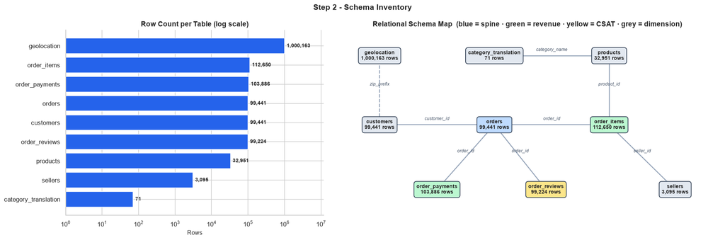

```python
# ── Update this path to where you extracted the Kaggle dataset ──────────
DATA_DIR   = Path(r"D:\Data Science Datasets\Olist Brazilian E-Commerce")
OUTPUT_DIR = Path("olist_outputs");  OUTPUT_DIR.mkdir(exist_ok=True)

FILES = {
    "customers":            "olist_customers_dataset.csv",
    "geolocation":          "olist_geolocation_dataset.csv",
    "order_items":          "olist_order_items_dataset.csv",
    "order_payments":       "olist_order_payments_dataset.csv",
    "order_reviews":        "olist_order_reviews_dataset.csv",
    "orders":               "olist_orders_dataset.csv",
    "products":             "olist_products_dataset.csv",
    "sellers":              "olist_sellers_dataset.csv",
    "category_translation": "product_category_name_translation.csv",
}
GRAIN = {
    "customers":            "1 row per customer_id  (NOT per person - id is re-issued per order)",
    "geolocation":          "many lat/lng points per zip-code prefix",
    "order_items":          "1 row per item inside an order",
    "order_payments":       "1 row per payment instrument used on an order",
    "order_reviews":        "1 row per review (an order can have > 1)",
    "orders":               "1 row per order  (fact-table spine)",
    "products":             "1 row per product",
    "sellers":              "1 row per seller",
    "category_translation": "Portuguese -> English category lookup",
}

tables = {name: pd.read_csv(DATA_DIR / fname) for name, fname in FILES.items()}

inventory = pd.DataFrame({
    "table":     list(tables),
    "rows":      [len(t) for t in tables.values()],
    "columns":   [t.shape[1] for t in tables.values()],
    "memory_mb": [t.memory_usage(deep=True).sum() / 1e6 for t in tables.values()],
    "grain":     [GRAIN[n] for n in tables],
})
print(f"Loaded {len(tables)} tables | total rows = {inventory.rows.sum():,} | memory = {inventory.memory_mb.sum():.0f} MB")
display(inventory)

# ── Visual: row counts + relational schema map ───────────────────────────
fig, axes = plt.subplots(1, 2, figsize=(18, 6), gridspec_kw={"width_ratios": [1, 1.5]})

inv = inventory.sort_values("rows")
axes[0].barh(inv["table"], inv["rows"], color=BLUE, edgecolor="white")
axes[0].set_xscale("log")
for y, v in enumerate(inv["rows"]):
    axes[0].text(v * 1.15, y, f"{v:,}", va="center", fontsize=9, fontweight="bold")
axes[0].set_xlim(1, inv["rows"].max() * 12)
axes[0].set_title("Row Count per Table (log scale)")
axes[0].set_xlabel("Rows")

pos = {"customers": (1.6, 5), "orders": (5.6, 5), "order_items": (9.6, 5), "products": (9.6, 8.2),
       "category_translation": (5.6, 8.2), "geolocation": (1.6, 8.2), "sellers": (11.9, 2.0),
       "order_payments": (3.6, 2.0), "order_reviews": (7.4, 2.0)}
links = [("customers", "orders", "customer_id"), ("orders", "order_items", "order_id"),
         ("orders", "order_payments", "order_id"), ("orders", "order_reviews", "order_id"),
         ("order_items", "products", "product_id"), ("order_items", "sellers", "seller_id"),
         ("products", "category_translation", "category_name"), ("geolocation", "customers", "zip_prefix")]
ax = axes[1]
for a, b, lab in links:
    (x1, y1), (x2, y2) = pos[a], pos[b]
    ax.plot([x1, x2], [y1, y2], color=GRAY, lw=1.6, ls="--" if a == "geolocation" else "-", zorder=1)
    ax.text((x1 + x2) / 2, (y1 + y2) / 2 + 0.22, lab, fontsize=8, color="#475569", ha="center", style="italic")
rows_map = dict(zip(inventory["table"], inventory["rows"]))
for name, (x, y) in pos.items():
    color = {"orders": "#BFDBFE", "order_items": "#BBF7D0", "order_payments": "#BBF7D0", "order_reviews": "#FDE68A"}.get(name, "#E2E8F0")
    ax.text(x, y, f"{name}\n{rows_map[name]:,} rows", ha="center", va="center", fontsize=9, fontweight="bold",
            bbox=dict(boxstyle="round,pad=0.5", fc=color, ec="#334155", lw=1.2), zorder=3)
ax.set_xlim(0, 13.5); ax.set_ylim(0.8, 9.4); ax.axis("off")
ax.set_title("Relational Schema Map  (blue = spine · green = revenue · yellow = CSAT · grey = dimension)")

plt.suptitle("Step 2 - Schema Inventory", fontsize=14, fontweight="bold")
plt.tight_layout(); plt.show()
```

**📌 Observation:** The dataset holds **1,550,922 rows**, but **1,000,163 (64 %) of them are in `geolocation`** (many lat/lng points per zip prefix). Every business-critical table is about 100 k rows: `orders` and `customers` 99,441, `order_reviews` 99,224, `order_payments` 103,886 and `order_items` 112,650. In the log-scale bar chart `geolocation` is the only table near 10⁶, while `sellers` (3,095) and `category_translation` (71) are tiny dimensions. The schema map shows `orders` at the centre: `customers`, `order_items`, `order_payments` and `order_reviews` all join to it, and only `order_items` reaches `products` and `sellers`. The dashed `geolocation` link (zip prefix) is the only non-key, many-to-many relationship in the schema.

**💡 Pipeline / Engineering decision:** `orders` is the **spine** of the warehouse and every metric is anchored to it. `geolocation` is **not joined at row level** (a zip-prefix join to 1 M rows would multiply order rows); it is kept out of the revenue layer and reserved for a de-duplicated zip lookup. `order_items` (112,650 rows vs 99,441 orders) and `order_payments` (103,886) are already larger than the order table, which is why Step 8 pre-aggregates them before joining. Paths are parameterised (`DATA_DIR`, `OUTPUT_DIR`) so the notebook runs unchanged on any machine.

## Step 3 — Build the SQL Analytics Warehouse

**Why:** The project is *SQL analytics*, so every table is loaded into a real SQL engine and indexed on its join keys. Doing this once up-front turns the rest of the notebook into pure SQL, exactly like querying a warehouse. We also **benchmark an indexed vs un-indexed lookup** — a fast way to justify indexing decisions with evidence rather than habit.

**Business insight:** Slow dashboards lose stakeholder trust. On production warehouses (Redshift, BigQuery, Snowflake) the equivalent of an index is a sort key / cluster key / partition — the mental model of "index the join keys" transfers directly.

```
Query plan WITHOUT index : SCAN order_items
Query plan WITH index    : SEARCH order_items USING INDEX ix_items_order (order_id=?)
Latency without index    :   26.290 ms / query
Latency with index       :    0.112 ms / query   (236x faster)
```

|  | table | pandas_rows | sql_rows | match |
| --- | --- | --- | --- | --- |
| 0 | customers | 99441 | 99441 | True |
| 1 | geolocation | 1000163 | 1000163 | True |
| 2 | order_items | 112650 | 112650 | True |
| 3 | order_payments | 103886 | 103886 | True |
| 4 | order_reviews | 99224 | 99224 | True |
| 5 | orders | 99441 | 99441 | True |
| 6 | products | 32951 | 32951 | True |
| 7 | sellers | 3095 | 3095 | True |
| 8 | category_translation | 71 | 71 | True |

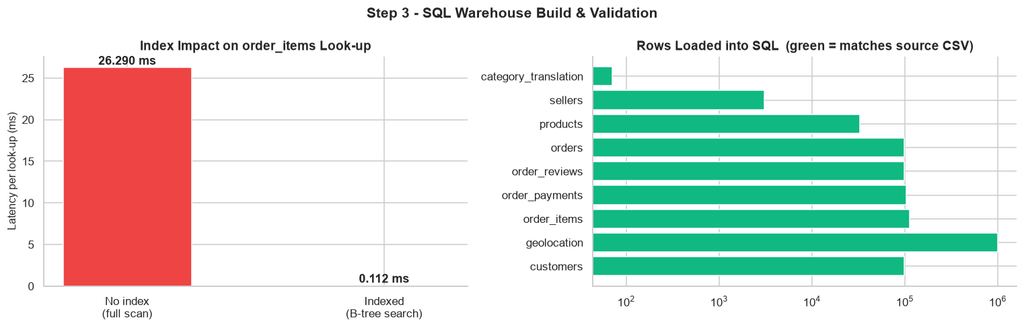

```python
DB_PATH = OUTPUT_DIR / "olist_analytics.db"
if DB_PATH.exists():
    DB_PATH.unlink()
conn = sqlite3.connect(DB_PATH)

for name, d in tables.items():
    d.to_sql(name, conn, index=False, if_exists="replace", chunksize=50_000)

def q(sql, params=None):
    """Run a SQL query and return a DataFrame - the single access point to the warehouse."""
    return pd.read_sql_query(sql, conn, params=params)

INDEXES = [
    "CREATE INDEX IF NOT EXISTS ix_orders_order    ON orders(order_id)",
    "CREATE INDEX IF NOT EXISTS ix_orders_cust     ON orders(customer_id)",
    "CREATE INDEX IF NOT EXISTS ix_cust_id         ON customers(customer_id)",
    "CREATE INDEX IF NOT EXISTS ix_cust_unique     ON customers(customer_unique_id)",
    "CREATE INDEX IF NOT EXISTS ix_items_order     ON order_items(order_id)",
    "CREATE INDEX IF NOT EXISTS ix_items_product   ON order_items(product_id)",
    "CREATE INDEX IF NOT EXISTS ix_items_seller    ON order_items(seller_id)",
    "CREATE INDEX IF NOT EXISTS ix_pay_order       ON order_payments(order_id)",
    "CREATE INDEX IF NOT EXISTS ix_rev_order       ON order_reviews(order_id)",
    "CREATE INDEX IF NOT EXISTS ix_prod_id         ON products(product_id)",
    "CREATE INDEX IF NOT EXISTS ix_sell_id         ON sellers(seller_id)",
    "CREATE INDEX IF NOT EXISTS ix_trans_cat       ON category_translation(product_category_name)",
]

# ── Benchmark: 200 random order look-ups on order_items, with vs without index ──
probe_ids = tables["orders"]["order_id"].sample(200, random_state=42).tolist()
def bench():
    t0 = time.perf_counter()
    for oid in probe_ids:
        conn.execute("SELECT COUNT(*) FROM order_items WHERE order_id = ?", (oid,)).fetchone()
    return (time.perf_counter() - t0) / len(probe_ids) * 1000   # ms / query

conn.execute("DROP INDEX IF EXISTS ix_items_order")
plan_before = q("EXPLAIN QUERY PLAN SELECT * FROM order_items WHERE order_id = 'x'")["detail"].iloc[0]
ms_before = bench()

for stmt in INDEXES:
    conn.execute(stmt)
conn.commit()
plan_after = q("EXPLAIN QUERY PLAN SELECT * FROM order_items WHERE order_id = 'x'")["detail"].iloc[0]
ms_after = bench()

print(f"Query plan WITHOUT index : {plan_before}")
print(f"Query plan WITH index    : {plan_after}")
print(f"Latency without index    : {ms_before:8.3f} ms / query")
print(f"Latency with index       : {ms_after:8.3f} ms / query   ({ms_before / max(ms_after, 1e-9):,.0f}x faster)")

# ── Integrity check: nothing lost between pandas and SQL ────────────────
load_check = pd.DataFrame({
    "table":       list(tables),
    "pandas_rows": [len(t) for t in tables.values()],
    "sql_rows":    [conn.execute(f"SELECT COUNT(*) FROM {t}").fetchone()[0] for t in tables],
})
load_check["match"] = load_check.pandas_rows == load_check.sql_rows
display(load_check)

fig, axes = plt.subplots(1, 2, figsize=(14, 4.5))
axes[0].bar(["No index\n(full scan)", "Indexed\n(B-tree search)"], [ms_before, ms_after], color=[RED, GREEN], edgecolor="white", width=0.5)
for i, v in enumerate([ms_before, ms_after]):
    axes[0].text(i, v, f"{v:.3f} ms", ha="center", va="bottom", fontweight="bold")
axes[0].set_ylabel("Latency per look-up (ms)"); axes[0].set_title("Index Impact on order_items Look-up")
axes[1].barh(load_check["table"], load_check["sql_rows"], color=[GREEN if m else RED for m in load_check["match"]], edgecolor="white")
axes[1].set_xscale("log"); axes[1].set_title("Rows Loaded into SQL  (green = matches source CSV)")
plt.suptitle("Step 3 - SQL Warehouse Build & Validation", fontsize=14, fontweight="bold")
plt.tight_layout(); plt.show()
```

## Step 4 — Data Types and Timestamp Audit

**Why:** Dates are the backbone of BI (trend, seasonality, SLA, cohorts). CSVs carry them as plain text, so we must confirm every timestamp parses cleanly and learn the **valid time window** of the data before any time-based analysis.

**Business insight:** Partial months at the start / end of a dataset look like "growth" or "collapse" on a trend chart but are just incomplete data. Identifying the true observation window prevents a wrong headline in an executive report.

|  | table | column | dtype | nulls | unparseable | min | max |
| --- | --- | --- | --- | --- | --- | --- | --- |
| 0 | orders | order_purchase_timestamp | object | 0 | 0 | 2016-09-04 21:15:19 | 2018-10-17 17:30:18 |
| 1 | orders | order_approved_at | object | 160 | 0 | 2016-09-15 12:16:38 | 2018-09-03 17:40:06 |
| 2 | orders | order_delivered_carrier_date | object | 1783 | 0 | 2016-10-08 10:34:01 | 2018-09-11 19:48:28 |
| 3 | orders | order_delivered_customer_date | object | 2965 | 0 | 2016-10-11 13:46:32 | 2018-10-17 13:22:46 |
| 4 | orders | order_estimated_delivery_date | object | 0 | 0 | 2016-09-30 00:00:00 | 2018-11-12 00:00:00 |
| 5 | order_items | shipping_limit_date | object | 0 | 0 | 2016-09-19 00:15:34 | 2020-04-09 22:35:08 |
| 6 | order_reviews | review_creation_date | object | 0 | 0 | 2016-10-02 00:00:00 | 2018-08-31 00:00:00 |
| 7 | order_reviews | review_answer_timestamp | object | 0 | 0 | 2016-10-07 18:32:28 | 2018-10-29 12:27:35 |

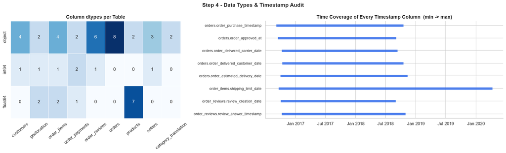

```
ID columns are 32-char hash strings; zip prefixes are integers (leading zeros are dropped, but consistently across tables).
```

```python
TS_COLS = {
    "orders": ["order_purchase_timestamp", "order_approved_at", "order_delivered_carrier_date",
               "order_delivered_customer_date", "order_estimated_delivery_date"],
    "order_items":   ["shipping_limit_date"],
    "order_reviews": ["review_creation_date", "review_answer_timestamp"],
}

audit = []
for t, cols in TS_COLS.items():
    for c in cols:
        s = tables[t][c]
        parsed = pd.to_datetime(s, errors="coerce")
        audit.append({"table": t, "column": c, "dtype": str(s.dtype), "nulls": int(s.isna().sum()),
                      "unparseable": int((parsed.isna() & s.notna()).sum()),
                      "min": parsed.min(), "max": parsed.max()})
audit_df = pd.DataFrame(audit)
display(audit_df)

dtype_summary = pd.concat({t: d.dtypes.astype(str).value_counts() for t, d in tables.items()}, axis=1).fillna(0).astype(int)

fig, axes = plt.subplots(1, 2, figsize=(18, 5.5), gridspec_kw={"width_ratios": [1, 1.4]})
sns.heatmap(dtype_summary, annot=True, fmt="d", cmap="Blues", cbar=False, linewidths=0.5, ax=axes[0])
axes[0].set_title("Column dtypes per Table"); axes[0].set_xlabel(""); axes[0].tick_params(axis="x", rotation=40)

lab = audit_df["table"] + "." + audit_df["column"]
ypos = np.arange(len(audit_df))[::-1]
axes[1].hlines(ypos, mdates.date2num(audit_df["min"]), mdates.date2num(audit_df["max"]), color=BLUE, lw=6, alpha=0.8)
axes[1].set_yticks(ypos); axes[1].set_yticklabels(lab, fontsize=9)
axes[1].xaxis_date(); axes[1].xaxis.set_major_formatter(mdates.DateFormatter("%b %Y"))
axes[1].set_title("Time Coverage of Every Timestamp Column  (min -> max)")
plt.suptitle("Step 4 - Data Types & Timestamp Audit", fontsize=14, fontweight="bold")
plt.tight_layout(); plt.show()

print("ID columns are 32-char hash strings; zip prefixes are integers (leading zeros are dropped, but consistently across tables).")
```

**📌 Observation:** All 8 timestamp columns are stored as text (`object`) but **0 values are unparseable**. The heatmap shows most columns are `object` (orders alone has 8) with a few `float64` product measurements. The coverage bars show purchases starting **2016-09-04** and ending **2018-10-17**, and delivery / estimate dates running to Nov 2018. The clear outlier is `order_items.shipping_limit_date`, whose bar stretches to **2020-04-09** — well past every other column, so it holds implausible future dates. A min→max bar cannot show *density*, but the monthly table in Step 10 does: 2017-01 has only 787 orders (against ~6-7 k per month in 2018), and the 2016 months and the last weeks of 2018 are similarly thin.

**💡 Pipeline / Engineering decision:** Timestamps stay as **ISO-8601 text inside SQLite** (`YYYY-MM-DD HH:MM:SS`), which sorts correctly and works with `STRFTIME()` / `JULIANDAY()`; they are parsed to `datetime` only after results return to pandas. The analysis window is fixed to **`WINDOW_START = 2017-01` → `WINDOW_END = 2018-08`** and injected into SQL as bound parameters, so sparse 2016 months and the partial tail never distort growth or cohort maths. `shipping_limit_date` is **excluded from all time-based features** because of its 2020 values.

## Step 5 — Missing Values Analysis

**Why:** Not every null is a data error. In an order lifecycle, a cancelled order *should* have no delivery date. Separating **structural nulls** (meaningful) from **defect nulls** (bugs) decides whether we impute, drop, or leave alone.

**Business insight:** If "missing delivery date" were treated as a defect and imputed, we would fabricate deliveries for cancelled orders and inflate the on-time rate. Understanding *why* a value is missing protects the integrity of the SLA KPI.

|  | table | column | missing | pct |
| --- | --- | --- | --- | --- |
| 0 | order_reviews | review_comment_title | 87656 | 88.34 |
| 1 | order_reviews | review_comment_message | 58247 | 58.70 |
| 2 | orders | order_delivered_customer_date | 2965 | 2.98 |
| 3 | products | product_category_name | 610 | 1.85 |
| 4 | products | product_name_lenght | 610 | 1.85 |
| 5 | products | product_description_lenght | 610 | 1.85 |
| 6 | products | product_photos_qty | 610 | 1.85 |
| 7 | orders | order_delivered_carrier_date | 1783 | 1.79 |
| 8 | orders | order_approved_at | 160 | 0.16 |
| 9 | products | product_weight_g | 2 | 0.01 |
| 10 | products | product_length_cm | 2 | 0.01 |
| 11 | products | product_height_cm | 2 | 0.01 |
| 12 | products | product_width_cm | 2 | 0.01 |

| order_status | orders | approved_null_pct | carrier_null_pct | delivered_null_pct |
| --- | --- | --- | --- | --- |
| delivered | 96478 | 0.01 | 0.00 | 0.01 |
| shipped | 1107 | 0.00 | 0.00 | 100.00 |
| canceled | 625 | 22.56 | 88.00 | 99.04 |
| unavailable | 609 | 0.00 | 100.00 | 100.00 |
| invoiced | 314 | 0.00 | 100.00 | 100.00 |
| processing | 301 | 0.00 | 100.00 | 100.00 |
| created | 5 | 100.00 | 100.00 | 100.00 |
| approved | 2 | 0.00 | 100.00 | 100.00 |

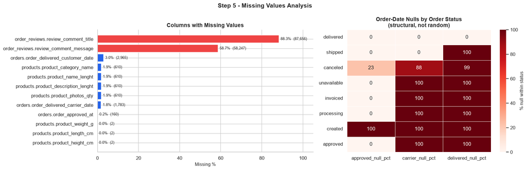

```python
miss_rows = []
for t, d in tables.items():
    m = d.isna().sum()
    for c, v in m[m > 0].items():
        miss_rows.append({"table": t, "column": c, "missing": int(v), "pct": v / len(d) * 100})
miss_df = pd.DataFrame(miss_rows).sort_values("pct", ascending=False).reset_index(drop=True)
display(miss_df)

# Are the order-date nulls explained by order status?  (SQL cross-tab)
null_by_status = q("""
    SELECT order_status,
           COUNT(*)                                                     AS orders,
           100.0 * SUM(order_approved_at            IS NULL) / COUNT(*) AS approved_null_pct,
           100.0 * SUM(order_delivered_carrier_date IS NULL) / COUNT(*) AS carrier_null_pct,
           100.0 * SUM(order_delivered_customer_date IS NULL) / COUNT(*) AS delivered_null_pct
    FROM orders
    GROUP BY order_status
    ORDER BY orders DESC
""").set_index("order_status")
display(null_by_status)

fig, axes = plt.subplots(1, 2, figsize=(17, 5.5), gridspec_kw={"width_ratios": [1.2, 1]})
top = miss_df.head(12).iloc[::-1]
colors = [RED if p > 50 else ORANGE if p > 5 else BLUE for p in top["pct"]]
axes[0].barh(top["table"] + "." + top["column"], top["pct"], color=colors, edgecolor="white")
for y, (p, n) in enumerate(zip(top["pct"], top["missing"])):
    axes[0].text(p + 0.8, y, f"{p:.1f}%  ({n:,})", va="center", fontsize=8.5)
axes[0].set_xlim(0, 105); axes[0].set_xlabel("Missing %"); axes[0].set_title("Columns with Missing Values")

sns.heatmap(null_by_status[["approved_null_pct", "carrier_null_pct", "delivered_null_pct"]], annot=True, fmt=".0f",
            cmap="Reds", linewidths=0.5, cbar_kws={"label": "% null within status"}, ax=axes[1])
axes[1].set_title("Order-Date Nulls by Order Status\n(structural, not random)"); axes[1].set_ylabel("")
plt.suptitle("Step 5 - Missing Values Analysis", fontsize=14, fontweight="bold")
plt.tight_layout(); plt.show()
```

**📌 Observation:** The heaviest missingness is in free-text review fields: `review_comment_title` is **88.3 % null (87,656 rows)** and `review_comment_message` **58.7 % null (58,247)** — most customers simply do not write text. In `orders`, `order_delivered_customer_date` is missing for 2,965 rows (3.0 %), `order_delivered_carrier_date` for 1,783 (1.8 %) and `order_approved_at` for 160 (0.2 %). The right-hand heatmap shows these nulls are **structural, not random**: `shipped` orders have 100 % null delivery dates, `unavailable`, `invoiced`, `processing` and `approved` orders have 100 % null carrier *and* delivery dates, `created` orders have all three null, and `canceled` orders are 23 % / 88 % / 99 % null. `delivered` orders show 0 nulls (only 8 rows, see Step 6). `products` has **610 rows (1.9 %)** with no category, name length, description length or photo count, plus 2 rows with missing dimensions.

**💡 Pipeline / Engineering decision:** **No date column is imputed** — a null delivery date means "not delivered yet", and delivery KPIs are computed on `delivered` orders only. The 610 products with no category are kept as `'unknown'` via `COALESCE()` inside SQL instead of being dropped (dropping them would remove revenue; `unknown` later shows up as a real 1,575-item, R$ 177 k category in Step 13). Free-text nulls are converted into a boolean **`has_comment`** flag rather than filled.

## Step 6 — Data-Quality Scorecard (Keys, Orphans, Duplicates)

**Why:** A senior analyst never trusts a join until the keys are proven. This step runs a battery of **SQL data-quality checks** — primary-key uniqueness, orphan foreign keys, unexpected duplicates, and illogical timestamps — and summarises them in one scorecard.

**Business insight:** Duplicate reviews, orders with no items, or timestamps that run backwards silently distort revenue, CSAT and SLA numbers. A scorecard with counts *and* percentages tells stakeholders exactly how much of the data each issue touches.

|  | check | issues | pct_of_base | category |
| --- | --- | --- | --- | --- |
| 0 | PK: duplicate order_id (orders) | 0 | 0.00 | integrity |
| 1 | PK: duplicate customer_id | 0 | 0.00 | integrity |
| 2 | PK: duplicate product_id | 0 | 0.00 | integrity |
| 3 | PK: duplicate seller_id | 0 | 0.00 | integrity |
| 4 | PK: duplicate (order_id, item_id) | 0 | 0.00 | integrity |
| 5 | FK: items with no parent order | 0 | 0.00 | integrity |
| 6 | FK: items with no product | 0 | 0.00 | integrity |
| 7 | FK: items with no seller | 0 | 0.00 | integrity |
| 8 | FK: orders with no customer | 0 | 0.00 | integrity |
| 9 | Coverage: orders with no items | 775 | 0.78 | coverage |
| 10 | Coverage: orders with no payment | 1 | 0.00 | coverage |
| 11 | Coverage: orders with no review | 768 | 0.77 | coverage |
| 12 | Duplicates: orders with > 1 review | 547 | 0.55 | duplicates |
| 13 | Duplicates: repeated review_id | 814 | 0.82 | duplicates |
| 14 | Duplicates: geolocation exact rows | 261831 | 26.18 | duplicates |
| 15 | Value: payments with value = 0 | 9 | 0.01 | value |
| 16 | Value: items with price <= 0 | 0 | 0.00 | value |
| 17 | Logic: delivered before purchase | 0 | 0.00 | logic |
| 18 | Logic: carrier pickup before approval | 1359 | 1.37 | logic |
| 19 | Logic: status=delivered but no date | 8 | 0.01 | logic |

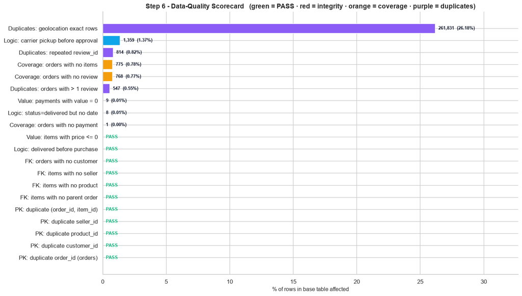

```python
DQ_CHECKS = [
 # (label, SQL returning issue count, base table for %, category)
 ("PK: duplicate order_id (orders)",        "SELECT COUNT(*) - COUNT(DISTINCT order_id) FROM orders", "orders", "integrity"),
 ("PK: duplicate customer_id",              "SELECT COUNT(*) - COUNT(DISTINCT customer_id) FROM customers", "customers", "integrity"),
 ("PK: duplicate product_id",               "SELECT COUNT(*) - COUNT(DISTINCT product_id) FROM products", "products", "integrity"),
 ("PK: duplicate seller_id",                "SELECT COUNT(*) - COUNT(DISTINCT seller_id) FROM sellers", "sellers", "integrity"),
 ("PK: duplicate (order_id, item_id)",      "SELECT COUNT(*) - (SELECT COUNT(*) FROM (SELECT DISTINCT order_id, order_item_id FROM order_items)) FROM order_items", "order_items", "integrity"),
 ("FK: items with no parent order",         "SELECT COUNT(*) FROM order_items i LEFT JOIN orders o ON o.order_id = i.order_id WHERE o.order_id IS NULL", "order_items", "integrity"),
 ("FK: items with no product",              "SELECT COUNT(*) FROM order_items i LEFT JOIN products p ON p.product_id = i.product_id WHERE p.product_id IS NULL", "order_items", "integrity"),
 ("FK: items with no seller",               "SELECT COUNT(*) FROM order_items i LEFT JOIN sellers s ON s.seller_id = i.seller_id WHERE s.seller_id IS NULL", "order_items", "integrity"),
 ("FK: orders with no customer",            "SELECT COUNT(*) FROM orders o LEFT JOIN customers c ON c.customer_id = o.customer_id WHERE c.customer_id IS NULL", "orders", "integrity"),
 ("Coverage: orders with no items",         "SELECT COUNT(*) FROM orders o LEFT JOIN (SELECT DISTINCT order_id FROM order_items) i ON i.order_id = o.order_id WHERE i.order_id IS NULL", "orders", "coverage"),
 ("Coverage: orders with no payment",       "SELECT COUNT(*) FROM orders o LEFT JOIN (SELECT DISTINCT order_id FROM order_payments) p ON p.order_id = o.order_id WHERE p.order_id IS NULL", "orders", "coverage"),
 ("Coverage: orders with no review",        "SELECT COUNT(*) FROM orders o LEFT JOIN (SELECT DISTINCT order_id FROM order_reviews) r ON r.order_id = o.order_id WHERE r.order_id IS NULL", "orders", "coverage"),
 ("Duplicates: orders with > 1 review",     "SELECT COUNT(*) FROM (SELECT order_id FROM order_reviews GROUP BY order_id HAVING COUNT(*) > 1)", "orders", "duplicates"),
 ("Duplicates: repeated review_id",         "SELECT COUNT(*) - COUNT(DISTINCT review_id) FROM order_reviews", "order_reviews", "duplicates"),
 ("Duplicates: geolocation exact rows",     "SELECT COUNT(*) - (SELECT COUNT(*) FROM (SELECT DISTINCT * FROM geolocation)) FROM geolocation", "geolocation", "duplicates"),
 ("Value: payments with value = 0",         "SELECT COUNT(*) FROM order_payments WHERE payment_value = 0", "order_payments", "value"),
 ("Value: items with price <= 0",           "SELECT COUNT(*) FROM order_items WHERE price <= 0", "order_items", "value"),
 ("Logic: delivered before purchase",       "SELECT COUNT(*) FROM orders WHERE order_delivered_customer_date < order_purchase_timestamp", "orders", "logic"),
 ("Logic: carrier pickup before approval",  "SELECT COUNT(*) FROM orders WHERE order_delivered_carrier_date < order_approved_at", "orders", "logic"),
 ("Logic: status=delivered but no date",    "SELECT COUNT(*) FROM orders WHERE order_status = 'delivered' AND order_delivered_customer_date IS NULL", "orders", "logic"),
]

rows = []
for label, sql, base, cat in DQ_CHECKS:
    n = conn.execute(sql).fetchone()[0]
    b = conn.execute(f"SELECT COUNT(*) FROM {base}").fetchone()[0]
    rows.append({"check": label, "issues": int(n), "pct_of_base": n / b * 100, "category": cat})
dq = pd.DataFrame(rows)
display(dq)

dq_plot = dq.sort_values("pct_of_base").reset_index(drop=True)
cat_color = {"integrity": RED, "coverage": ORANGE, "duplicates": PURPLE, "value": BLUE, "logic": "#0EA5E9"}
colors = [GREEN if n == 0 else cat_color[c] for n, c in zip(dq_plot["issues"], dq_plot["category"])]

fig, ax = plt.subplots(figsize=(14, 8))
ax.barh(dq_plot["check"], dq_plot["pct_of_base"], color=colors, edgecolor="white")
for y, (p, n) in enumerate(zip(dq_plot["pct_of_base"], dq_plot["issues"])):
    ax.text(p + 0.25, y, "PASS" if n == 0 else f"{n:,}  ({p:.2f}%)", va="center", fontsize=8.5,
            color=GREEN if n == 0 else "#0F172A", fontweight="bold")
ax.set_xlim(0, max(dq_plot["pct_of_base"].max() * 1.25, 5)); ax.set_xlabel("% of rows in base table affected")
ax.set_title("Step 6 - Data-Quality Scorecard   (green = PASS · red = integrity · orange = coverage · purple = duplicates)")
plt.tight_layout(); plt.show()
```

**📌 Observation:** All **9 primary-key and foreign-key checks pass** (0 duplicate `order_id`, `customer_id`, `product_id`, `seller_id` or `(order_id, item_id)`; 0 orphan items, and 0 orders without a customer), so joins are structurally safe. The scorecard's problems are about *coverage, duplication and logic*. By size: **261,831 exact duplicate `geolocation` rows (26.2 %)**; **1,359 orders (1.37 %) where the carrier pickup is timestamped before approval**; **814 repeated `review_id`s (0.82 %)** and **547 orders (0.55 %) with more than one review**; **775 orders (0.78 %) with no items** and 768 (0.77 %) with no review; and tiny counts for zero-value payments (9), `delivered` orders with no delivery date (8) and an order with no payment (1). No item has a price ≤ 0 and none is delivered before it was purchased.

**💡 Pipeline / Engineering decision:** Reviews are **collapsed to one row per order** (`AVG(review_score)`) in the master view so a multi-review order can never multiply revenue. Orders with no items stay in status / funnel analysis but drop out of revenue KPIs because their `items_value` is `NULL`. `geolocation` is de-duplicated to one centroid per zip prefix before any use. The 1,359 carrier-before-approval orders are the same defect that reappears as **1,373 negative stage durations in Step 18**, so they are excluded from that decomposition only, not from revenue. The whole scorecard is kept as a reusable list (`DQ_CHECKS`) so it can run as an **automated data-contract gate** on every new data drop.

## Step 7 — Order Status and Fulfilment Funnel

**Why:** Before measuring revenue we must decide *which orders count*. The status mix and the placed → approved → shipped → delivered funnel show how much demand actually converts into a fulfilled sale, and where it leaks.

**Business insight:** Cancelled and unavailable orders are lost revenue *and* a customer-experience failure (stock-outs). Flipkart / Amazon track "fulfilment rate" as a top-line health metric because every leak at this stage is demand that marketing already paid to acquire.

|  | order_status | orders | pct |
| --- | --- | --- | --- |
| 0 | delivered | 96478 | 97.02 |
| 1 | shipped | 1107 | 1.11 |
| 2 | canceled | 625 | 0.63 |
| 3 | unavailable | 609 | 0.61 |
| 4 | invoiced | 314 | 0.32 |
| 5 | processing | 301 | 0.30 |
| 6 | created | 5 | 0.01 |
| 7 | approved | 2 | 0.00 |

|  | stage | orders | pct_of_placed | drop_vs_prev |
| --- | --- | --- | --- | --- |
| 0 | Placed | 99441 | 100.00 | 0 |
| 1 | Approved | 99281 | 99.84 | -160 |
| 2 | Handed to carrier | 97658 | 98.21 | -1623 |
| 3 | Delivered | 96476 | 97.02 | -1182 |

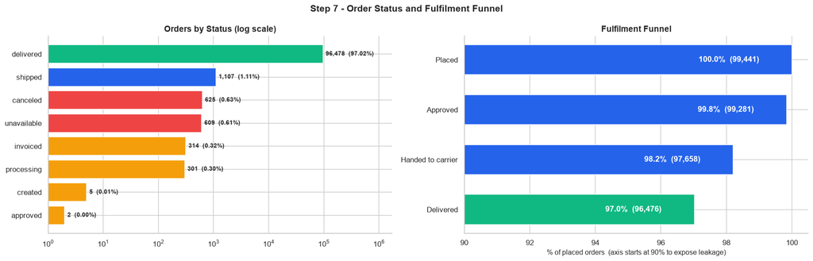

```python
status = q("""
    SELECT order_status,
           COUNT(*) AS orders,
           ROUND(100.0 * COUNT(*) / SUM(COUNT(*)) OVER (), 2) AS pct
    FROM orders
    GROUP BY order_status
    ORDER BY orders DESC
""")
display(status)

funnel = q("""
    SELECT COUNT(*)                                     AS placed,
           SUM(order_approved_at             IS NOT NULL) AS approved,
           SUM(order_delivered_carrier_date  IS NOT NULL) AS shipped,
           SUM(order_delivered_customer_date IS NOT NULL) AS delivered
    FROM orders
""").iloc[0]
funnel_df = pd.DataFrame({"stage": ["Placed", "Approved", "Handed to carrier", "Delivered"], "orders": funnel.values.astype(int)})
funnel_df["pct_of_placed"] = funnel_df["orders"] / funnel_df["orders"].iloc[0] * 100
funnel_df["drop_vs_prev"] = funnel_df["orders"].diff().fillna(0).astype(int)
display(funnel_df)

fig, axes = plt.subplots(1, 2, figsize=(17, 5.5))
st = status.iloc[::-1]
cmap = {"delivered": GREEN, "shipped": BLUE, "canceled": RED, "unavailable": RED}
axes[0].barh(st["order_status"], st["orders"], color=[cmap.get(s, ORANGE) for s in st["order_status"]], edgecolor="white")
axes[0].set_xscale("log")
for y, (n, p) in enumerate(zip(st["orders"], st["pct"])):
    axes[0].text(n * 1.12, y, f"{n:,}  ({p:.2f}%)", va="center", fontsize=9, fontweight="bold")
axes[0].set_xlim(1, st["orders"].max() * 18)
axes[0].set_title("Orders by Status (log scale)")

fd = funnel_df.iloc[::-1]
axes[1].barh(fd["stage"], fd["pct_of_placed"], color=[GREEN, BLUE, BLUE, BLUE], edgecolor="white", height=0.6)
for y, (p, n) in enumerate(zip(fd["pct_of_placed"], fd["orders"])):
    axes[1].text(p - 1.0, y, f"{p:.1f}%  ({n:,})", va="center", ha="right", color="white", fontweight="bold")
axes[1].set_xlim(90, 100.5); axes[1].set_xlabel("% of placed orders  (axis starts at 90% to expose leakage)")
axes[1].set_title("Fulfilment Funnel")
plt.suptitle("Step 7 - Order Status and Fulfilment Funnel", fontsize=14, fontweight="bold")
plt.tight_layout(); plt.show()
```

**💡 Pipeline / Engineering decision:** A boolean **`is_valid_order`** (status not in `canceled`, `unavailable`) is defined once in the master view (Step 8) and reused by every revenue KPI: one definition, no drift between dashboards. Delivery / SLA metrics use the stricter `order_status = 'delivered'` filter, because a shipped or in-transit order has no delivery outcome yet. The approval→carrier drop is flagged as the first place to look for **seller-side fulfilment failures** (out-of-stock, late dispatch) in the seller scorecard.

## Step 8 — Analytical Master View (Grain Control & the Fan-Out Trap)

**Why:** The single most common SQL mistake in e-commerce analytics is the **fan-out (join explosion)**: joining `orders → order_items → order_payments` directly repeats each order once per (item × payment) pair, so `SUM()` overstates revenue. The fix is to **pre-aggregate each child table to order grain** *before* joining. This step builds `vw_order_master` (exactly one row per order) and proves — numerically — why it matters.

**Business insight:** An inflated revenue number in a board deck is a career-limiting error. Building one certified, order-grain view means every analyst downstream gets the same, correct numbers.

```
Grain test passed: view rows = 99,441 = orders rows = 99,441
Reconciliation passed: view totals = source-table totals
```

|  | Source table (truth) | Master view (pre-aggregated) | Naive 3-way join | naive_inflation_% |
| --- | --- | --- | --- | --- |
| Product value (SUM price) | 13,591,643.70 | 13,591,643.70 | 14,209,115.34 | 4.54 |
| Payments (SUM payment_value) | 16,008,872.12 | 16,008,872.12 | 20,308,134.71 | 26.86 |

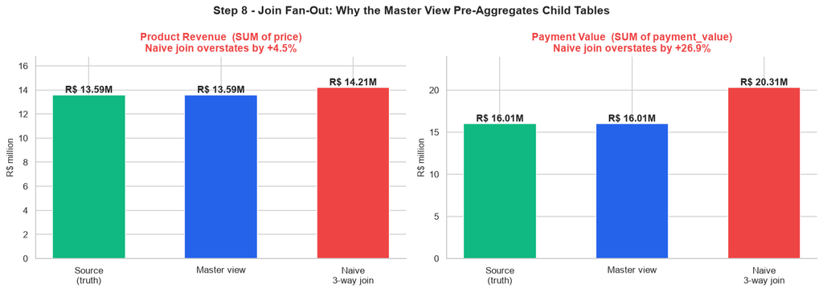

|  | 0 | 1 | 2 |
| --- | --- | --- | --- |
| order_id | e481f51cbdc54678b7cc49136f2d6af7 | 53cdb2fc8bc7dce0b6741e2150273451 | 47770eb9100c2d0c44946d9cf07ec65d |
| customer_id | 9ef432eb6251297304e76186b10a928d | b0830fb4747a6c6d20dea0b8c802d7ef | 41ce2a54c0b03bf3443c3d931a367089 |
| customer_unique_id | 7c396fd4830fd04220f754e42b4e5bff | af07308b275d755c9edb36a90c618231 | 3a653a41f6f9fc3d2a113cf8398680e8 |
| customer_state | SP | BA | GO |
| customer_city | sao paulo | barreiras | vianopolis |
| order_status | delivered | delivered | delivered |
| is_valid_order | 1 | 1 | 1 |
| purchase_ts | 2017-10-02 10:56:33 | 2018-07-24 20:41:37 | 2018-08-08 08:38:49 |
| purchase_date | 2017-10-02 | 2018-07-24 | 2018-08-08 |
| purchase_month | 2017-10 | 2018-07 | 2018-08 |
| order_approved_at | 2017-10-02 11:07:15 | 2018-07-26 03:24:27 | 2018-08-08 08:55:23 |
| order_delivered_carrier_date | 2017-10-04 19:55:00 | 2018-07-26 14:31:00 | 2018-08-08 13:50:00 |
| order_delivered_customer_date | 2017-10-10 21:25:13 | 2018-08-07 15:27:45 | 2018-08-17 18:06:29 |
| order_estimated_delivery_date | 2017-10-18 00:00:00 | 2018-08-13 00:00:00 | 2018-09-04 00:00:00 |
| delivery_days | 8.44 | 13.78 | 9.39 |
| estimated_days | 15.54 | 19.14 | 26.64 |
| delay_days | -8 | -6 | -18 |
| is_late | 0 | 0 | 0 |
| n_items | 1 | 1 | 1 |
| n_sellers | 1 | 1 | 1 |
| n_products | 1 | 1 | 1 |
| items_value | 29.99 | 118.70 | 159.90 |
| freight_value | 8.72 | 22.76 | 19.22 |
| payment_value | 38.71 | 141.46 | 179.12 |
| max_installments | 1 | 1 | 3 |
| n_payment_rows | 3 | 1 | 1 |
| main_payment_type | voucher | boleto | credit_card |
| review_score | 4.00 | 4.00 | 5.00 |
| has_comment | 1 | 1 | 0 |

```python
conn.executescript("""
DROP VIEW IF EXISTS vw_order_master;
CREATE VIEW vw_order_master AS
WITH items AS (                      -- 1 row / order
    SELECT order_id,
           COUNT(*)                   AS n_items,
           COUNT(DISTINCT seller_id)  AS n_sellers,
           COUNT(DISTINCT product_id) AS n_products,
           SUM(price)                 AS items_value,
           SUM(freight_value)         AS freight_value
    FROM order_items GROUP BY order_id
),
pay_ranked AS (
    SELECT order_id, payment_type, payment_installments, payment_value,
           ROW_NUMBER() OVER (PARTITION BY order_id ORDER BY payment_value DESC, payment_sequential) AS rn
    FROM order_payments
),
pay AS (                             -- 1 row / order
    SELECT order_id,
           SUM(payment_value)                        AS payment_value,
           MAX(payment_installments)                 AS max_installments,
           COUNT(*)                                  AS n_payment_rows,
           MAX(CASE WHEN rn = 1 THEN payment_type END) AS main_payment_type
    FROM pay_ranked GROUP BY order_id
),
rev AS (                             -- 1 row / order
    SELECT order_id,
           AVG(review_score) AS review_score,
           MAX(CASE WHEN review_comment_message IS NOT NULL THEN 1 ELSE 0 END) AS has_comment
    FROM order_reviews GROUP BY order_id
)
SELECT o.order_id,
       o.customer_id,
       c.customer_unique_id,
       c.customer_state,
       c.customer_city,
       o.order_status,
       CASE WHEN o.order_status IN ('canceled','unavailable') THEN 0 ELSE 1 END AS is_valid_order,
       o.order_purchase_timestamp                          AS purchase_ts,
       DATE(o.order_purchase_timestamp)                    AS purchase_date,
       STRFTIME('%Y-%m', o.order_purchase_timestamp)       AS purchase_month,
       o.order_approved_at,
       o.order_delivered_carrier_date,
       o.order_delivered_customer_date,
       o.order_estimated_delivery_date,
       ROUND(JULIANDAY(o.order_delivered_customer_date) - JULIANDAY(o.order_purchase_timestamp), 2) AS delivery_days,
       ROUND(JULIANDAY(o.order_estimated_delivery_date) - JULIANDAY(o.order_purchase_timestamp), 2) AS estimated_days,
       CASE WHEN o.order_delivered_customer_date IS NULL THEN NULL
            ELSE CAST(JULIANDAY(DATE(o.order_delivered_customer_date)) - JULIANDAY(DATE(o.order_estimated_delivery_date)) AS INTEGER)
       END AS delay_days,
       CASE WHEN o.order_delivered_customer_date IS NULL THEN NULL
            WHEN DATE(o.order_delivered_customer_date) > DATE(o.order_estimated_delivery_date) THEN 1 ELSE 0
       END AS is_late,
       i.n_items, i.n_sellers, i.n_products, i.items_value, i.freight_value,
       p.payment_value, p.max_installments, p.n_payment_rows, p.main_payment_type,
       r.review_score, r.has_comment
FROM orders o
LEFT JOIN customers c ON c.customer_id = o.customer_id
LEFT JOIN items     i ON i.order_id    = o.order_id
LEFT JOIN pay       p ON p.order_id    = o.order_id
LEFT JOIN rev       r ON r.order_id    = o.order_id;
""")

# ── 1. Grain test: exactly one row per order ────────────────────────────
n_view, n_orders = q("SELECT COUNT(*) n FROM vw_order_master").n[0], len(tables["orders"])
assert n_view == n_orders, "Grain broken: view is not 1 row per order!"
print(f"Grain test passed: view rows = {n_view:,} = orders rows = {n_orders:,}")

# ── 2. Reconciliation against source tables + naive-join comparison ────
truth = q("SELECT (SELECT SUM(price) FROM order_items) AS items, (SELECT SUM(payment_value) FROM order_payments) AS pay").iloc[0]
view  = q("SELECT SUM(items_value) AS items, SUM(payment_value) AS pay FROM vw_order_master").iloc[0]
naive = q("""
    SELECT SUM(oi.price) AS items, SUM(p.payment_value) AS pay
    FROM orders o
    JOIN order_items    oi ON oi.order_id = o.order_id
    JOIN order_payments p  ON p.order_id  = o.order_id
""").iloc[0]
assert np.isclose(truth["items"], view["items"]) and np.isclose(truth["pay"], view["pay"]), "View does not reconcile to source!"
print("Reconciliation passed: view totals = source-table totals")

recon = pd.DataFrame({"Source table (truth)": truth, "Master view (pre-aggregated)": view, "Naive 3-way join": naive})
recon["naive_inflation_%"] = (recon["Naive 3-way join"] / recon["Source table (truth)"] - 1) * 100
display(recon.rename(index={"items": "Product value (SUM price)", "pay": "Payments (SUM payment_value)"}))

fig, axes = plt.subplots(1, 2, figsize=(14, 5))
for ax, key, title in zip(axes, ["items", "pay"], ["Product Revenue  (SUM of price)", "Payment Value  (SUM of payment_value)"]):
    vals = [truth[key], view[key], naive[key]]
    bars = ax.bar(["Source\n(truth)", "Master view", "Naive\n3-way join"], np.array(vals) / 1e6, color=[GREEN, BLUE, RED], edgecolor="white", width=0.55)
    for b, v in zip(bars, vals):
        ax.text(b.get_x() + b.get_width() / 2, b.get_height(), f"R$ {v/1e6:,.2f}M", ha="center", va="bottom", fontweight="bold")
    infl = (naive[key] / truth[key] - 1) * 100
    ax.set_title(f"{title}\nNaive join overstates by {infl:+.1f}%", color=RED if infl > 0.5 else "black")
    ax.set_ylabel("R$ million"); ax.set_ylim(0, max(vals) / 1e6 * 1.18)
plt.suptitle("Step 8 - Join Fan-Out: Why the Master View Pre-Aggregates Child Tables", fontsize=14, fontweight="bold")
plt.tight_layout(); plt.show()

display(q("SELECT * FROM vw_order_master LIMIT 3").T)
```

**📌 Observation:** The master view passes both safety tests: **99,441 view rows = 99,441 orders** (grain test) and view totals equal the source tables to the paisa (reconciliation test). The naive `orders ⋈ order_items ⋈ order_payments` join fails: product revenue is **R$ 14.21 M instead of R$ 13.59 M (+4.5 %)** and payment value is **R$ 20.31 M instead of R$ 16.01 M (+26.9 %)** — the red bars are visibly taller than the green (truth) and blue (view) bars, which are identical. The payment total is inflated more because every item row is repeated for each payment row, so a multi-item, multi-payment order is counted many times. The sample rows show the intended shape: one row per order carrying `n_items`, `items_value`, `freight_value`, `payment_value`, `max_installments`, `main_payment_type`, `delay_days`, `is_late` and `review_score`.

**💡 Pipeline / Engineering decision:** **Every child table is aggregated to order grain first, then joined** — the non-negotiable rule for every query in the notebook. `vw_order_master` is the *certified semantic layer*: it carries pre-computed `is_valid_order`, `delivery_days`, `delay_days`, `is_late`, `main_payment_type` and `review_score`, so business logic lives in one place. The two `assert` statements are **automated regression tests**: if a future schema change breaks grain or reconciliation, the notebook stops instead of silently reporting a revenue number that is up to 27 % too high.

## Step 9 — Executive KPI Dashboard

**Why:** Every BI engagement starts with a one-screen scoreboard. These headline KPIs (scale, value, experience, loyalty) give the reader the size of the business before any deep-dive, and give us **baseline numbers** to sanity-check everything that follows.

**Business insight:** GMV and AOV describe *commercial scale*; average review and late-delivery rate describe *customer experience*; repeat-purchase rate describes *loyalty*. A healthy marketplace needs all three — strong GMV with weak loyalty means growth is bought, not earned.

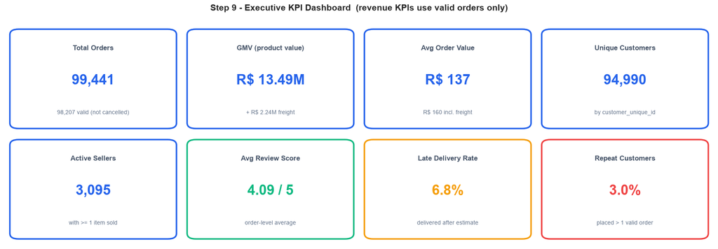

```python
kpi = q("""
    SELECT COUNT(*)                                                            AS total_orders,
           SUM(is_valid_order)                                                 AS valid_orders,
           COUNT(DISTINCT CASE WHEN is_valid_order = 1 THEN customer_unique_id END) AS customers,
           SUM(CASE WHEN is_valid_order = 1 THEN items_value   END)            AS gmv,
           SUM(CASE WHEN is_valid_order = 1 THEN freight_value END)            AS freight,
           AVG(CASE WHEN is_valid_order = 1 THEN items_value   END)            AS aov_items,
           AVG(CASE WHEN is_valid_order = 1 THEN items_value + freight_value END) AS aov_total,
           AVG(review_score)                                                   AS avg_review,
           100.0 * AVG(is_late)                                                AS late_pct
    FROM vw_order_master
""").iloc[0]

sellers_n = q("SELECT COUNT(DISTINCT seller_id) AS n FROM order_items").n[0]
repeat = q("""
    WITH c AS (SELECT customer_unique_id, COUNT(*) AS n FROM vw_order_master WHERE is_valid_order = 1 GROUP BY 1)
    SELECT 100.0 * SUM(CASE WHEN n > 1 THEN 1 ELSE 0 END) / COUNT(*) AS repeat_pct FROM c
""").repeat_pct[0]

cards = [
    ("Total Orders",        f"{kpi.total_orders:,.0f}",          f"{kpi.valid_orders:,.0f} valid (not cancelled)", BLUE),
    ("GMV (product value)", f"R$ {kpi.gmv/1e6:,.2f}M",          f"+ R$ {kpi.freight/1e6:,.2f}M freight",           BLUE),
    ("Avg Order Value",     f"R$ {kpi.aov_items:,.0f}",           f"R$ {kpi.aov_total:,.0f} incl. freight",          BLUE),
    ("Unique Customers",    f"{kpi.customers:,.0f}",              "by customer_unique_id",                            BLUE),
    ("Active Sellers",      f"{sellers_n:,.0f}",                  "with >= 1 item sold",                              BLUE),
    ("Avg Review Score",    f"{kpi.avg_review:.2f} / 5",          "order-level average",  GREEN if kpi.avg_review >= 4 else ORANGE),
    ("Late Delivery Rate",  f"{kpi.late_pct:.1f}%",               "delivered after estimate", GREEN if kpi.late_pct < 5 else ORANGE if kpi.late_pct < 10 else RED),
    ("Repeat Customers",    f"{repeat:.1f}%",                     "placed > 1 valid order", RED if repeat < 10 else GREEN),
]
fig, ax = plt.subplots(figsize=(16, 5.6)); ax.axis("off"); ax.set_xlim(0, 4); ax.set_ylim(0, 2)
for i, (title, value, sub, color) in enumerate(cards):
    x, y = i % 4, 1 - i // 4
    ax.add_patch(FancyBboxPatch((x + 0.04, y + 0.06), 0.92, 0.88, boxstyle="round,pad=0.01,rounding_size=0.05",
                                fc="white", ec=color, lw=2.4))
    ax.text(x + 0.5, y + 0.76, title, ha="center", fontsize=11, color="#475569", fontweight="bold")
    ax.text(x + 0.5, y + 0.45, value, ha="center", fontsize=22, color=color, fontweight="bold")
    ax.text(x + 0.5, y + 0.18, sub, ha="center", fontsize=9, color="#64748B")
plt.suptitle("Step 9 - Executive KPI Dashboard  (revenue KPIs use valid orders only)", fontsize=14, fontweight="bold")
plt.tight_layout(); plt.show()
```

**📌 Observation:** The scoreboard shows **99,441 orders** (98,207 valid), **R$ 13.49 M product GMV** (+ R$ 2.24 M freight), an **AOV of R$ 137 **(R$ 160 including freight),** 94,990 unique customers **and** 3,095 active sellers**. Experience is good: average review** 4.09 / 5 **(green) and a** 6.8 % late-delivery rate **(orange). The one red card is** repeat customers at only 3.0 %** — almost everyone buys once. GMV and payments differ because payments include freight (R$ 16.0 M in Step 8 vs R$ 13.5 M here after excluding cancelled orders and freight).

**💡 Pipeline / Engineering decision:** These eight numbers become the **KPI contract** for the project: they are recomputed from `vw_order_master`, exported as `kpi_scoreboard` (Step 28), and any future dashboard must reconcile to them. The colour code (blue = volume, green / orange / red = health) is reused downstream. The 3.0 % repeat rate reframes the whole analysis: growth in Step 10 is an **acquisition story**, and retention (Steps 23-25) is where the largest untapped value sits.

## Step 10 — Monthly Revenue Trend and MoM Growth

**Why:** A trend line is the first thing every stakeholder asks for. We compute monthly GMV, orders, customers and AOV **in SQL** using a CTE plus the `LAG()` window function for month-over-month growth and a 3-month moving average to smooth noise. Only the complete analysis window (`2017-01 → 2018-08`, decided in Step 4) is used.

**Business insight:** Growth *rate* matters more than growth *level*. A business can keep adding revenue while its growth quietly stalls — the MoM bars and moving average expose that difference. Event months (Black Friday) must be separated from underlying trend before forecasting.

|  | purchase_month | orders | customers | gmv | freight | aov | gmv_mom_pct | orders_mom_pct | gmv_3m_avg |
| --- | --- | --- | --- | --- | --- | --- | --- | --- | --- |
| 0 | 2017-01 | 787 | 753 | 120,098.27 | 16,845.19 | 152.60 | NaN | NaN | 120,098.27 |
| 1 | 2017-02 | 1718 | 1693 | 244,959.35 | 38,602.34 | 142.58 | 104.00 | 118.30 | 182,528.81 |
| 2 | 2017-03 | 2617 | 2577 | 368,341.32 | 57,276.64 | 140.75 | 50.40 | 52.30 | 244,466.31 |
| 3 | 2017-04 | 2377 | 2345 | 353,842.98 | 52,005.63 | 148.86 | -3.90 | -9.20 | 322,381.22 |
| 4 | 2017-05 | 3640 | 3569 | 503,159.19 | 79,551.64 | 138.23 | 42.20 | 53.10 | 408,447.83 |
| 5 | 2017-06 | 3205 | 3142 | 429,916.61 | 69,735.63 | 134.14 | -14.60 | -12.00 | 428,972.93 |
| 6 | 2017-07 | 3946 | 3872 | 492,287.30 | 86,466.43 | 124.76 | 14.50 | 23.10 | 475,121.03 |
| 7 | 2017-08 | 4272 | 4191 | 568,245.79 | 93,657.73 | 133.02 | 15.40 | 8.30 | 496,816.57 |
| 8 | 2017-09 | 4227 | 4154 | 621,415.91 | 95,686.81 | 147.01 | 9.40 | -1.10 | 560,649.67 |
| 9 | 2017-10 | 4547 | 4481 | 660,179.62 | 104,576.41 | 145.19 | 6.20 | 7.60 | 616,613.77 |
| 10 | 2017-11 | 7423 | 7315 | 1,003,862.14 | 168,329.54 | 135.27 | 52.10 | 63.30 | 761,819.22 |
| 11 | 2017-12 | 5620 | 5553 | 742,183.79 | 119,342.98 | 132.11 | -26.10 | -24.30 | 802,075.18 |
| 12 | 2018-01 | 7187 | 7088 | 945,456.29 | 156,463.72 | 131.55 | 27.40 | 27.90 | 897,167.41 |
| 13 | 2018-02 | 6625 | 6469 | 837,895.43 | 141,590.73 | 126.49 | -11.40 | -7.80 | 841,845.17 |
| 14 | 2018-03 | 7168 | 7077 | 981,051.06 | 171,605.93 | 136.87 | 17.10 | 8.20 | 921,467.59 |
| 15 | 2018-04 | 6919 | 6863 | 993,592.98 | 162,655.91 | 143.60 | 1.30 | -3.50 | 937,513.16 |
| 16 | 2018-05 | 6833 | 6775 | 992,871.75 | 152,814.71 | 145.31 | -0.10 | -1.20 | 989,171.93 |
| 17 | 2018-06 | 6145 | 6106 | 863,265.53 | 157,116.37 | 140.48 | -13.10 | -10.10 | 949,910.09 |
| 18 | 2018-07 | 6233 | 6172 | 878,044.27 | 161,739.31 | 140.87 | 1.70 | 1.40 | 911,393.85 |
| 19 | 2018-08 | 6421 | 6380 | 848,860.10 | 148,113.41 | 132.20 | -3.30 | 3.00 | 863,389.97 |

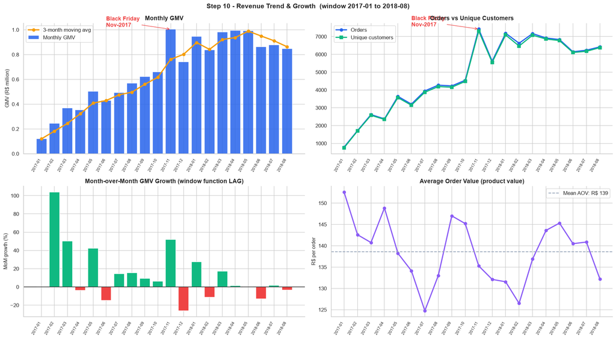

```
Peak GMV month             : 2017-11  (R$ 1.00M)
First-3-month avg GMV      : R$ 0.24M   ->   last-3-month avg: R$ 0.86M
2018 monthly orders (range): 6,145 - 7,187   | coefficient of variation = 6.0%
```

```python
WINDOW_START, WINDOW_END = "2017-01", "2018-08"

monthly = q("""
    WITH m AS (
        SELECT purchase_month,
               COUNT(*)                            AS orders,
               COUNT(DISTINCT customer_unique_id)  AS customers,
               SUM(items_value)                    AS gmv,
               SUM(freight_value)                  AS freight,
               AVG(items_value)                    AS aov
        FROM vw_order_master
        WHERE is_valid_order = 1 AND purchase_month BETWEEN :s AND :e
        GROUP BY purchase_month
    )
    SELECT purchase_month, orders, customers,
           ROUND(gmv, 2) AS gmv, ROUND(freight, 2) AS freight, ROUND(aov, 2) AS aov,
           ROUND(100.0 * (gmv    - LAG(gmv)    OVER w) / LAG(gmv)    OVER w, 1) AS gmv_mom_pct,
           ROUND(100.0 * (orders - LAG(orders) OVER w) / LAG(orders) OVER w, 1) AS orders_mom_pct,
           ROUND(AVG(gmv) OVER (ORDER BY purchase_month ROWS BETWEEN 2 PRECEDING AND CURRENT ROW), 2) AS gmv_3m_avg
    FROM m
    WINDOW w AS (ORDER BY purchase_month)
    ORDER BY purchase_month
""", {"s": WINDOW_START, "e": WINDOW_END})
display(monthly)

mo = monthly.reset_index(drop=True)
x, lbl = np.arange(len(mo)), mo["purchase_month"]
def month_axis(ax):
    ax.set_xticks(x); ax.set_xticklabels(lbl, rotation=60, ha="right", fontsize=8)

fig, axes = plt.subplots(2, 2, figsize=(18, 10))
axes[0, 0].bar(x, mo["gmv"] / 1e6, color=BLUE, alpha=0.85, edgecolor="white", label="Monthly GMV")
axes[0, 0].plot(x, mo["gmv_3m_avg"] / 1e6, color=ORANGE, lw=2.6, marker="o", label="3-month moving avg")
axes[0, 0].set_ylabel("GMV (R$ million)"); axes[0, 0].set_title("Monthly GMV"); axes[0, 0].legend(); month_axis(axes[0, 0])

axes[0, 1].plot(x, mo["orders"], color=BLUE, lw=2.4, marker="o", label="Orders")
axes[0, 1].plot(x, mo["customers"], color=GREEN, lw=2.4, marker="s", label="Unique customers")
axes[0, 1].set_title("Orders vs Unique Customers"); axes[0, 1].legend(); month_axis(axes[0, 1])

g = mo["gmv_mom_pct"].fillna(0)
axes[1, 0].bar(x, g, color=[GREEN if v >= 0 else RED for v in g], edgecolor="white")
axes[1, 0].axhline(0, color="black", lw=1)
axes[1, 0].set_ylabel("MoM growth (%)"); axes[1, 0].set_title("Month-over-Month GMV Growth (window function LAG)"); month_axis(axes[1, 0])

axes[1, 1].plot(x, mo["aov"], color=PURPLE, lw=2.4, marker="o")
axes[1, 1].axhline(mo["aov"].mean(), color=GRAY, ls="--", label=f"Mean AOV: R$ {mo['aov'].mean():.0f}")
axes[1, 1].set_ylabel("R$ per order"); axes[1, 1].set_title("Average Order Value (product value)"); axes[1, 1].legend(); month_axis(axes[1, 1])

if "2017-11" in set(lbl):
    i = int(mo.index[mo["purchase_month"] == "2017-11"][0])
    for ax, yv in [(axes[0, 0], mo["gmv"][i] / 1e6), (axes[0, 1], mo["orders"][i])]:
        ax.annotate("Black Friday\nNov-2017", xy=(i, yv), xytext=(max(i - 5, 0), yv * 1.02), fontweight="bold", color=RED,
                    arrowprops=dict(arrowstyle="->", color=RED))
plt.suptitle("Step 10 - Revenue Trend & Growth  (window 2017-01 to 2018-08)", fontsize=14, fontweight="bold")
plt.tight_layout(); plt.show()

h1 = mo[mo["purchase_month"].between("2018-01", "2018-08")]
print(f"Peak GMV month             : {mo.loc[mo.gmv.idxmax(), 'purchase_month']}  (R$ {mo.gmv.max()/1e6:.2f}M)")
print(f"First-3-month avg GMV      : R$ {mo.gmv.head(3).mean()/1e6:.2f}M   ->   last-3-month avg: R$ {mo.gmv.tail(3).mean()/1e6:.2f}M")
print(f"2018 monthly orders (range): {h1.orders.min():,} - {h1.orders.max():,}   | coefficient of variation = {h1.orders.std()/h1.orders.mean():.1%}")
```

**📌 Observation:** GMV grows from **R$ 0.12 M in Jan-2017 to R$ 1.00 M in Nov-2017 (≈ 8×)**, with the 3-month average (orange line) rising almost every month. **Nov-2017 (Black Friday) is the peak: 7,423 orders, R$ 1.00 M, +52 % GMV and +63 % orders MoM**, followed by the largest drop in the series, **−26 % in Dec-2017**. But the spike is not far above the new normal: **Apr-2018 (R$ 0.994 M) and May-2018 (R$ 0.993 M) are within ~1 % of it**, so from Jan-2018 the business runs at a **plateau of 6,145-7,187 orders per month (CV = 6.0 %)** with MoM growth oscillating between −13 % and +27 %. After the May-2018 peak the 3-month average **drifts down to R$ 0.86 M by Aug-2018 (about −13 % from its high)**. AOV (bottom-right) is noisy, from **R$ 124.8 (Jul-2017) to R$ 152.6 (Jan-2017)**, and orders and unique customers move almost identically (top-right), so 2017's growth came from **more buyers, not larger baskets**.

**💡 Pipeline / Engineering decision:** The analysis window lives in `WINDOW_START` / `WINDOW_END` and is injected into SQL with bound parameters — no hard-coded dates. Nov-2017 is flagged as an **event month** (`is_event_month` in `mart_orders`), so forecasting models must either include that flag or exclude the month from trend fitting, and should **extrapolate from the 2018 plateau level, not the 2017 ramp**, otherwise they will over-forecast. Because monthly growth is now flat-to-slightly-negative, the KPI pack reports the 3-month average and YoY (Step 27) rather than raw MoM.

## Step 11 — Purchase Seasonality (Day-of-Week × Hour-of-Day)

**Why:** A day × hour heatmap answers "**when** do customers shop?" in one picture. It is the standard input for campaign scheduling, push-notification timing and customer-support staffing. SQL's `STRFTIME('%w')` and `STRFTIME('%H')` extract the parts directly from the stored timestamps.

**Business insight:** Sending a promotion at the wrong hour wastes the most expensive marketing resource — attention. Aligning campaigns to natural demand peaks (or deliberately targeting troughs to smooth load) is a zero-cost optimisation.

```
Share of orders by day-part:
Night 00-05        4.80
Morning 06-11     22.30
Afternoon 12-17   38.60
Evening 18-23     34.30

Busiest weekday : Mon (15,934 orders)   |   Quietest weekday: Sat (10,726)
Busiest hour    : 16:00   |   Quietest hour   : 05:00
```

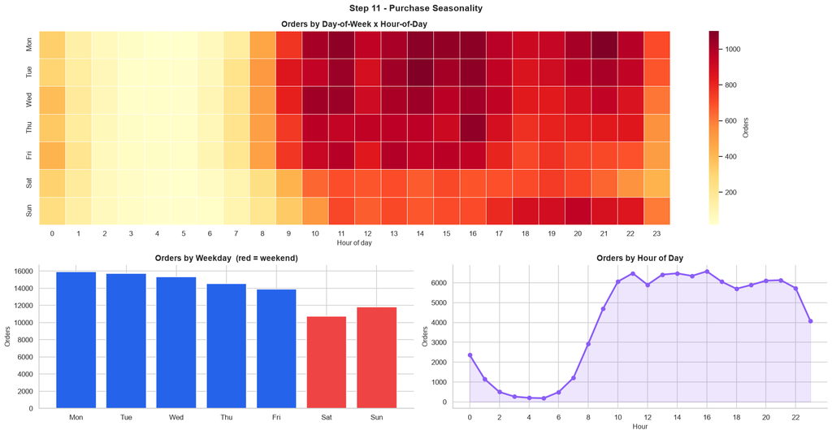

```python
season = q("""
    SELECT CAST(STRFTIME('%w', purchase_ts) AS INTEGER) AS dow,
           CAST(STRFTIME('%H', purchase_ts) AS INTEGER) AS hr,
           COUNT(*) AS orders
    FROM vw_order_master
    WHERE is_valid_order = 1 AND purchase_month BETWEEN :s AND :e
    GROUP BY dow, hr
""", {"s": WINDOW_START, "e": WINDOW_END})

DOW = {0: "Sun", 1: "Mon", 2: "Tue", 3: "Wed", 4: "Thu", 5: "Fri", 6: "Sat"}
heat = season.pivot(index="dow", columns="hr", values="orders").reindex(index=range(7), columns=range(24)).fillna(0)
heat.index = [DOW[i] for i in heat.index]
heat = heat.loc[["Mon", "Tue", "Wed", "Thu", "Fri", "Sat", "Sun"]]

by_day, by_hour = heat.sum(axis=1), heat.sum(axis=0)
day_part = pd.cut(pd.Series(range(24)), [-1, 5, 11, 17, 23], labels=["Night 00-05", "Morning 06-11", "Afternoon 12-17", "Evening 18-23"])
part_share = (by_hour.values.reshape(-1) / by_hour.sum() * 100)
part_df = pd.Series(part_share, index=day_part).groupby(level=0).sum()
print("Share of orders by day-part:"); print(part_df.round(1).to_string())
print(f"\nBusiest weekday : {by_day.idxmax()} ({by_day.max():,.0f} orders)   |   Quietest weekday: {by_day.idxmin()} ({by_day.min():,.0f})")
print(f"Busiest hour    : {by_hour.idxmax():02d}:00   |   Quietest hour   : {by_hour.idxmin():02d}:00")

fig = plt.figure(figsize=(18, 9.5))
gs = fig.add_gridspec(2, 2, height_ratios=[1.35, 1])
ax0 = fig.add_subplot(gs[0, :])
sns.heatmap(heat, cmap="YlOrRd", linewidths=0.4, cbar_kws={"label": "Orders"}, ax=ax0)
ax0.set_title("Orders by Day-of-Week x Hour-of-Day"); ax0.set_xlabel("Hour of day"); ax0.set_ylabel("")

ax1 = fig.add_subplot(gs[1, 0])
ax1.bar(by_day.index, by_day.values, color=[RED if d in ("Sat", "Sun") else BLUE for d in by_day.index], edgecolor="white")
ax1.set_title("Orders by Weekday  (red = weekend)"); ax1.set_ylabel("Orders")

ax2 = fig.add_subplot(gs[1, 1])
ax2.plot(by_hour.index, by_hour.values, color=PURPLE, lw=2.6, marker="o")
ax2.fill_between(by_hour.index, by_hour.values, alpha=0.15, color=PURPLE)
ax2.set_xticks(range(0, 24, 2)); ax2.set_title("Orders by Hour of Day"); ax2.set_xlabel("Hour"); ax2.set_ylabel("Orders")
plt.suptitle("Step 11 - Purchase Seasonality", fontsize=14, fontweight="bold")
plt.tight_layout(); plt.show()
```

**📌 Observation:** Demand is **weekday-heavy and declines through the week**: Monday is the busiest day (**15,934 orders**), then Tue > Wed > Thu > Fri, while **Saturday is the quietest (10,726)** and Sunday recovers to ~ 11.8 k — Monday is ~ 49 % busier than Saturday. Within a day the curve is a **long plateau rather than a sharp peak**: orders climb steeply between 07:00 and 10:00, stay at ~ 5.7-6.6 k per hour from **10:00 to 22:00** (peak at **16:00**), and fall to a trough at **03:00-05:00**. The day-part split is Afternoon 38.6 %, Evening 34.3 %, Morning 22.3 % and Night only 4.8 %. In the heatmap the hottest cells are **Mon 21:00, Tue 14:00 and Thu 16:00**, weekday mornings from 10:00 are consistently dark, and **Sunday evening (18:00-22:00)** lights up as the only strong weekend block. There is also a small bump at midnight (~ 2.4 k) above the 01:00-05:00 floor.

**💡 Pipeline / Engineering decision:** `dow`, `hour`, `is_weekend` and `day_part` are added to `mart_orders` (Step 28) as calendar features for forecasting and propensity models. Operationally: send campaigns and push notifications between **10:00 and 22:00 on Mon-Thu** (with a Sunday-evening slot to use the weekend rebound), staff customer support to the same weekday-daytime curve, and schedule batch jobs, data refreshes and price updates in the **03:00-05:00 trough**, when only ~200 orders per hour arrive.

## Step 12 — Category Revenue Pareto

**Why:** Revenue is never evenly spread. A **Pareto analysis** (cumulative share on a sorted list) shows how concentrated GMV is across the 70+ product categories. It is built in SQL with `SUM() OVER (ORDER BY ...)` for the running total and `RANK()` for ordering — the classic "top-N with cumulative share" interview query.

**Business insight:** Category managers cannot give 70 categories equal attention. Knowing the small set that produces ~80 % of GMV tells the business where inventory, seller-recruitment and marketing budgets should go first.

*Engineering note:* to avoid repeating a four-table join in every category / seller query, we first create a second certified layer, **`vw_item_master`** — one row per order item, enriched with English category, seller state and the order-level outcomes (delivery, review, status).

|  | category | orders | items | gmv | avg_price | share_pct | cum_share_pct | rnk |
| --- | --- | --- | --- | --- | --- | --- | --- | --- |
| 0 | health_beauty | 8800 | 9634 | 1,255,695.13 | 130.34 | 9.31 | 9.31 | 1 |
| 1 | watches_gifts | 5604 | 5970 | 1,198,185.21 | 200.70 | 8.88 | 18.18 | 2 |
| 2 | bed_bath_table | 9399 | 11097 | 1,035,964.06 | 93.36 | 7.68 | 25.86 | 3 |
| 3 | sports_leisure | 7673 | 8590 | 979,740.92 | 114.06 | 7.26 | 33.12 | 4 |
| 4 | computers_accessories | 6654 | 7781 | 904,322.02 | 116.22 | 6.70 | 39.82 | 5 |
| 5 | furniture_decor | 6425 | 8298 | 727,465.05 | 87.67 | 5.39 | 45.21 | 6 |
| 6 | housewares | 5847 | 6915 | 626,825.80 | 90.65 | 4.65 | 49.86 | 7 |
| 7 | cool_stuff | 3616 | 3779 | 620,770.49 | 164.27 | 4.60 | 54.46 | 8 |
| 8 | auto | 3872 | 4204 | 586,585.73 | 139.53 | 4.35 | 58.81 | 9 |
| 9 | garden_tools | 3505 | 4328 | 481,009.94 | 111.14 | 3.56 | 62.37 | 10 |
| 10 | toys | 3855 | 4083 | 479,808.54 | 117.51 | 3.56 | 65.93 | 11 |
| 11 | baby | 2868 | 3043 | 410,312.20 | 134.84 | 3.04 | 68.97 | 12 |
| 12 | perfumery | 3146 | 3402 | 396,599.31 | 116.58 | 2.94 | 71.91 | 13 |
| 13 | telephony | 4183 | 4527 | 322,342.64 | 71.20 | 2.39 | 74.29 | 14 |
| 14 | office_furniture | 1272 | 1690 | 273,580.70 | 161.88 | 2.03 | 76.32 | 15 |

```
74 categories | top 5 = 39.8% of GMV | top 10 = 62.4% | 18 categories (24% of catalogue) reach 80% of GMV
```

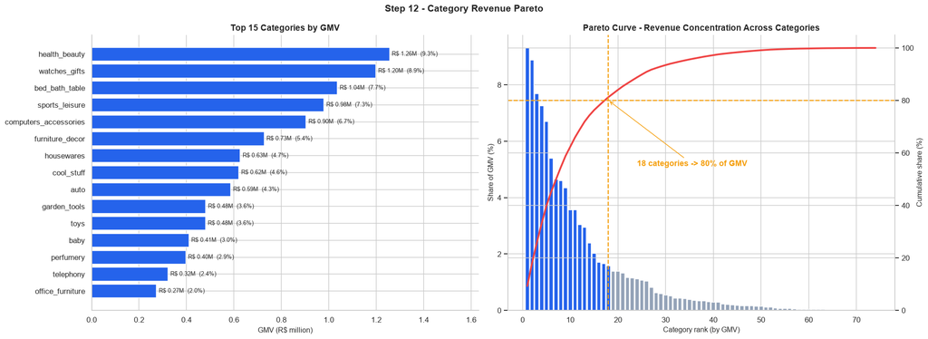

```python
conn.executescript("""
DROP VIEW IF EXISTS vw_item_master;
CREATE VIEW vw_item_master AS
SELECT oi.order_id, oi.order_item_id, oi.product_id, oi.seller_id,
       COALESCE(t.product_category_name_english, p.product_category_name, 'unknown') AS category,
       oi.price, oi.freight_value,
       s.seller_state,
       o.customer_state, o.purchase_ts, o.purchase_month, o.order_status, o.is_valid_order,
       o.delivery_days, o.delay_days, o.is_late, o.review_score
FROM order_items oi
JOIN vw_order_master o           ON o.order_id = oi.order_id
LEFT JOIN products p             ON p.product_id = oi.product_id
LEFT JOIN category_translation t ON t.product_category_name = p.product_category_name
LEFT JOIN sellers s              ON s.seller_id = oi.seller_id;
""")
assert q("SELECT COUNT(*) n FROM vw_item_master").n[0] == len(tables["order_items"]), "vw_item_master grain broken"

cat = q("""
    WITH c AS (
        SELECT category, COUNT(DISTINCT order_id) AS orders, COUNT(*) AS items,
               SUM(price) AS gmv, AVG(price) AS avg_price
        FROM vw_item_master WHERE is_valid_order = 1
        GROUP BY category
    )
    SELECT category, orders, items, ROUND(gmv, 2) AS gmv, ROUND(avg_price, 2) AS avg_price,
           ROUND(100.0 * gmv / SUM(gmv) OVER (), 2) AS share_pct,
           ROUND(100.0 * SUM(gmv) OVER (ORDER BY gmv DESC ROWS BETWEEN UNBOUNDED PRECEDING AND CURRENT ROW)
                 / SUM(gmv) OVER (), 2) AS cum_share_pct,
           RANK() OVER (ORDER BY gmv DESC) AS rnk
    FROM c
    ORDER BY gmv DESC
""")
display(cat.head(15))

n_cat = len(cat)
n80 = int((cat["cum_share_pct"] < 80).sum() + 1)
print(f"{n_cat} categories | top 5 = {cat.share_pct.head(5).sum():.1f}% of GMV | top 10 = {cat.share_pct.head(10).sum():.1f}% | "
      f"{n80} categories ({n80/n_cat:.0%} of catalogue) reach 80% of GMV")

fig, axes = plt.subplots(1, 2, figsize=(19, 7))
top = cat.head(15).iloc[::-1]
axes[0].barh(top["category"], top["gmv"] / 1e6, color=BLUE, edgecolor="white")
for y, (v, s) in enumerate(zip(top["gmv"], top["share_pct"])):
    axes[0].text(v / 1e6 + 0.01, y, f"R$ {v/1e6:.2f}M  ({s:.1f}%)", va="center", fontsize=8.5)
axes[0].set_xlim(0, top["gmv"].max() / 1e6 * 1.3); axes[0].set_xlabel("GMV (R$ million)"); axes[0].set_title("Top 15 Categories by GMV")

xr = np.arange(1, n_cat + 1)
axes[1].bar(xr, cat["share_pct"], color=[BLUE if r <= n80 else GRAY for r in xr], edgecolor="white")
axes[1].set_ylabel("Share of GMV (%)"); axes[1].set_xlabel("Category rank (by GMV)")
ax2 = axes[1].twinx(); ax2.plot(xr, cat["cum_share_pct"], color=RED, lw=2.6)
ax2.axhline(80, color=ORANGE, ls="--", lw=1.6); ax2.axvline(n80, color=ORANGE, ls="--", lw=1.6)
ax2.set_ylim(0, 105); ax2.set_ylabel("Cumulative share (%)"); ax2.spines["right"].set_visible(True)
ax2.annotate(f"{n80} categories -> 80% of GMV", xy=(n80, 80), xytext=(n80 + 6, 55), fontweight="bold", color=ORANGE,
             arrowprops=dict(arrowstyle="->", color=ORANGE))
axes[1].set_title("Pareto Curve - Revenue Concentration Across Categories")
plt.suptitle("Step 12 - Category Revenue Pareto", fontsize=14, fontweight="bold")
plt.tight_layout(); plt.show()
```

**📌 Observation:** GMV is **concentrated in a head of categories**. The leaders are `health_beauty` (R$ 1.26 M, 9.3 %), `watches_gifts` (R$ 1.20 M, 8.9 %), `bed_bath_table` (R$ 1.04 M, 7.7 %), `sports_leisure` and `computers_accessories`; together the **top 5 = 39.8 % and the top 10 = 62.4 % of GMV**. The Pareto curve crosses 80 % at **18 of 74 categories (24 % of the catalogue)**, after which the grey bars form a long tail of small categories (ranks 19-74). **Revenue rank is not volume rank**: `bed_bath_table` has the most orders (9,399) but is 3rd in GMV because its average price is R$ 93, whereas `watches_gifts` has only 5,604 orders yet ranks 2nd thanks to an average price of R$ 201. `telephony` has 4,183 orders but a R$ 71 average price and ranks only 14th.

**💡 Pipeline / Engineering decision:** `vw_item_master` is the second certified layer (item grain, asserted equal to the `order_items` row count), and unmapped categories stay as `'unknown'` via `COALESCE()`. Category dashboards show the **top-15 + "Other"** so the chart stays readable, and forecasting / assortment effort is focused on the **18 head categories that carry 80 % of GMV**. Category metrics are reported as **GMV, orders and average price together**, because ranking by any one of them tells a different story.

## Step 13 — Category Quality Matrix (Revenue vs Customer Satisfaction)

**Why:** Revenue alone hides risk. Plotting each category's **GMV against its average review score** (bubble size = volume, colour = late-delivery rate) reveals categories that are big *and* unhappy — the ones most likely to hurt brand and repeat business.

**Business insight:** A high-GMV, low-rating category is a ticking time bomb: it drives returns, refunds and negative word-of-mouth at scale. Marketplace teams run exactly this "revenue vs quality" quadrant when deciding where to intervene on seller quality.

```
Platform average review (item-weighted): 4.04 | categories analysed: 53 (>= 100 items)
High-GMV categories below platform average: 8  ->  37.8% of analysed GMV
```

|  | category | items | gmv | avg_review | late_pct |
| --- | --- | --- | --- | --- | --- |
| 52 | watches_gifts | 5920 | 1,189,934.36 | 4.03 | 7.07 |
| 6 | bed_bath_table | 10964 | 1,025,167.76 | 3.90 | 6.89 |
| 11 | computers_accessories | 7738 | 899,478.77 | 3.95 | 6.36 |
| 28 | furniture_decor | 8215 | 721,186.90 | 3.92 | 6.92 |
| 5 | baby | 3018 | 406,911.48 | 4.03 | 7.54 |
| 49 | telephony | 4496 | 318,652.11 | 3.95 | 6.90 |
| 42 | office_furniture | 1676 | 270,696.03 | 3.49 | 7.92 |
| 51 | unknown | 1575 | 177,322.79 | 3.86 | 7.48 |

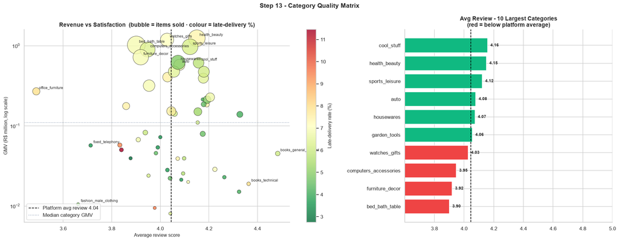

```python
MIN_ITEMS = 100
cq = q("""
    SELECT category, COUNT(*) AS items, SUM(price) AS gmv, AVG(price) AS avg_price,
           AVG(review_score) AS avg_review, 100.0 * AVG(is_late) AS late_pct
    FROM vw_item_master
    WHERE is_valid_order = 1 AND review_score IS NOT NULL
    GROUP BY category
    HAVING COUNT(*) >= :n
""", {"n": MIN_ITEMS})

platform_review = q("SELECT AVG(review_score) AS r FROM vw_item_master WHERE is_valid_order = 1 AND review_score IS NOT NULL").r[0]
gmv_median = cq["gmv"].median()
cq["risk_flag"] = (cq["gmv"] >= gmv_median) & (cq["avg_review"] < platform_review)
risk = cq[cq["risk_flag"]].sort_values("gmv", ascending=False)
print(f"Platform average review (item-weighted): {platform_review:.2f} | categories analysed: {len(cq)} (>= {MIN_ITEMS} items)")
print(f"High-GMV categories below platform average: {len(risk)}  ->  {risk.gmv.sum() / cq.gmv.sum():.1%} of analysed GMV")
display(risk[["category", "items", "gmv", "avg_review", "late_pct"]].round(2))

fig, axes = plt.subplots(1, 2, figsize=(19, 7.5), gridspec_kw={"width_ratios": [1.6, 1]})
sc = axes[0].scatter(cq["avg_review"], cq["gmv"] / 1e6, s=cq["items"] / cq["items"].max() * 1500 + 30, c=cq["late_pct"],
                     cmap="RdYlGn_r", alpha=0.8, edgecolor="black", linewidth=0.6)
axes[0].set_yscale("log")
axes[0].axvline(platform_review, color="black", ls="--", lw=1.3, label=f"Platform avg review {platform_review:.2f}")
axes[0].axhline(gmv_median / 1e6, color=GRAY, ls=":", lw=1.3, label="Median category GMV")
lab = pd.concat([cq.nlargest(9, "gmv"), cq.nsmallest(3, "avg_review"), cq.nlargest(2, "avg_review")]).drop_duplicates("category")
for _, r in lab.iterrows():
    axes[0].annotate(r["category"], (r["avg_review"], r["gmv"] / 1e6), xytext=(6, 5), textcoords="offset points", fontsize=8)
axes[0].set_xlabel("Average review score"); axes[0].set_ylabel("GMV (R$ million, log scale)")
axes[0].set_title("Revenue vs Satisfaction  (bubble = items sold · colour = late-delivery %)")
axes[0].legend(loc="lower left"); plt.colorbar(sc, ax=axes[0], label="Late-delivery rate (%)")

t10 = cq.nlargest(10, "gmv").sort_values("avg_review")
axes[1].barh(t10["category"], t10["avg_review"], color=[RED if v < platform_review else GREEN for v in t10["avg_review"]], edgecolor="white")
axes[1].axvline(platform_review, color="black", ls="--", lw=1.3)
for y, v in enumerate(t10["avg_review"]):
    axes[1].text(v + 0.02, y, f"{v:.2f}", va="center", fontsize=9, fontweight="bold")
axes[1].set_xlim(max(3, t10["avg_review"].min() - 0.3), 5); axes[1].set_title("Avg Review - 10 Largest Categories\n(red = below platform average)")
plt.suptitle("Step 13 - Category Quality Matrix", fontsize=14, fontweight="bold")
plt.tight_layout(); plt.show()
```

**📌 Observation:** The platform average review is **4.04 (item-weighted)** across 53 categories with ≥ 100 items. **8 high-GMV categories fall below it, covering 37.8 % of analysed GMV**: `watches_gifts` (4.03), `bed_bath_table` (3.90), `computers_accessories` (3.95), `furniture_decor` (3.92), `baby` (4.03), `telephony` (3.95), `office_furniture` (**3.49 — the lowest of any large category**) and `unknown` (3.86). In the scatter, the biggest bubbles cluster just left of the dashed average line, while small categories such as `books_general_interest` (~4.5) sit to the far right. The right chart shows **4 of the 10 largest categories in red**. Importantly, the **late-delivery rate of these categories is only 6.4-7.9 %**, close to the 6.8 % platform rate — the bubbles are yellow, not red — so **lateness alone does not explain their lower ratings**. Product quality, expectation gaps or size / assembly issues are more likely causes.

**💡 Pipeline / Engineering decision:** A **`risk_flag`** (GMV ≥ median category GMV *and* review < platform average) is added to `mart_category` and printed as a watch-list, with a **minimum-volume filter of ≥ 100 items** so thin categories with noisy averages do not trigger false alarms. Because delivery is not the driver, the flagged categories are routed to **product-quality / listing-content review** (and to the Portuguese comment analysis proposed in Step 20), not to a logistics fix. The 3.49 for `office_furniture` gets first priority: it combines high GMV (R$ 0.27 M) with the worst rating.

## Step 14 — Price and Freight Distributions

**Why:** Price and freight are the two money columns behind GMV. Their **distribution shape** (skew, tails, outliers) decides which summary statistic is honest (mean vs median), whether to log-transform for modelling, and whether outliers are errors or genuine high-ticket products.

**Business insight:** Freight is the customer's hidden cost. When shipping is a large fraction of the item price, conversion drops and cancellations rise — so the **freight-to-price ratio** is often more decision-relevant than either number alone.

|  | mean | median | p90 | p99 | max | skew | kurtosis | IQR_outlier_% |
| --- | --- | --- | --- | --- | --- | --- | --- | --- |
| price | 120.38 | 74.90 | 229.00 | 889.00 | 6,735.00 | 7.95 | 122.63 | 7.45 |
| freight_value | 19.99 | 16.27 | 34.04 | 84.44 | 409.68 | 5.65 | 60.08 | 10.76 |
| freight_ratio | 0.32 | 0.23 | 0.64 | 1.55 | 26.24 | 11.64 | 553.67 | 6.52 |

```
Items where freight > item price : 3.7%
```

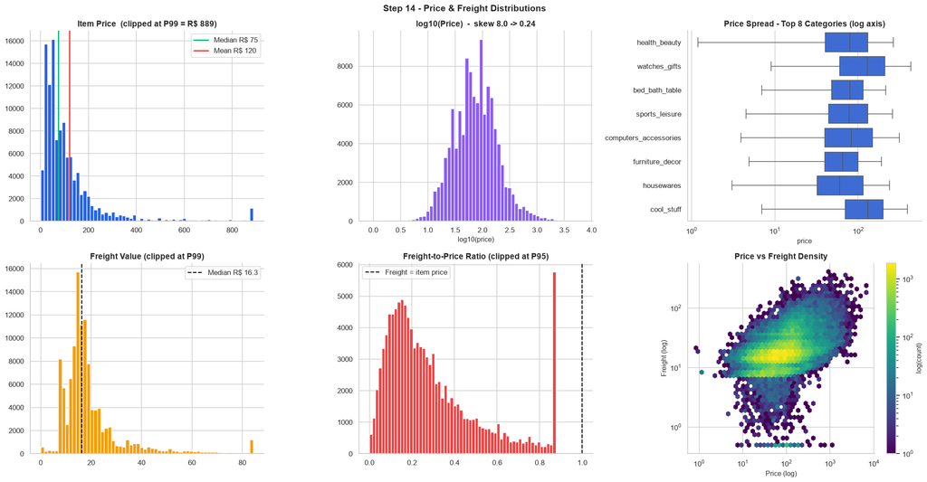

```python
items_df = q("""
    SELECT category, price, freight_value, freight_value * 1.0 / NULLIF(price, 0) AS freight_ratio
    FROM vw_item_master WHERE is_valid_order = 1 AND price > 0
""")

def describe(s):
    q1, q3 = s.quantile([.25, .75]); iqr = q3 - q1
    out = ((s < q1 - 1.5 * iqr) | (s > q3 + 1.5 * iqr)).mean() * 100
    return pd.Series({"mean": s.mean(), "median": s.median(), "p90": s.quantile(.9), "p99": s.quantile(.99), "max": s.max(),
                      "skew": s.skew(), "kurtosis": s.kurtosis(), "IQR_outlier_%": out})
stats_tbl = pd.DataFrame({c: describe(items_df[c]) for c in ["price", "freight_value", "freight_ratio"]}).T
display(stats_tbl)
print(f"Items where freight > item price : {(items_df.freight_ratio > 1).mean():.1%}")

p99 = items_df["price"].quantile(0.99)
top_cats = q("SELECT category FROM vw_item_master WHERE is_valid_order = 1 GROUP BY category ORDER BY SUM(price) DESC LIMIT 8")["category"].tolist()

fig, axes = plt.subplots(2, 3, figsize=(20, 10.5))
axes[0, 0].hist(items_df["price"].clip(upper=p99), bins=60, color=BLUE, edgecolor="white")
axes[0, 0].axvline(items_df.price.median(), color=GREEN, lw=2, label=f"Median R$ {items_df.price.median():.0f}")
axes[0, 0].axvline(items_df.price.mean(), color=RED, lw=2, label=f"Mean R$ {items_df.price.mean():.0f}")
axes[0, 0].set_title(f"Item Price  (clipped at P99 = R$ {p99:,.0f})"); axes[0, 0].legend()

axes[0, 1].hist(np.log10(items_df["price"]), bins=60, color=PURPLE, edgecolor="white")
axes[0, 1].set_title(f"log10(Price)  -  skew {items_df.price.skew():.1f} -> {np.log10(items_df.price).skew():.2f}")
axes[0, 1].set_xlabel("log10(price)")

sns.boxplot(data=items_df[items_df.category.isin(top_cats)], x="price", y="category", order=top_cats, ax=axes[0, 2],
            color=BLUE, showfliers=False, fliersize=2)
axes[0, 2].set_xscale("log"); axes[0, 2].set_title("Price Spread - Top 8 Categories (log axis)"); axes[0, 2].set_ylabel("")

axes[1, 0].hist(items_df["freight_value"].clip(upper=items_df["freight_value"].quantile(.99)), bins=60, color=ORANGE, edgecolor="white")
axes[1, 0].axvline(items_df.freight_value.median(), color="black", ls="--", label=f"Median R$ {items_df.freight_value.median():.1f}")
axes[1, 0].set_title("Freight Value (clipped at P99)"); axes[1, 0].legend()

axes[1, 1].hist(items_df["freight_ratio"].clip(upper=items_df["freight_ratio"].quantile(.95)), bins=60, color=RED, edgecolor="white")
axes[1, 1].axvline(1, color="black", ls="--", label="Freight = item price"); axes[1, 1].legend()
axes[1, 1].set_title("Freight-to-Price Ratio (clipped at P95)")

hb = axes[1, 2].hexbin(items_df["price"], items_df["freight_value"].clip(lower=0.5), gridsize=45, xscale="log", yscale="log", cmap="viridis", mincnt=1, bins="log")
plt.colorbar(hb, ax=axes[1, 2], label="log(count)"); axes[1, 2].set_xlabel("Price (log)"); axes[1, 2].set_ylabel("Freight (log)")
axes[1, 2].set_title("Price vs Freight Density")
plt.suptitle("Step 14 - Price & Freight Distributions", fontsize=14, fontweight="bold")
plt.tight_layout(); plt.show()
```

**📌 Observation:** Price is **severely right-skewed**: median **R$ 74.9** vs mean **R$ 120.4**, P99 R$ 889, maximum R$ 6,735, **skewness 7.95** and 7.5 % of items outside the IQR fences. After `log10` the histogram becomes nearly symmetric (**skew 8.0 → 0.24**), and the box-plots show most top categories share a similar median (~R$ 60-130) with `watches_gifts` and `cool_stuff` shifted higher. Freight is also skewed (median **R$ 16.3**, mean R$ 20.0, P99 R$ 84.4, skew 5.65) with distinct** spikes near R$ 8 and R$ 16**, which look like standard shipping tariff bands. The freight-to-price ratio has a** median of 0.23 but a mean of 0.32 **and a P99 of 1.55;** 3.7 % of items have freight above the item price **(right of the dashed line, ratio kurtosis 554). In the hexbin, freight rises only weakly with price, and a** flat streak at the bottom is free-shipping items**.

**💡 Pipeline / Engineering decision:** Reports quote **median and P90 next to the mean**, because the mean overstates the "typical" purchase by about 60 %. The log10 transform (skew 8.0 → 0.24) is the recommended transform for price in any regression or clustering feature set. High-price outliers are **kept, not removed** — they are genuine premium products and real revenue; clipping (P99 / P95) is applied for plotting only. `freight_ratio` and a **`freight_heavy` flag (ratio > 0.5)** are added to `mart_orders`, and the 3.7 % of freight-exceeds-price items become a candidate feature for cancellation and CSAT analysis.

## Step 15 — Payment Behaviour

**Why:** How customers pay shapes conversion, cash-flow and risk. We analyse the **payment-method mix**, **credit-card instalment usage** and **average ticket by method**, using the order-level `main_payment_type` (the instrument carrying the largest share of the order) so multi-payment orders aren't double-counted.

**Business insight:** In Brazil (as in India) instalments — EMI / "no-cost EMI" — are a conversion lever for expensive baskets, while cash-like methods (boleto ≈ UPI/COD in India) mean slower settlement and higher abandonment. Finance and growth teams both need this view.

|  | payment_type | orders | value | avg_ticket | orders_pct | value_pct |
| --- | --- | --- | --- | --- | --- | --- |
| 0 | credit_card | 74116 | 12,350,903.30 | 166.64 | 75.47 | 78.47 |
| 1 | boleto | 19539 | 2,826,802.30 | 144.67 | 19.90 | 17.96 |
| 2 | voucher | 3037 | 349,063.66 | 114.94 | 3.09 | 2.22 |
| 3 | debit_card | 1514 | 212,367.75 | 140.27 | 1.54 | 1.35 |

```
Orders paid with more than one payment row: 3.0%
Credit-card payments in a single instalment: 33.2%  |  in 6+ instalments: 20.8%
```

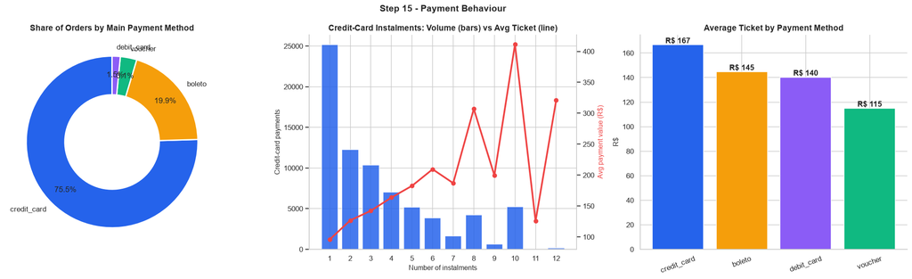

```python
pay_mix = q("""
    SELECT main_payment_type AS payment_type, COUNT(*) AS orders,
           SUM(payment_value) AS value, AVG(payment_value) AS avg_ticket
    FROM vw_order_master
    WHERE is_valid_order = 1 AND main_payment_type IS NOT NULL
    GROUP BY 1 ORDER BY orders DESC
""")
pay_mix["orders_pct"] = pay_mix["orders"] / pay_mix["orders"].sum() * 100
pay_mix["value_pct"]  = pay_mix["value"]  / pay_mix["value"].sum()  * 100
display(pay_mix)

inst = q("""
    SELECT p.payment_installments AS installments, COUNT(*) AS payments, AVG(p.payment_value) AS avg_value
    FROM order_payments p
    JOIN vw_order_master o ON o.order_id = p.order_id AND o.is_valid_order = 1
    WHERE p.payment_type = 'credit_card' AND p.payment_installments BETWEEN 1 AND 12
    GROUP BY 1 ORDER BY 1
""")
inst["pct"] = inst["payments"] / inst["payments"].sum() * 100
multi = q("SELECT 100.0 * AVG(n_payment_rows > 1) AS pct FROM vw_order_master WHERE n_payment_rows IS NOT NULL").pct[0]
print(f"Orders paid with more than one payment row: {multi:.1f}%")
print(f"Credit-card payments in a single instalment: {inst.pct.iloc[0]:.1f}%  |  in 6+ instalments: {inst[inst.installments >= 6].pct.sum():.1f}%")

pal = {"credit_card": BLUE, "boleto": ORANGE, "voucher": GREEN, "debit_card": PURPLE, "not_defined": GRAY}
fig, axes = plt.subplots(1, 3, figsize=(20, 6))
axes[0].pie(pay_mix["orders"], labels=pay_mix["payment_type"], colors=[pal.get(p, GRAY) for p in pay_mix["payment_type"]],
            autopct=lambda p: f"{p:.1f}%" if p > 1.5 else "", startangle=90, pctdistance=0.78,
            wedgeprops=dict(width=0.45, edgecolor="white", linewidth=2))
axes[0].set_title("Share of Orders by Main Payment Method")

axes[1].bar(inst["installments"].astype(str), inst["payments"], color=BLUE, edgecolor="white", alpha=0.85)
axes[1].set_xlabel("Number of instalments"); axes[1].set_ylabel("Credit-card payments")
ax_b = axes[1].twinx(); ax_b.plot(inst["installments"].astype(str), inst["avg_value"], color=RED, lw=2.6, marker="o")
ax_b.set_ylabel("Avg payment value (R$)", color=RED); ax_b.spines["right"].set_visible(True); ax_b.grid(False)
axes[1].set_title("Credit-Card Instalments: Volume (bars) vs Avg Ticket (line)")

pm = pay_mix.sort_values("avg_ticket", ascending=False)
axes[2].bar(pm["payment_type"], pm["avg_ticket"], color=[pal.get(p, GRAY) for p in pm["payment_type"]], edgecolor="white")
for i, v in enumerate(pm["avg_ticket"]):
    axes[2].text(i, v, f"R$ {v:,.0f}", ha="center", va="bottom", fontweight="bold")
axes[2].set_title("Average Ticket by Payment Method"); axes[2].tick_params(axis="x", rotation=20); axes[2].set_ylabel("R$")
plt.suptitle("Step 15 - Payment Behaviour", fontsize=14, fontweight="bold")
plt.tight_layout(); plt.show()
```

**📌 Observation:** **Credit card dominates: 75.5 % of orders (74,116) and 78.5 % of value (R$ 12.35 M)**, followed by **boleto at 19.9 % of orders (18 % of value)**; vouchers (3.1 %) and debit cards (1.5 %) are marginal, and 3.0 % of orders are split across more than one payment row. Average ticket ranks credit card **R$ 167** > boleto R$ 145 > debit R$ 140 > voucher R$ 115. In the instalment chart **33.2 % of card payments are single-instalment (~25 k payments)**, volume falls quickly with more instalments, and **20.8 % use 6 or more**; the red line shows average payment value rising from **≈ R$ 95 at 1× to ≈ R$ 210 at 6×**, with noisy peaks at 8× (~R$ 305) and 10× (~R$ 410) — the 10× bar (~5 k payments) is a visible bump. Instalments 9, 11 and 12 have very few payments, so their averages are unreliable.

**💡 Pipeline / Engineering decision:** `main_payment_type` (largest-value instrument) and `max_installments` are stored in `vw_order_master`, so payment analysis never re-joins `order_payments` at row level. **Revenue (GMV) is defined from `items_value`; `payment_value` is used only for cash / finance views**, because payments also contain freight, vouchers and instalment interest. Instalment counts should be bucketed (1×, 2-5×, 6×+) before modelling, since 9×, 11× and 12× are too sparse for stable averages. The value / order share gap (78.5 % vs 75.5 % for card) is a reason to report both volume and value by payment method.

## Step 16 — Geographic Demand vs Supply

**Why:** A marketplace's economics are geographic: where customers are, where sellers are, and the distance between them determines freight cost and delivery time. Comparing **demand share vs seller share by state**, and linking both to **freight and delivery days**, exposes structural supply-demand imbalances.

**Business insight:** If sellers cluster in one region and customers are spread nationally, every long-distance order carries higher freight, slower delivery and more churn risk — the same "tier-2 / tier-3 city" problem Flipkart and Meesho solve with regional fulfilment hubs.

|  | state | orders | customers | gmv | avg_freight | aov | avg_delivery_days | late_pct | avg_review | orders_share | gmv_share | region | sellers | seller_share |
| --- | --- | --- | --- | --- | --- | --- | --- | --- | --- | --- | --- | --- | --- | --- |
| 0 | SP | 41127 | 39749 | 5,163,867.22 | 17.37 | 125.57 | 8.76 | 4.49 | 4.21 | 41.88 | 38.27 | Southeast | 1,822.00 | 59.68 |
| 1 | RJ | 12698 | 12242 | 1,811,623.42 | 23.95 | 142.68 | 15.31 | 12.11 | 3.90 | 12.93 | 13.43 | Southeast | 170.00 | 5.57 |
| 2 | MG | 11496 | 11134 | 1,573,508.20 | 23.45 | 136.87 | 12.01 | 4.57 | 4.16 | 11.71 | 11.66 | Southeast | 240.00 | 7.86 |
| 3 | RS | 5417 | 5234 | 742,559.78 | 24.88 | 137.13 | 15.30 | 6.08 | 4.16 | 5.52 | 5.50 | South | 129.00 | 4.23 |
| 4 | PR | 4983 | 4825 | 676,883.06 | 23.55 | 135.87 | 11.99 | 4.04 | 4.21 | 5.07 | 5.02 | South | 344.00 | 11.27 |
| 5 | SC | 3600 | 3502 | 518,578.28 | 24.85 | 144.09 | 14.95 | 8.21 | 4.10 | 3.67 | 3.84 | South | 186.00 | 6.09 |
| 6 | BA | 3344 | 3244 | 507,108.83 | 29.84 | 151.65 | 19.34 | 12.16 | 3.88 | 3.41 | 3.76 | Northeast | 19.00 | 0.62 |
| 7 | DF | 2121 | 2058 | 300,886.45 | 23.79 | 141.93 | 12.97 | 5.67 | 4.09 | 2.16 | 2.23 | Central-West | 30.00 | 0.98 |
| 8 | GO | 1998 | 1934 | 287,870.46 | 26.36 | 144.08 | 15.61 | 6.54 | 4.07 | 2.03 | 2.13 | Central-West | 40.00 | 1.31 |
| 9 | ES | 2018 | 1950 | 273,532.13 | 24.55 | 135.55 | 15.79 | 10.73 | 4.05 | 2.05 | 2.03 | Southeast | 23.00 | 0.75 |

```
Regional roll-up:
```

| region | orders_share_% | gmv_share_% | avg_freight | avg_delivery_days | late_% |
| --- | --- | --- | --- | --- | --- |
| Southeast | 68.60 | 65.40 | 19.90 | 10.80 | 6.10 |
| South | 14.30 | 14.40 | 24.40 | 14.00 | 5.90 |
| Northeast | 9.50 | 11.40 | 35.90 | 20.00 | 12.70 |
| Central-West | 5.80 | 6.40 | 26.50 | 15.00 | 6.50 |
| North | 1.90 | 2.50 | 41.40 | 22.60 | 8.60 |

```
Top-3 states by orders = 66.5% of demand | top seller state supply = 59.7% of sellers
```

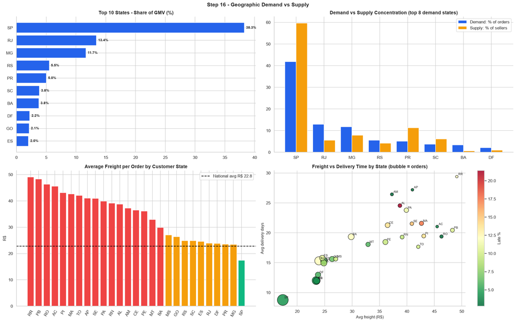

```python
REGION = {**{s: "Southeast" for s in ["SP", "RJ", "MG", "ES"]}, **{s: "South" for s in ["PR", "SC", "RS"]},
          **{s: "Central-West" for s in ["DF", "GO", "MT", "MS"]},
          **{s: "Northeast" for s in ["BA", "PE", "CE", "MA", "PB", "RN", "AL", "SE", "PI"]},
          **{s: "North" for s in ["AM", "PA", "TO", "RO", "AC", "AP", "RR"]}}

geo = q("""
    SELECT customer_state AS state, COUNT(*) AS orders, COUNT(DISTINCT customer_unique_id) AS customers,
           SUM(items_value) AS gmv, AVG(freight_value) AS avg_freight, AVG(items_value) AS aov,
           AVG(delivery_days) AS avg_delivery_days, 100.0 * AVG(is_late) AS late_pct, AVG(review_score) AS avg_review
    FROM vw_order_master
    WHERE is_valid_order = 1
    GROUP BY customer_state
    ORDER BY gmv DESC
""")
geo["orders_share"] = geo["orders"] / geo["orders"].sum() * 100
geo["gmv_share"]    = geo["gmv"]    / geo["gmv"].sum()    * 100
geo["region"] = geo["state"].map(REGION)

sell = q("SELECT seller_state AS state, COUNT(DISTINCT seller_id) AS sellers FROM vw_item_master WHERE is_valid_order = 1 GROUP BY 1")
sell["seller_share"] = sell["sellers"] / sell["sellers"].sum() * 100
geo = geo.merge(sell, on="state", how="left").fillna({"sellers": 0, "seller_share": 0})
display(geo.head(10).round(2))

reg = (geo.assign(w=geo["orders"]).groupby("region")
          .apply(lambda d: pd.Series({"orders_share_%": d["orders_share"].sum(), "gmv_share_%": d["gmv_share"].sum(),
                                      "avg_freight": np.average(d["avg_freight"].fillna(0), weights=d["w"]),
                                      "avg_delivery_days": np.average(d["avg_delivery_days"].fillna(0), weights=d["w"]),
                                      "late_%": np.average(d["late_pct"].fillna(0), weights=d["w"])}))
          .sort_values("orders_share_%", ascending=False))
print("Regional roll-up:"); display(reg.round(1))
print(f"Top-3 states by orders = {geo.orders_share.head(3).sum():.1f}% of demand | top seller state supply = {geo.seller_share.max():.1f}% of sellers")

fig, axes = plt.subplots(2, 2, figsize=(19, 12))
t10 = geo.head(10).iloc[::-1]
axes[0, 0].barh(t10["state"], t10["gmv_share"], color=BLUE, edgecolor="white")
for y, v in enumerate(t10["gmv_share"]): axes[0, 0].text(v + 0.3, y, f"{v:.1f}%", va="center", fontsize=9, fontweight="bold")
axes[0, 0].set_title("Top 10 States - Share of GMV (%)")

t8 = geo.head(8); xx = np.arange(len(t8)); w = 0.4
axes[0, 1].bar(xx - w / 2, t8["orders_share"], w, color=BLUE, label="Demand: % of orders", edgecolor="white")
axes[0, 1].bar(xx + w / 2, t8["seller_share"], w, color=ORANGE, label="Supply: % of sellers", edgecolor="white")
axes[0, 1].set_xticks(xx); axes[0, 1].set_xticklabels(t8["state"]); axes[0, 1].legend(); axes[0, 1].set_title("Demand vs Supply Concentration (top 8 demand states)")

gf = geo.dropna(subset=["avg_freight"]).sort_values("avg_freight", ascending=False)
nat = q("SELECT AVG(freight_value) v FROM vw_order_master WHERE is_valid_order = 1").v[0]
axes[1, 0].bar(gf["state"], gf["avg_freight"], color=[RED if v > nat * 1.3 else GREEN if v < nat * 0.9 else ORANGE for v in gf["avg_freight"]], edgecolor="white")
axes[1, 0].axhline(nat, color="black", ls="--", label=f"National avg R$ {nat:.1f}"); axes[1, 0].legend()
axes[1, 0].set_title("Average Freight per Order by Customer State"); axes[1, 0].set_ylabel("R$"); axes[1, 0].tick_params(axis="x", rotation=60)

gg = geo.dropna(subset=["avg_freight", "avg_delivery_days"])
sc = axes[1, 1].scatter(gg["avg_freight"], gg["avg_delivery_days"], s=np.sqrt(gg["orders"]) * 4 + 20, c=gg["late_pct"], cmap="RdYlGn_r", edgecolor="black", alpha=0.85)
for _, r in gg.iterrows(): axes[1, 1].annotate(r["state"], (r["avg_freight"], r["avg_delivery_days"]), xytext=(4, 4), textcoords="offset points", fontsize=8)
plt.colorbar(sc, ax=axes[1, 1], label="Late %")
axes[1, 1].set_xlabel("Avg freight (R$)"); axes[1, 1].set_ylabel("Avg delivery days"); axes[1, 1].set_title("Freight vs Delivery Time by State (bubble = orders)")
plt.suptitle("Step 16 - Geographic Demand vs Supply", fontsize=14, fontweight="bold")
plt.tight_layout(); plt.show()
```

**📌 Observation:** Demand is heavily centralised: **São Paulo alone is 41.9 % of orders and 38.3 % of GMV**, and SP + RJ + MG = **66.5 % of orders**. Supply is even more concentrated: **59.7 % of sellers are in SP**, versus 41.9 % of demand. The demand-vs-supply chart shows only SP, PR (11.3 % of sellers vs 5.1 % of demand) and SC have more supply than demand, while **RJ (12.9 % of orders vs 5.6 % of sellers), MG (11.7 % vs 7.9 %) and BA (3.3 % vs 0.6 %)** are under-served. Distance shows up in freight and time: SP customers pay **R$ 17.4** average freight and wait **8.8 days**, versus the national average freight of R$ 22.8; the **regional roll-up** goes Southeast R$ 19.9 / 10.8 days, South R$ 24.4 / 14.0, Northeast **R$ 35.9 / 20.0 days / 12.7 % late **and North** R$ 41.4 / 22.6 days**. The extremes are RR (freight ≈ R$ 49, ~29 days) and AM / AP (~26-27 days). One outlier in the scatter is **RJ**: the 2nd-largest state has 15.3 delivery days and **12.1 % late**, unlike its neighbours SP (4.5 %) and MG (4.6 %). In the freight bar chart 17 states (red) pay about R$ 30 or more, and only SP sits below the R$ 22.8 national-average line.

**💡 Pipeline / Engineering decision:** Geography is modelled at **state (UF) grain with a 5-region roll-up**; city level would be too sparse. State-level freight and late rate are available for the mart. Business actions from the data: (1) **RJ is the first candidate** for a regional fulfilment hub or seller-recruitment drive — large demand, little local supply and poor delivery; (2) **North / Northeast** get a freight-subsidy or free-shipping-threshold test, since freight there is ~1.8-2.1× the Southeast; (3) `geolocation` remains de-duplicated (one centroid per zip prefix) and is reserved for optional map visuals.

## Step 17 — Delivery SLA Performance

**Why:** Delivery is the promise a marketplace makes at checkout. We compare **actual delivery days vs the promised (estimated) days**, measure the on-time rate, and break lateness down **by state and by month**. Only `delivered` orders are used because in-transit orders have no outcome yet.

**Business insight:** On-time delivery is the most-watched operational KPI in e-commerce logistics. But an on-time rate alone can be gamed by padding the promise — so we also look at the *actual* speed distribution (median, P90/P95).

|  | mean | 50% | 90% | 95% | max |
| --- | --- | --- | --- | --- | --- |
| actual_days | 12.60 | 10.20 | 23.10 | 29.30 | 209.60 |
| promised_days | 23.70 | 23.20 | 34.30 | 38.40 | 155.10 |

```
On-time rate : 93.2%   |   Late rate: 6.8%
Median promise buffer (promised - actual): 11.9 days
```

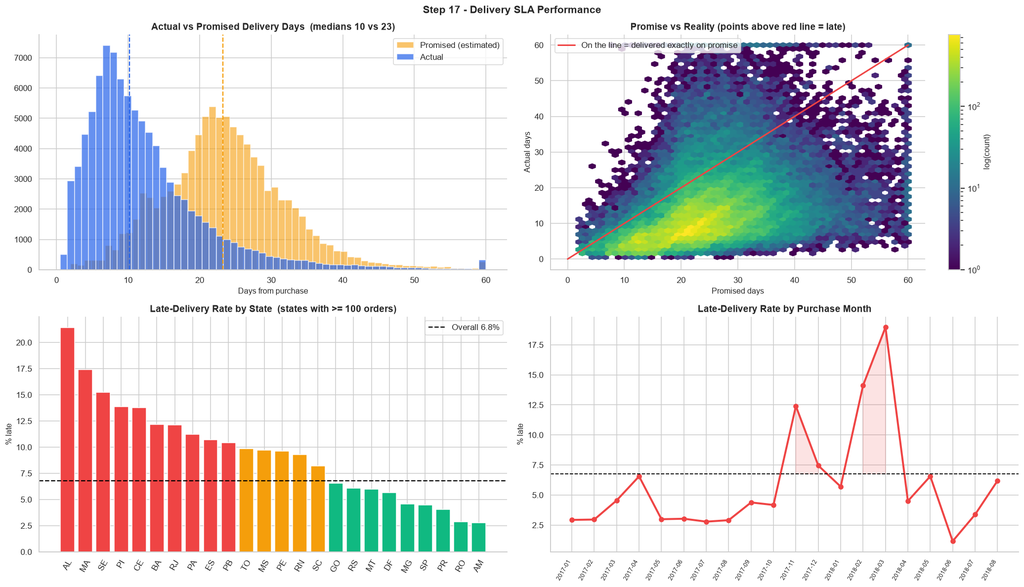

```python
sla = q("""
    SELECT order_id, customer_state, purchase_month, delivery_days, estimated_days, delay_days, is_late
    FROM vw_order_master
    WHERE order_status = 'delivered' AND delivery_days IS NOT NULL
""")

summary = pd.DataFrame({
    "actual_days":    sla["delivery_days"].describe(percentiles=[.5, .9, .95]),
    "promised_days":  sla["estimated_days"].describe(percentiles=[.5, .9, .95]),
})
display(summary.T[["mean", "50%", "90%", "95%", "max"]].round(1))
print(f"On-time rate : {(1 - sla.is_late.mean()) * 100:.1f}%   |   Late rate: {sla.is_late.mean() * 100:.1f}%")
print(f"Median promise buffer (promised - actual): {(sla.estimated_days - sla.delivery_days).median():.1f} days")

late_state = (sla.groupby("customer_state").agg(orders=("order_id", "count"), late_pct=("is_late", lambda s: s.mean() * 100))
                 .query("orders >= 100").sort_values("late_pct", ascending=False))
late_month = (sla[sla.purchase_month.between(WINDOW_START, WINDOW_END)].groupby("purchase_month")
                 .agg(orders=("order_id", "count"), late_pct=("is_late", lambda s: s.mean() * 100)).reset_index())
overall_late = sla.is_late.mean() * 100

fig, axes = plt.subplots(2, 2, figsize=(19, 11))
clip = 60
axes[0, 0].hist(sla["estimated_days"].clip(upper=clip), bins=60, alpha=0.6, color=ORANGE, label="Promised (estimated)")
axes[0, 0].hist(sla["delivery_days"].clip(upper=clip), bins=60, alpha=0.7, color=BLUE, label="Actual")
axes[0, 0].axvline(sla.estimated_days.median(), color=ORANGE, ls="--"); axes[0, 0].axvline(sla.delivery_days.median(), color=BLUE, ls="--")
axes[0, 0].set_title(f"Actual vs Promised Delivery Days  (medians {sla.delivery_days.median():.0f} vs {sla.estimated_days.median():.0f})")
axes[0, 0].set_xlabel("Days from purchase"); axes[0, 0].legend()

hb = axes[0, 1].hexbin(sla["estimated_days"].clip(upper=clip), sla["delivery_days"].clip(upper=clip), gridsize=50, cmap="viridis", mincnt=1, bins="log")
axes[0, 1].plot([0, clip], [0, clip], color=RED, lw=2, label="On the line = delivered exactly on promise")
axes[0, 1].set_xlabel("Promised days"); axes[0, 1].set_ylabel("Actual days"); axes[0, 1].legend(loc="upper left")
axes[0, 1].set_title("Promise vs Reality (points above red line = late)"); plt.colorbar(hb, ax=axes[0, 1], label="log(count)")

axes[1, 0].bar(late_state.index, late_state["late_pct"], color=[RED if v > overall_late * 1.5 else ORANGE if v > overall_late else GREEN for v in late_state["late_pct"]], edgecolor="white")
axes[1, 0].axhline(overall_late, color="black", ls="--", label=f"Overall {overall_late:.1f}%"); axes[1, 0].legend()
axes[1, 0].set_title("Late-Delivery Rate by State  (states with >= 100 orders)"); axes[1, 0].set_ylabel("% late"); axes[1, 0].tick_params(axis="x", rotation=60)

axes[1, 1].plot(late_month["purchase_month"], late_month["late_pct"], color=RED, lw=2.6, marker="o")
axes[1, 1].axhline(overall_late, color="black", ls="--", lw=1.2)
axes[1, 1].fill_between(range(len(late_month)), late_month["late_pct"], overall_late, where=late_month["late_pct"] > overall_late, color=RED, alpha=0.15)
axes[1, 1].set_xticks(range(len(late_month))); axes[1, 1].set_xticklabels(late_month["purchase_month"], rotation=60, ha="right", fontsize=8)
axes[1, 1].set_title("Late-Delivery Rate by Purchase Month"); axes[1, 1].set_ylabel("% late")
plt.suptitle("Step 17 - Delivery SLA Performance", fontsize=14, fontweight="bold")
plt.tight_layout(); plt.show()
```

**📌 Observation:** The delivery promise is **very padded**: the median order arrives in **10.2 days versus a median promise of 23.2 days** — a median buffer of **11.9 days** — and the hexbin cloud sits well below the red "on-promise" diagonal. Even so, **6.8 % of orders (on-time rate 93.2 %) arrive late**, and the tail is long (P95 = 29.3 days, maximum 209.6). Lateness is uneven by state: **AL 21.4 %, MA 17.4 %, SE 15.2 %, PI ≈ 13.8 %, CE ≈ 13.7 %**, and 10 states in total exceed ~10 %, including **BA (12.2 %) and RJ (12.1 %)** — while SP (4.5 %), PR, MG, RO and AM sit below 5 %. The monthly chart is the sharpest finding: the late rate is **2.5-6.5 % through 2017 except Nov (≈ 12.4 %) and Dec (≈ 7.4 %)**, then spikes to **≈ 14 % in Feb-2018 and ≈ 19 % in Mar-2018** before dropping back to 4.5 % in Apr and 1.2 % in Jun-2018. Failures therefore cluster in **peak-load and disruption periods**, not evenly.

**💡 Pipeline / Engineering decision:** The SLA KPI set is **on-time % vs promise + P90 delivery days**; the second metric prevents a padded promise from hiding genuinely slow logistics. `delay_days` and `is_late` are materialised in `vw_order_master` and become the **target variable for a future late-delivery prediction model**. Proposed alert rule: escalate when a state or month exceeds **1.5× the overall rate (≈ 10 %)** — this rule would flag Nov-2017, Feb-2018 and Mar-2018, and 10 states. Since the promise is ~2× the real median, a **per-state promise model** could quote shorter delivery times and lift conversion, but must be tested against the CSAT cliff shown in Step 19.

## Step 18 — Order Lifecycle Decomposition

**Why:** "Delivery is slow" is not actionable until we know **which stage** is slow. We split total lead time into three owner-specific stages: **approval** (payment / platform), **seller handling** (approval → handed to carrier), and **carrier transit** (carrier → customer). Each maps to a different team.

**Business insight:** Seller-side delay is fixable with seller SLAs and penalties; carrier-side delay needs logistics-partner management or regional hubs. Blaming the wrong owner wastes quarters.

```
Rows with an impossible negative stage duration (excluded): 1,373 of 96,455 (1.42%)
```

|  | count | mean | std | min | 50% | 90% | max |
| --- | --- | --- | --- | --- | --- | --- | --- |
| approval_days | 95,082.00 | 0.40 | 0.80 | 0.00 | 0.01 | 1.39 | 30.89 |
| seller_handling_days | 95,082.00 | 2.85 | 3.48 | 0.00 | 1.85 | 6.02 | 125.76 |
| transit_days | 95,082.00 | 9.36 | 8.77 | 0.00 | 7.11 | 18.95 | 205.19 |

| is_late | approval_days | seller_handling_days | transit_days |
| --- | --- | --- | --- |
| On-time | 0.39 | 2.65 | 8.00 |
| Late | 0.50 | 5.57 | 27.88 |

```
Transit share of total lead time (mean): 74%
```

| handling_bucket | orders | late_pct |
| --- | --- | --- |
| <=1d | 27795 | 3.90 |
| 1-2d | 22828 | 5.60 |
| 2-3d | 14141 | 5.90 |
| 3-5d | 16360 | 7.30 |
| 5-8d | 9021 | 10.10 |
| >8d | 4937 | 24.80 |

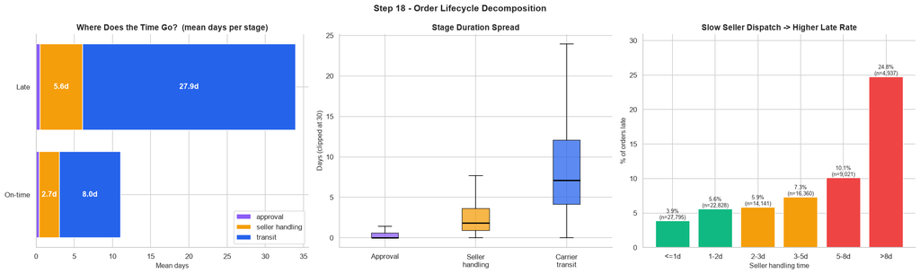

```python
life = q("""
    SELECT order_id, customer_state, is_late, review_score, delivery_days,
           JULIANDAY(order_approved_at)             - JULIANDAY(purchase_ts)                    AS approval_days,
           JULIANDAY(order_delivered_carrier_date)  - JULIANDAY(order_approved_at)              AS seller_handling_days,
           JULIANDAY(order_delivered_customer_date) - JULIANDAY(order_delivered_carrier_date)   AS transit_days
    FROM vw_order_master
    WHERE order_status = 'delivered'
      AND order_approved_at IS NOT NULL AND order_delivered_carrier_date IS NOT NULL AND order_delivered_customer_date IS NOT NULL
""")
STAGES = ["approval_days", "seller_handling_days", "transit_days"]
bad = (life[STAGES] < 0).any(axis=1)
print(f"Rows with an impossible negative stage duration (excluded): {bad.sum():,} of {len(life):,} ({bad.mean():.2%})")
life = life[~bad].copy()

grp = life.groupby("is_late")[STAGES].mean().rename(index={0: "On-time", 1: "Late"})
display(life[STAGES].describe(percentiles=[.5, .9]).T.round(2))
display(grp.round(2))
print(f"Transit share of total lead time (mean): {life.transit_days.mean() / life[STAGES].sum(axis=1).mean():.0%}")

life["handling_bucket"] = pd.cut(life["seller_handling_days"], [-0.01, 1, 2, 3, 5, 8, 1e9], labels=["<=1d", "1-2d", "2-3d", "3-5d", "5-8d", ">8d"])
late_by_handling = life.groupby("handling_bucket", observed=True).agg(orders=("order_id", "count"), late_pct=("is_late", lambda s: s.mean() * 100))
display(late_by_handling.round(1))

fig, axes = plt.subplots(1, 3, figsize=(20, 6))
colors = {"approval_days": PURPLE, "seller_handling_days": ORANGE, "transit_days": BLUE}
left = np.zeros(len(grp))
for st in STAGES:
    axes[0].barh(grp.index, grp[st], left=left, color=colors[st], edgecolor="white", label=st.replace("_", " ").replace(" days", ""))
    for i, v in enumerate(grp[st]):
        if v > 0.8: axes[0].text(left[i] + v / 2, i, f"{v:.1f}d", ha="center", va="center", color="white", fontweight="bold")
    left += grp[st].values
axes[0].set_xlabel("Mean days"); axes[0].legend(loc="lower right"); axes[0].set_title("Where Does the Time Go?  (mean days per stage)")

bp = [life[s].clip(upper=30).values for s in STAGES]
b = axes[1].boxplot(bp, patch_artist=True, showfliers=False, medianprops=dict(color="black", lw=2))
axes[1].set_xticklabels(["Approval", "Seller\nhandling", "Carrier\ntransit"])
for patch, s in zip(b["boxes"], STAGES): patch.set_facecolor(colors[s]); patch.set_alpha(0.75)
axes[1].set_ylabel("Days (clipped at 30)"); axes[1].set_title("Stage Duration Spread")

axes[2].bar(late_by_handling.index.astype(str), late_by_handling["late_pct"], color=[GREEN, GREEN, ORANGE, ORANGE, RED, RED], edgecolor="white")
for i, (p, n) in enumerate(zip(late_by_handling["late_pct"], late_by_handling["orders"])):
    axes[2].text(i, p, f"{p:.1f}%\n(n={n:,})", ha="center", va="bottom", fontsize=8.5)
axes[2].set_ylim(0, late_by_handling["late_pct"].max() * 1.25); axes[2].set_xlabel("Seller handling time"); axes[2].set_ylabel("% of orders late")
axes[2].set_title("Slow Seller Dispatch -> Higher Late Rate")
plt.suptitle("Step 18 - Order Lifecycle Decomposition", fontsize=14, fontweight="bold")
plt.tight_layout(); plt.show()
```

**📌 Observation:** **Carrier transit dominates the lead time: 74 % of the mean end-to-end time** (mean 9.36 days, median 7.11, P90 18.9), against a mean of 2.85 days for seller handling (median 1.85) and only 0.40 days for approval. The stacked bars show late orders are slower at every stage but above all in transit: **27.9 days vs 8.0 for on-time orders (3.5×)**, with seller handling 5.6 vs 2.7 days (2.1×) and approval 0.50 vs 0.39. Of the ~23-day total gap between late and on-time orders, roughly **86 % comes from transit and ~13 % from seller handling**. The box-plot shows transit also has by far the widest spread (IQR ≈ 4-12 days, whiskers to ~24). The right-hand chart shows a **dose-response**: the late rate rises from **3.9 % when the seller ships within 1 day, to 5.6 %, 5.9 %, 7.3 %, 10.1 %, and 24.8 % when handling exceeds 8 days (n = 4,937)** — a 6.4× difference. **1,373 orders (1.42 %) had impossible negative stage durations and were excluded.**

**💡 Pipeline / Engineering decision:** `seller_handling_days` and `transit_days` are exported in `mart_orders` so **SLAs have separate owners**: a *seller dispatch SLA* (hand-off ≤ 2 days; the data shows late rate roughly doubles beyond 5 days) and a *carrier / regional transit SLA* tracked per state (Step 17). The 1,373 defective rows are dropped from this decomposition only, not from revenue, and are logged as a data-quality issue for the source system. Seller-side dispatch is fixable by policy, while transit needs regional-hub or carrier-mix changes (Step 16).

## Step 19 — Delivery Delay vs Review Score (with Statistical Test)

**Why:** We suspect late delivery drives bad reviews. Instead of trusting the visual, we **bucket delay in SQL, plot the relationship, and test it** with a Mann-Whitney U test (review scores are ordinal, so non-parametric) plus effect sizes — rank-biserial correlation and Cohen's d — because a tiny p-value on 96 k rows is nearly guaranteed and only the **effect size** tells us whether it matters.

**Business insight:** If lateness is the dominant driver of dissatisfaction, then improving on-time delivery is the cheapest lever on CSAT, reviews, and ultimately repeat purchase — cheaper than discounts or ads.

|  | delay_bucket | orders | avg_review | pct_negative | pct_5star |
| --- | --- | --- | --- | --- | --- |
| 0 | 1. Early > 7d | 70929 | 4.32 | 8.90 | 63.60 |
| 1 | 2. On time (0-7d early) | 18514 | 4.19 | 10.30 | 56.90 |
| 2 | 3. Late 1-3d | 1852 | 3.29 | 32.20 | 33.20 |
| 3 | 4. Late 4-7d | 1748 | 2.11 | 67.60 | 14.10 |
| 4 | 5. Late > 7d | 2781 | 1.70 | 79.20 | 7.00 |

|  | metric | value |
| --- | --- | --- |
| 0 | Mean review - on-time | 4.29 |
| 1 | Mean review - late | 2.27 |
| 2 | Mann-Whitney U p-value | 0.00 |
| 3 | Rank-biserial r | -0.64 |
| 4 | Cohen's d | -1.47 |
| 5 | Spearman rho (delay vs review) | -0.18 |

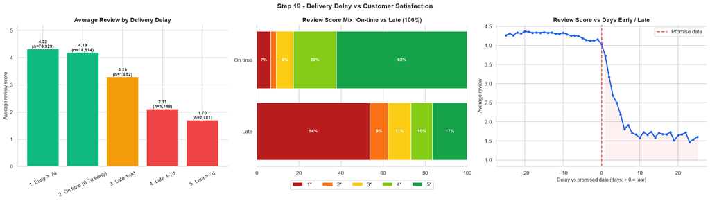

```python
bucket = q("""
    SELECT CASE WHEN delay_days <= -8 THEN '1. Early > 7d'
                WHEN delay_days <= 0  THEN '2. On time (0-7d early)'
                WHEN delay_days <= 3  THEN '3. Late 1-3d'
                WHEN delay_days <= 7  THEN '4. Late 4-7d'
                ELSE                       '5. Late > 7d' END AS delay_bucket,
           COUNT(*)                                    AS orders,
           ROUND(AVG(review_score), 2)                 AS avg_review,
           ROUND(100.0 * AVG(review_score <= 2), 1)    AS pct_negative,
           ROUND(100.0 * AVG(review_score >= 5), 1)    AS pct_5star
    FROM vw_order_master
    WHERE order_status = 'delivered' AND review_score IS NOT NULL AND delay_days IS NOT NULL
    GROUP BY 1 ORDER BY 1
""")
display(bucket)

rv = q("SELECT is_late, delay_days, review_score FROM vw_order_master WHERE order_status = 'delivered' AND review_score IS NOT NULL AND is_late IS NOT NULL")
late, ontime = rv.loc[rv.is_late == 1, "review_score"], rv.loc[rv.is_late == 0, "review_score"]
U, p = mannwhitneyu(late, ontime, alternative="two-sided")
rank_biserial = 2 * U / (len(late) * len(ontime)) - 1
cohen_d = (late.mean() - ontime.mean()) / np.sqrt((late.var() + ontime.var()) / 2)
rho, rho_p = spearmanr(rv["delay_days"], rv["review_score"])
test_tbl = pd.DataFrame({"metric": ["Mean review - on-time", "Mean review - late", "Mann-Whitney U p-value", "Rank-biserial r", "Cohen's d", "Spearman rho (delay vs review)"],
                         "value": [ontime.mean(), late.mean(), p, rank_biserial, cohen_d, rho]})
display(test_tbl)

curve = q("""
    SELECT delay_days, AVG(review_score) AS avg_review, COUNT(*) AS n
    FROM vw_order_master
    WHERE order_status = 'delivered' AND review_score IS NOT NULL AND delay_days BETWEEN -25 AND 25
    GROUP BY delay_days HAVING COUNT(*) >= 30 ORDER BY delay_days
""")
dist = pd.crosstab(rv["is_late"].map({0: "On time", 1: "Late"}), rv["review_score"].round().astype(int), normalize="index") * 100

fig, axes = plt.subplots(1, 3, figsize=(21, 6))
axes[0].bar(bucket["delay_bucket"], bucket["avg_review"], color=[GREEN, GREEN, ORANGE, RED, RED], edgecolor="white")
for i, (v, n) in enumerate(zip(bucket["avg_review"], bucket["orders"])): axes[0].text(i, v + 0.04, f"{v:.2f}\n(n={n:,})", ha="center", fontsize=9, fontweight="bold")
axes[0].set_ylim(0, 5.2); axes[0].set_ylabel("Average review score"); axes[0].tick_params(axis="x", rotation=25); axes[0].set_title("Average Review by Delivery Delay")

sc_colors = {1: "#B91C1C", 2: "#F97316", 3: "#FACC15", 4: "#84CC16", 5: "#16A34A"}
btm = np.zeros(len(dist))
for s in dist.columns:
    axes[1].barh(dist.index, dist[s], left=btm, color=sc_colors[s], edgecolor="white", label=f"{s}*")
    for i, v in enumerate(dist[s]):
        if v > 5: axes[1].text(btm[i] + v / 2, i, f"{v:.0f}%", ha="center", va="center", color="white", fontweight="bold", fontsize=9)
    btm += dist[s].values
axes[1].set_xlim(0, 100); axes[1].legend(ncol=5, loc="upper center", bbox_to_anchor=(0.5, -0.08)); axes[1].set_title("Review Score Mix: On-time vs Late (100%)")

axes[2].plot(curve["delay_days"], curve["avg_review"], color=BLUE, lw=2.4, marker="o", ms=4)
axes[2].axvline(0, color=RED, ls="--", lw=1.8, label="Promise date")
axes[2].fill_between(curve["delay_days"], curve["avg_review"], 1, where=curve["delay_days"] > 0, color=RED, alpha=0.08)
axes[2].set_xlabel("Delay vs promised date (days; > 0 = late)"); axes[2].set_ylabel("Average review"); axes[2].legend()
axes[2].set_title("Review Score vs Days Early / Late")
plt.suptitle("Step 19 - Delivery Delay vs Customer Satisfaction", fontsize=14, fontweight="bold")
plt.tight_layout(); plt.show()
```

**📌 Observation:** The effect is **large and non-linear**. Average review by delay bucket: **early > 7 days 4.32 (n = 70,929), on time 4.19 (n = 18,514), late 1-3 days 3.29, late 4-7 days 2.11, late > 7 days 1.70**. The share of negative (1-2★) reviews rises from 8.9 % / 10.3 % to 32.2 %, 67.6 % and **79.2 %**. In the stacked chart **54 % of late orders get 1★ (vs 7 % of on-time orders)**, and only 17 % of late orders get 5★ (vs 62 %). The right-hand curve shows a **cliff at the promise date**: the average sits at ~4.1-4.3 up to day 0, then falls to ~3.7 on day 1, ~2.7 by day 3 and ~1.8 by day 6, and **flattens at a floor of ~1.6-1.7 after about a week**. Overall: mean review **4.29 on-time vs 2.27 late**, Mann-Whitney U p ≈ 0, **rank-biserial r = −0.64** and **Cohen's d = −1.47**, both large effect sizes — so the result is not just a big-sample artefact. The Spearman ρ between delay and review is only **−0.18** because 93 % of orders are on time and the relationship is a threshold, not a straight line.

**💡 Pipeline / Engineering decision:** `is_late` and `delay_days` are promoted to **top-priority CSAT drivers** in the mart and feature set. Operational rules: (1) trigger **proactive customer communication when predicted delay > 0** (the first day late already costs ~0.4 stars), (2) issue an apology or small voucher for delays **> 3 days**, before the score reaches the ~2.7 zone, (3) report **"% 1★ on late orders"** as a companion KPI. For modelling, use a **late-vs-on-time binary or delay-bucket feature** rather than a linear `delay_days` term, and prefer rank-based effect sizes (Spearman alone understates this effect). A padded estimate is a legitimate CSAT-protection tool, balanced against the conversion cost noted in Step 17.

## Step 20 — Review Score Analysis and CSAT Trend

**Why:** The review distribution's *shape* (not just its mean) tells us how polarised customers are. We also track **CSAT over time next to the late-delivery rate** to test whether the two move together, and look at who bothers to write comments (a signal for how to mine text later).

**Business insight:** A 4.1 average can hide a J-shaped distribution — many delighted customers and a vocal group of very unhappy ones. Top-box / bottom-box percentages and an NPS-style proxy are more informative for management than a single mean.

```
Mean score 4.09 | 5-star 57.8% | 1-star 11.5% | NPS-style proxy (5* minus 1-3*) = +34.8
Monthly correlation: late-delivery % vs average review  ->  r = -0.92 (p = 0.0000, n = 20 months)
```

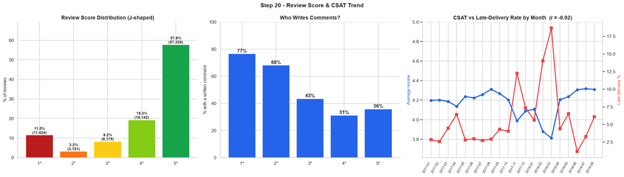

```python
dist_rv = q("SELECT review_score, COUNT(*) AS n FROM order_reviews GROUP BY review_score ORDER BY review_score")
dist_rv["pct"] = dist_rv["n"] / dist_rv["n"].sum() * 100

comment = q("""
    SELECT review_score, 100.0 * AVG(review_comment_message IS NOT NULL) AS comment_pct
    FROM order_reviews GROUP BY review_score ORDER BY review_score
""")
csat = q("""
    SELECT purchase_month, AVG(review_score) AS avg_review, 100.0 * AVG(review_score <= 2) AS neg_pct, 100.0 * AVG(is_late) AS late_pct
    FROM vw_order_master
    WHERE order_status = 'delivered' AND review_score IS NOT NULL AND purchase_month BETWEEN :s AND :e
    GROUP BY purchase_month ORDER BY purchase_month
""", {"s": WINDOW_START, "e": WINDOW_END})

promoters  = dist_rv.loc[dist_rv.review_score == 5, "pct"].sum()
detractors = dist_rv.loc[dist_rv.review_score <= 3, "pct"].sum()
r_month, r_p = stats.pearsonr(csat["late_pct"], csat["avg_review"])
print(f"Mean score {np.average(dist_rv.review_score, weights=dist_rv.n):.2f} | 5-star {promoters:.1f}% | 1-star {dist_rv.pct.iloc[0]:.1f}% | NPS-style proxy (5* minus 1-3*) = {promoters - detractors:+.1f}")
print(f"Monthly correlation: late-delivery % vs average review  ->  r = {r_month:.2f} (p = {r_p:.4f}, n = {len(csat)} months)")

fig, axes = plt.subplots(1, 3, figsize=(21, 6))
axes[0].bar(dist_rv["review_score"].astype(str) + "*", dist_rv["pct"], color=[sc_colors[int(s)] for s in dist_rv["review_score"]], edgecolor="white")
for i, (p_, n) in enumerate(zip(dist_rv["pct"], dist_rv["n"])): axes[0].text(i, p_ + 0.6, f"{p_:.1f}%\n({n:,})", ha="center", fontsize=9, fontweight="bold")
axes[0].set_ylim(0, dist_rv["pct"].max() * 1.2); axes[0].set_ylabel("% of reviews"); axes[0].set_title("Review Score Distribution (J-shaped)")

axes[1].bar(comment["review_score"].astype(str) + "*", comment["comment_pct"], color=BLUE, edgecolor="white")
for i, v in enumerate(comment["comment_pct"]): axes[1].text(i, v + 1, f"{v:.0f}%", ha="center", fontweight="bold")
axes[1].set_ylim(0, 100); axes[1].set_ylabel("% with a written comment"); axes[1].set_title("Who Writes Comments?")

xm = np.arange(len(csat))
axes[2].plot(xm, csat["avg_review"], color=BLUE, lw=2.6, marker="o", label="Avg review (left)")
axes[2].set_ylabel("Average review", color=BLUE); axes[2].set_ylim(csat["avg_review"].min() - 0.2, 5)
ax_b = axes[2].twinx(); ax_b.plot(xm, csat["late_pct"], color=RED, lw=2.4, marker="s", label="Late % (right)")
ax_b.set_ylabel("Late delivery %", color=RED); ax_b.spines["right"].set_visible(True); ax_b.grid(False)
axes[2].set_xticks(xm); axes[2].set_xticklabels(csat["purchase_month"], rotation=60, ha="right", fontsize=8)
axes[2].set_title(f"CSAT vs Late-Delivery Rate by Month  (r = {r_month:.2f})")
plt.suptitle("Step 20 - Review Score & CSAT Trend", fontsize=14, fontweight="bold")
plt.tight_layout(); plt.show()
```

**📌 Observation:** Reviews are **strongly polarised (J-shaped)**: **5★ = 57.8 % (57,328)** and 4★ = 19.3 %, but **1★ = 11.5 % (11,424) is far larger than 2★ = 3.2 %** — unhappy customers go straight to the bottom of the scale. Mean score **4.09**, NPS-style proxy **+34.8**. The comment-rate chart shows **77 % of 1★ and 68 % of 2★ reviews contain text, versus 31-36 % for 4-5★**, so written feedback is heavily skewed toward complaints. In the monthly chart the blue review line and red late-delivery line **move in opposite directions (r = −0.92, p ≈ 0, n = 20 months)**: review dips to **3.99 in Nov-2017** (late ≈ 12 %) and to **3.81 in Mar-2018** (late ≈ 19 %), and recovers to ~4.3 in Jun-Aug 2018 when the late rate is 1-6 %.

**💡 Pipeline / Engineering decision:** CSAT is reported as **mean + % 5★ + % 1★ + NPS proxy**, never the mean alone — the mean hides the 11.5 % of 1★ reviews. Reviews stay de-duplicated to order grain (Step 6) and `has_comment` is kept as a flag. Because 77 % of 1★ reviews carry text, a future **Portuguese NLP topic model should be trained on 1-2★ comments first** (highest complaint density) to explain the low-rating categories from Step 13. **Monthly late-delivery % is adopted as a leading indicator of CSAT**: with r = −0.92 it can be monitored weeks before review scores arrive.

## Step 21 — Seller Concentration (Lorenz Curve & Gini)

**Why:** Marketplace revenue is made by sellers, so **how concentrated** it is determines platform risk. A **Lorenz curve** and **Gini coefficient** quantify inequality in seller GMV, and a cumulative-share tiering (A / B / C) turns that into an operational segmentation. Seller-level aggregates are computed in SQL from `vw_item_master`.

**Business insight:** If a handful of sellers generate most GMV, losing or upsetting a few of them is a revenue event — and they deserve account managers. The long tail, on the other hand, needs low-touch, self-serve onboarding and quality controls instead of manual attention.

| tier | sellers | gmv_share | median_orders | avg_review | avg_late_pct | sellers_share |
| --- | --- | --- | --- | --- | --- | --- |
| A | 540 | 80.02 | 71.00 | 4.06 | 6.65 | 17.69 |
| B | 753 | 14.99 | 17.00 | 4.07 | 7.34 | 24.66 |
| C | 1760 | 4.99 | 3.00 | 4.00 | 6.76 | 57.65 |

```
3,053 active sellers | Gini = 0.79 | top 1% = 26.2% of GMV | top 10% = 67.4% | top 20% = 82.6%
Median seller: 7 orders, R$ 825 GMV   |   Top seller: R$ 229,238
```

|  | seller_id | seller_state | orders | gmv | avg_review | late_pct |
| --- | --- | --- | --- | --- | --- | --- |
| 0 | 4869f7a5 | SP | 1131 | 229,237.63 | 4.13 | 10.54 |
| 1 | 53243585 | BA | 358 | 222,776.05 | 4.08 | 3.00 |
| 2 | 4a3ca931 | SP | 1804 | 200,326.12 | 3.80 | 9.70 |
| 3 | fa1c13f2 | SP | 584 | 192,842.13 | 4.34 | 9.15 |
| 4 | 7c67e144 | SP | 982 | 187,923.89 | 3.34 | 8.86 |
| 5 | 7e93a43e | SP | 332 | 172,583.88 | 4.24 | 4.66 |
| 6 | da8622b1 | SP | 1314 | 160,236.57 | 4.06 | 6.40 |
| 7 | 7a67c85e | SP | 1159 | 141,715.54 | 4.24 | 5.19 |
| 8 | 1025f0e2 | SP | 915 | 138,968.55 | 3.85 | 6.69 |
| 9 | 955fee92 | SP | 1286 | 135,159.70 | 4.05 | 6.45 |

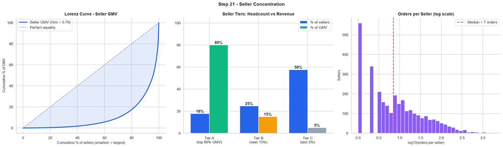

```python
sellers_df = q("""
    SELECT seller_id, seller_state,
           COUNT(DISTINCT order_id)   AS orders,
           COUNT(*)                   AS items,
           COUNT(DISTINCT product_id) AS products,
           SUM(price)                 AS gmv,
           AVG(price)                 AS avg_price,
           AVG(review_score)          AS avg_review,
           100.0 * AVG(is_late)       AS late_pct
    FROM vw_item_master
    WHERE is_valid_order = 1
    GROUP BY seller_id, seller_state
""")

s = sellers_df.sort_values("gmv", ascending=False).reset_index(drop=True)
s["gmv_share"] = s["gmv"] / s["gmv"].sum() * 100
s["cum_share"] = s["gmv"].cumsum() / s["gmv"].sum() * 100
prev = s["cum_share"].shift(fill_value=0)
s["tier"] = np.select([prev < 80, prev < 95], ["A", "B"], default="C")

n = len(s)
top_share = {p: s["gmv"].head(max(int(round(n * p / 100)), 1)).sum() / s["gmv"].sum() * 100 for p in (1, 10, 20)}
asc = np.sort(s["gmv"].values); L = np.r_[0, np.cumsum(asc) / asc.sum()]; xg = np.r_[0, np.arange(1, n + 1) / n]
gini = 1 - 2 * np.sum((L[1:] + L[:-1]) / 2 * np.diff(xg))

tier_tbl = s.groupby("tier").agg(sellers=("seller_id", "count"), gmv_share=("gmv_share", "sum"), median_orders=("orders", "median"),
                                 avg_review=("avg_review", "mean"), avg_late_pct=("late_pct", "mean"))
tier_tbl["sellers_share"] = tier_tbl["sellers"] / n * 100
display(tier_tbl.round(2))
print(f"{n:,} active sellers | Gini = {gini:.2f} | top 1% = {top_share[1]:.1f}% of GMV | top 10% = {top_share[10]:.1f}% | top 20% = {top_share[20]:.1f}%")
print(f"Median seller: {s.orders.median():.0f} orders, R$ {s.gmv.median():,.0f} GMV   |   Top seller: R$ {s.gmv.max():,.0f}")
display(s.head(10)[["seller_id", "seller_state", "orders", "gmv", "avg_review", "late_pct"]].assign(seller_id=lambda d: d.seller_id.str[:8]).round(2))

fig, axes = plt.subplots(1, 3, figsize=(21, 6.2))
axes[0].plot(xg * 100, L * 100, color=BLUE, lw=2.8, label=f"Seller GMV (Gini = {gini:.2f})")
axes[0].plot([0, 100], [0, 100], color=GRAY, ls="--", label="Perfect equality")
axes[0].fill_between(xg * 100, L * 100, xg * 100, color=BLUE, alpha=0.12)
axes[0].set_xlabel("Cumulative % of sellers (smallest -> largest)"); axes[0].set_ylabel("Cumulative % of GMV"); axes[0].legend(); axes[0].set_title("Lorenz Curve - Seller GMV")

tc = {"A": GREEN, "B": ORANGE, "C": GRAY}
xx = np.arange(3); w = 0.38
axes[1].bar(xx - w / 2, tier_tbl["sellers_share"], w, color=BLUE, label="% of sellers", edgecolor="white")
axes[1].bar(xx + w / 2, tier_tbl["gmv_share"], w, color=[tc[t] for t in tier_tbl.index], label="% of GMV", edgecolor="white")
for i, (a, b) in enumerate(zip(tier_tbl["sellers_share"], tier_tbl["gmv_share"])):
    axes[1].text(i - w / 2, a + 1, f"{a:.0f}%", ha="center", fontweight="bold"); axes[1].text(i + w / 2, b + 1, f"{b:.0f}%", ha="center", fontweight="bold")
axes[1].set_xticks(xx); axes[1].set_xticklabels([f"Tier {t}\n({'top 80% GMV' if t == 'A' else 'next 15%' if t == 'B' else 'last 5%'})" for t in tier_tbl.index])
axes[1].legend(); axes[1].set_ylim(0, 105); axes[1].set_title("Seller Tiers: Headcount vs Revenue")

axes[2].hist(np.log10(s["orders"]), bins=35, color=PURPLE, edgecolor="white")
axes[2].axvline(np.log10(s["orders"].median()), color=RED, ls="--", lw=2, label=f"Median = {s['orders'].median():.0f} orders")
axes[2].set_xlabel("log10(orders per seller)"); axes[2].set_ylabel("Sellers"); axes[2].legend(); axes[2].set_title("Orders per Seller (log scale)")
plt.suptitle("Step 21 - Seller Concentration", fontsize=14, fontweight="bold")
plt.tight_layout(); plt.show()
```

**📌 Observation:** Seller revenue is **extremely unequal: Gini = 0.79** across 3,053 active sellers, and the Lorenz curve bows deep below the equality line. **The top 1 % of sellers earn 26.2 % of GMV, the top 10 % earn 67.4 % and the top 20 % earn 82.6 %**. The tier chart shows **Tier A = 540 sellers (18 %) holding 80 % of GMV**, Tier B = 753 sellers (25 %) with 15 %, and **Tier C = 1,760 sellers (58 %) sharing the last 5 %**. The histogram (log scale) shows a median of **7 orders and R$ 825 GMV per seller over the whole period**, about 560 sellers with exactly one order, and a long right tail; the top seller earned R$ 229 k (~1.7 % of GMV). Quality does **not** differ by tier: average review is 4.06 / 4.07 / 4.00 and average late rate 6.7 % / 7.3 % / 6.8 % for A / B / C — big sellers are not better or worse at service.

**💡 Pipeline / Engineering decision:** Sellers are assigned an **A / B / C tier by cumulative GMV share** (`tier` column in `mart_sellers`). Operating model: **Tier A → account management and quality SLAs; Tier B → automated performance nudges; Tier C → self-serve onboarding with minimum-quality gates**. A platform-risk KPI, **"share of GMV from the top 1 % of sellers" (26.2 %)**, is monitored monthly because losing a handful of sellers would remove a quarter of revenue. Since quality is flat across tiers, tiering is used for *how much attention to give*, not as a quality proxy.

## Step 22 — Seller Quality Quadrant (Scorecard)

**Why:** Revenue rank alone doesn't show which sellers are damaging the customer experience. We score every seller with enough history on **review score** and **late-delivery rate**, and classify them as *Healthy / Watch / At-risk*. A **minimum-volume filter (≥ 30 orders)** stops a seller with 2 unlucky orders from being flagged.

**Business insight:** Marketplaces protect their brand through seller governance — warnings, listing suppression or removal. Prioritising interventions by **GMV exposure** (big + bad first) is far more efficient than sorting by rating alone.

| status | sellers | gmv | avg_review | avg_late_pct | sellers_% | gmv_% |
| --- | --- | --- | --- | --- | --- | --- |
| At-risk | 23 | 183,562.34 | 3.42 | 21.04 | 3.63 | 1.76 |
| Healthy | 509 | 8,887,703.56 | 4.21 | 5.26 | 80.28 | 85.45 |
| Watch | 102 | 1,329,221.99 | 3.66 | 9.18 | 16.09 | 12.78 |

```
Scored sellers: 634 of 3,053 (>= 30 orders) covering 77.1% of GMV
Spearman correlation across sellers: late % vs avg review = -0.43

Top at-risk / watch sellers by GMV exposure:
```

|  | seller_id | seller_state | orders | gmv | avg_review | late_pct | status |
| --- | --- | --- | --- | --- | --- | --- | --- |
| 1515 | 7c67e144 | SP | 982 | 187,923.89 | 3.34 | 8.86 | Watch |
| 437 | 25c5c91f | MG | 158 | 54,679.22 | 3.72 | 6.02 | Watch |
| 1570 | 81602554 | SP | 385 | 47,017.69 | 3.83 | 15.09 | Watch |
| 549 | 2eb70248 | SP | 202 | 42,628.61 | 2.71 | 11.68 | Watch |
| 1367 | 712e6ed8 | SC | 79 | 39,815.00 | 3.45 | 20.00 | At-risk |
| 80 | 06a2c3af | MA | 392 | 36,408.95 | 4.00 | 19.40 | Watch |
| 283 | 1835b56c | SP | 423 | 33,344.21 | 3.59 | 8.89 | Watch |
| 1616 | 855668e0 | SP | 310 | 31,918.21 | 3.77 | 12.54 | Watch |
| 1646 | 88460e8e | PR | 247 | 31,396.65 | 3.36 | 16.33 | At-risk |
| 1354 | 70a12e78 | SP | 315 | 30,858.53 | 3.77 | 9.29 | Watch |

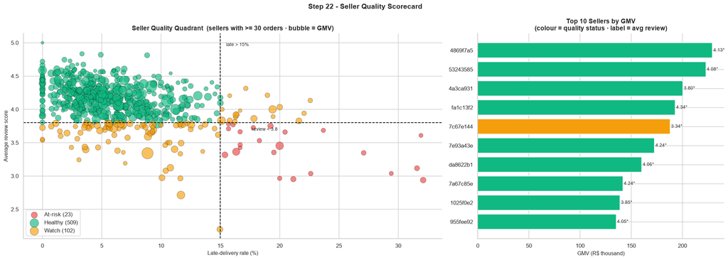

```python
MIN_ORDERS, REVIEW_TH, LATE_TH = 30, 3.8, 15.0

sq = sellers_df.query("orders >= @MIN_ORDERS").dropna(subset=["avg_review"]).copy()
sq["status"] = np.select(
    [(sq.avg_review < REVIEW_TH) & (sq.late_pct > LATE_TH), (sq.avg_review < REVIEW_TH) | (sq.late_pct > LATE_TH)],
    ["At-risk", "Watch"], default="Healthy")

status_tbl = sq.groupby("status").agg(sellers=("seller_id", "count"), gmv=("gmv", "sum"), avg_review=("avg_review", "mean"), avg_late_pct=("late_pct", "mean"))
status_tbl["sellers_%"] = status_tbl["sellers"] / status_tbl["sellers"].sum() * 100
status_tbl["gmv_%"]     = status_tbl["gmv"] / status_tbl["gmv"].sum() * 100
display(status_tbl.round(2))
rho_s, _ = spearmanr(sq["late_pct"], sq["avg_review"])
print(f"Scored sellers: {len(sq):,} of {len(sellers_df):,} (>= {MIN_ORDERS} orders) covering {sq.gmv.sum() / sellers_df.gmv.sum():.1%} of GMV")
print(f"Spearman correlation across sellers: late % vs avg review = {rho_s:.2f}")
print("\nTop at-risk / watch sellers by GMV exposure:")
display(sq[sq.status != "Healthy"].sort_values("gmv", ascending=False).head(10)[["seller_id", "seller_state", "orders", "gmv", "avg_review", "late_pct", "status"]]
        .assign(seller_id=lambda d: d.seller_id.str[:8]).round(2))

sc_map = {"Healthy": GREEN, "Watch": ORANGE, "At-risk": RED}
fig, axes = plt.subplots(1, 2, figsize=(20, 7.2), gridspec_kw={"width_ratios": [1.7, 1]})
for st, d in sq.groupby("status"):
    axes[0].scatter(d["late_pct"], d["avg_review"], s=np.sqrt(d["gmv"]) * 1.1 + 12, c=sc_map[st], alpha=0.65, edgecolor="black", linewidth=0.4, label=f"{st} ({len(d)})")
axes[0].axvline(LATE_TH, color="black", ls="--", lw=1.3); axes[0].axhline(REVIEW_TH, color="black", ls="--", lw=1.3)
axes[0].text(LATE_TH + 0.5, sq.avg_review.max() - 0.05, f"late > {LATE_TH:.0f}%", fontsize=9); axes[0].text(sq.late_pct.max() * 0.55, REVIEW_TH - 0.12, f"review < {REVIEW_TH}", fontsize=9)
axes[0].set_xlabel("Late-delivery rate (%)"); axes[0].set_ylabel("Average review score"); axes[0].legend(loc="lower left")
axes[0].set_title(f"Seller Quality Quadrant  (sellers with >= {MIN_ORDERS} orders · bubble = GMV)")

t10 = s.head(10).merge(sq[["seller_id", "status"]], on="seller_id", how="left").fillna({"status": "Not scored"}).iloc[::-1]
axes[1].barh(t10["seller_id"].str[:8], t10["gmv"] / 1e3, color=[sc_map.get(x, GRAY) for x in t10["status"]], edgecolor="white")
for y, (v, r) in enumerate(zip(t10["gmv"], t10["avg_review"])): axes[1].text(v / 1e3 + 1, y, f"{r:.2f}*", va="center", fontsize=9)
axes[1].set_xlabel("GMV (R$ thousand)"); axes[1].set_title("Top 10 Sellers by GMV\n(colour = quality status · label = avg review)")
plt.suptitle("Step 22 - Seller Quality Scorecard", fontsize=14, fontweight="bold")
plt.tight_layout(); plt.show()
```

**📌 Observation:** Of the **634 sellers with ≥ 30 orders (77.1 % of GMV)**, **509 (80.3 %) are Healthy and hold 85.5 % of GMV**, **102 (16.1 %) are Watch (12.8 % of GMV, avg review 3.66, 9.2 % late)** and **23 (3.6 %) are At-risk (1.8 % of GMV, avg review 3.42, 21.0 % late)**. In the quadrant plot the green cloud sits top-left (review 4-4.7, late < 10 %), orange sellers spread below the 3.8 review line, and the red cluster in the bottom-right has both > 15 % late and < 3.8 stars, with some sellers at 27-32 % late. Across sellers, **higher late % goes with lower review (Spearman ρ = −0.43)**, the seller-level echo of Step 19 — but ρ is only moderate, and many Watch sellers have *low* late rates and still low reviews, so quality problems are not only about logistics. **Revenue rank and quality rank are different lists**: of the top 10 sellers by GMV, one (`7c67e144`, R$ 188 k, 3.34★, 8.9 % late) is flagged Watch, and `4a3ca931` (R$ 200 k) sits right at the 3.80 threshold. The GMV-exposure table also lists At-risk sellers such as `712e6ed8` (R$ 39.8 k, 20 % late) and `88460e8e` (R$ 31.4 k, 16.3 % late).

**💡 Pipeline / Engineering decision:** A **seller scorecard** (`status`, `tier`, `avg_review`, `late_pct`) is exported to `mart_sellers`; sellers below the volume cut-off are labelled **"Not scored (< 30 orders)"** instead of being force-classified. The rules are configuration values (`MIN_ORDERS = 30`, `REVIEW_TH = 3.8`, `LATE_TH = 15 %`), so they can be tuned without touching logic. Governance priority is **At-risk ∩ Tier A/B first (largest GMV exposure), then high-GMV Watch sellers such as `7c67e144`**. Because the 30-order cut-off leaves ~2,400 small sellers unscored, the next iteration should use **empirical-Bayes shrinkage** instead of a hard threshold and add `seller_handling_days` (Step 18) to the score.

## Step 23 — Customer Purchase Behaviour (and the `customer_id` Trap)

**Why:** Before any retention or CLV work we must define "a customer" correctly. In Olist, **`customer_id` is re-issued for every order**, while **`customer_unique_id`** identifies the real person. Counting the wrong one makes every customer look brand new and would report ~0 % repeat rate by construction. We then measure orders per customer and the **time gap between consecutive orders** with `LAG() OVER (PARTITION BY ...)`.

**Business insight:** Retention economics drive marketplace profitability: acquiring a customer costs several times more than re-selling to one. Knowing how many customers return — and how fast — sets the ceiling for marketing ROI.

| segment | customers | avg_spend | total_spend | customer_share_% | revenue_share_% |
| --- | --- | --- | --- | --- | --- |
| One-time | 92102 | 161.22 | 14,848,602.89 | 96.96 | 94.34 |
| Repeat | 2888 | 308.36 | 890,534.12 | 3.04 | 5.66 |

```
customer_id rows: 99,441  vs  customer_unique_id: 96,096  -> 3,345 extra ids created by re-issuing
Repeat customers: 3.04%  |  repeat gaps: median 29 days, 29.8% of repeat orders placed < 1 day after the previous one
```

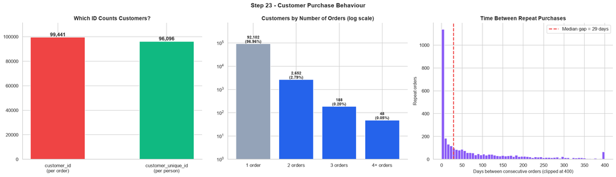

```python
id_check = q("SELECT COUNT(*) AS customer_ids, COUNT(DISTINCT customer_unique_id) AS unique_customers FROM customers").iloc[0]

cust = q("""
    SELECT customer_unique_id, COUNT(*) AS orders, SUM(payment_value) AS spend
    FROM vw_order_master WHERE is_valid_order = 1
    GROUP BY customer_unique_id
""")
gaps = q("""
    WITH o AS (
        SELECT customer_unique_id, purchase_ts,
               LAG(purchase_ts) OVER (PARTITION BY customer_unique_id ORDER BY purchase_ts) AS prev_ts
        FROM vw_order_master WHERE is_valid_order = 1
    )
    SELECT ROUND(JULIANDAY(purchase_ts) - JULIANDAY(prev_ts), 1) AS gap_days FROM o WHERE prev_ts IS NOT NULL
""")

cust["segment"] = np.where(cust["orders"] > 1, "Repeat", "One-time")
seg = cust.groupby("segment").agg(customers=("customer_unique_id", "count"), avg_spend=("spend", "mean"), total_spend=("spend", "sum"))
seg["customer_share_%"] = seg["customers"] / seg["customers"].sum() * 100
seg["revenue_share_%"]  = seg["total_spend"] / seg["total_spend"].sum() * 100
display(seg.round(2))

opc = cust["orders"].clip(upper=4).value_counts().sort_index()
opc.index = ["1 order", "2 orders", "3 orders", "4+ orders"][: len(opc)]
same_day = (gaps["gap_days"] < 1).mean() * 100
print(f"customer_id rows: {id_check.customer_ids:,}  vs  customer_unique_id: {id_check.unique_customers:,}  -> {id_check.customer_ids - id_check.unique_customers:,} extra ids created by re-issuing")
print(f"Repeat customers: {(cust.orders > 1).mean() * 100:.2f}%  |  repeat gaps: median {gaps.gap_days.median():.0f} days, {same_day:.1f}% of repeat orders placed < 1 day after the previous one")

fig, axes = plt.subplots(1, 3, figsize=(20, 5.8))
axes[0].bar(["customer_id\n(per order)", "customer_unique_id\n(per person)"], [id_check.customer_ids, id_check.unique_customers], color=[RED, GREEN], edgecolor="white", width=0.5)
for i, v in enumerate([id_check.customer_ids, id_check.unique_customers]): axes[0].text(i, v, f"{v:,.0f}", ha="center", va="bottom", fontweight="bold")
axes[0].set_ylim(0, id_check.customer_ids * 1.12); axes[0].set_title("Which ID Counts Customers?")

axes[1].bar(opc.index, opc.values, color=[GRAY, BLUE, BLUE, BLUE][: len(opc)], edgecolor="white"); axes[1].set_yscale("log")
for i, v in enumerate(opc.values): axes[1].text(i, v * 1.1, f"{v:,}\n({v / opc.sum() * 100:.2f}%)", ha="center", fontweight="bold", fontsize=9)
axes[1].set_ylim(1, opc.max() * 8); axes[1].set_title("Customers by Number of Orders (log scale)")

axes[2].hist(gaps["gap_days"].clip(upper=400), bins=60, color=PURPLE, edgecolor="white")
axes[2].axvline(gaps.gap_days.median(), color=RED, ls="--", lw=2, label=f"Median gap = {gaps.gap_days.median():.0f} days")
axes[2].set_xlabel("Days between consecutive orders (clipped at 400)"); axes[2].set_ylabel("Repeat orders"); axes[2].legend(); axes[2].set_title("Time Between Repeat Purchases")
plt.suptitle("Step 23 - Customer Purchase Behaviour", fontsize=14, fontweight="bold")
plt.tight_layout(); plt.show()
```

**📌 Observation:** The ID trap is confirmed: **`customer_id` has 99,441 values but there are only 96,096 real people (`customer_unique_id`)** — using the wrong key would overstate the customer base by 3,345 and hide repeat buyers. **96.96 % of customers (92,102) order exactly once**; 2,652 order twice (2.79 %), 188 three times (0.20 %) and only 48 order 4+ times (0.05 %) — a steep fall shown on the log-scale bar chart. Repeat customers are **3.04 % of people (2,888)** and spend **R$ 308 vs R$ 161 on average** (revenue share 5.66 %, about 1.9× their headcount share). The gap histogram has a **huge spike in the first few days** (over 1,100 repeat orders in the first bin): **29.8 % of repeat orders were placed less than 1 day after the previous order**, which points to split baskets rather than genuine loyalty. The median gap is 29 days, with a long thin tail out to 400 days.

**💡 Pipeline / Engineering decision:** **All customer-level metrics use `customer_unique_id`**; `customer_id` is treated strictly as an order-level foreign key, and this rule is documented in the master view. Repeat orders placed within a day of each other should be **flagged as split baskets and merged** for cleaner repeat-rate reporting — the true "loyal" repeat rate is meaningfully below 3 %. Because ~97 % of customers are one-time buyers, the modelling target for later work is **second-purchase propensity**, not classic churn.

## Step 24 — Cohort Retention Analysis

**Why:** Cohort analysis groups customers by the month of their **first purchase** and tracks the share who buy again in each following month. It separates real retention from the illusion created by rapid acquisition growth, and is the standard "retention triangle" seen in every growth review. Built in SQL with a CTE for cohort assignment and a month-index calculation.

**Business insight:** Total repeat rate can look stable while newer cohorts are actually worse than old ones. Cohort curves reveal whether **acquisition quality** is improving — e.g. whether Black Friday buyers stick around or were just deal-hunters.

```
Cohorts analysed: 20  (2017-01 -> 2018-08)  |  average cohort size: 4,735 new customers
Size-weighted retention by months since first purchase (%):
1   0.48
2   0.34
3   0.26
4   0.26
5   0.22
6   0.23
7   0.21
8   0.21
Cumulative return within 8 months (sum of monthly rates): ~2.21%
```

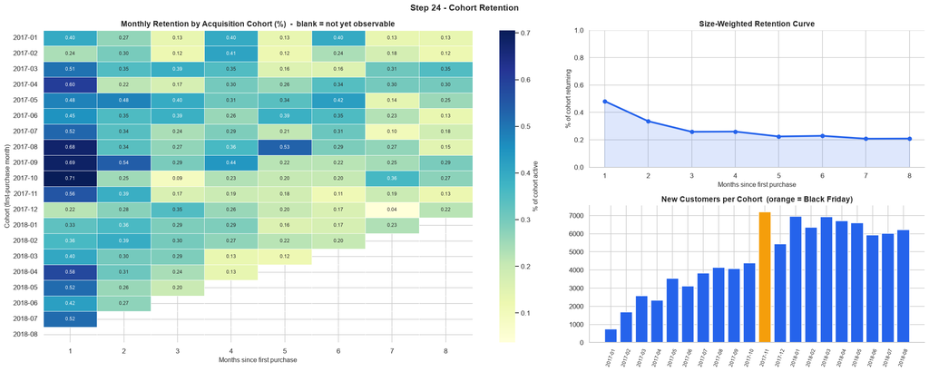

```python
cohort = q("""
    WITH first AS (
        SELECT customer_unique_id, MIN(purchase_month) AS cohort
        FROM vw_order_master WHERE is_valid_order = 1 GROUP BY customer_unique_id
    ),
    act AS (
        SELECT DISTINCT customer_unique_id, purchase_month
        FROM vw_order_master WHERE is_valid_order = 1 AND purchase_month <= :e
    )
    SELECT f.cohort,
           (CAST(SUBSTR(a.purchase_month, 1, 4) AS INTEGER) - CAST(SUBSTR(f.cohort, 1, 4) AS INTEGER)) * 12
         +  CAST(SUBSTR(a.purchase_month, 6, 2) AS INTEGER) - CAST(SUBSTR(f.cohort, 6, 2) AS INTEGER) AS month_idx,
           COUNT(*) AS customers
    FROM first f JOIN act a ON a.customer_unique_id = f.customer_unique_id
    WHERE f.cohort BETWEEN :s AND :e
    GROUP BY f.cohort, month_idx
""", {"s": WINDOW_START, "e": WINDOW_END})

MAX_IDX = 8
piv = cohort.pivot(index="cohort", columns="month_idx", values="customers").reindex(columns=range(0, MAX_IDX + 1)).fillna(0)
size = piv[0]
ret = piv.div(size, axis=0) * 100
def max_observable(c): return (int(WINDOW_END[:4]) - int(c[:4])) * 12 + int(WINDOW_END[5:7]) - int(c[5:7])
obs_mask = pd.DataFrame({k: [k <= max_observable(c) for c in ret.index] for k in ret.columns}, index=ret.index)
ret = ret.where(obs_mask)

curve = pd.Series({k: piv.loc[obs_mask[k], k].sum() / size[obs_mask[k]].sum() * 100 for k in range(1, MAX_IDX + 1) if obs_mask[k].any()})
print(f"Cohorts analysed: {len(ret)}  ({ret.index.min()} -> {ret.index.max()})  |  average cohort size: {size.mean():,.0f} new customers")
print("Size-weighted retention by months since first purchase (%):"); print(curve.round(2).to_string())
print(f"Cumulative return within {MAX_IDX} months (sum of monthly rates): ~{curve.sum():.2f}%")

fig = plt.figure(figsize=(21, 8.5))
gs = fig.add_gridspec(2, 2, width_ratios=[1.6, 1], height_ratios=[1, 1])
ax0 = fig.add_subplot(gs[:, 0])
sns.heatmap(ret.iloc[:, 1:], annot=True, fmt=".2f", cmap="YlGnBu", linewidths=0.5, cbar_kws={"label": "% of cohort active"}, ax=ax0, annot_kws={"size": 8})
ax0.set_title("Monthly Retention by Acquisition Cohort (%)  -  blank = not yet observable"); ax0.set_xlabel("Months since first purchase"); ax0.set_ylabel("Cohort (first-purchase month)")

ax1 = fig.add_subplot(gs[0, 1])
ax1.plot(curve.index, curve.values, color=BLUE, lw=2.8, marker="o"); ax1.fill_between(curve.index, curve.values, alpha=0.15, color=BLUE)
ax1.set_ylim(0, max(curve.max() * 1.6, 1)); ax1.set_xlabel("Months since first purchase"); ax1.set_ylabel("% of cohort returning"); ax1.set_title("Size-Weighted Retention Curve")

ax2 = fig.add_subplot(gs[1, 1])
ax2.bar(size.index, size.values, color=[ORANGE if c == "2017-11" else BLUE for c in size.index], edgecolor="white")
ax2.set_title("New Customers per Cohort  (orange = Black Friday)"); ax2.tick_params(axis="x", rotation=70, labelsize=8)
plt.suptitle("Step 24 - Cohort Retention", fontsize=14, fontweight="bold")
plt.tight_layout(); plt.show()
```

**📌 Observation:** Retention is **remarkably low in every cohort**. The heatmap values are percentages, so the *highest* cell is only **0.71 % (Oct-2017 cohort, month 1)** and the lowest **0.04 %** (Dec-2017, month 7); most cells are between 0.1 % and 0.5 %. The size-weighted curve (top-right) is **0.48 % in month 1, 0.34 % in month 2, ~0.26 % at months 3-4, and then flat at ~0.21-0.23 % through month 8** — it never rises again, so there is **no "retention smile"**. Summing the monthly rates gives ~2.2 % of a cohort coming back at all within 8 months. Cohort size grows from a few hundred (Jan-2017) to about **7.2 k in the Black-Friday cohort (orange bar)**, the largest of all, yet that cohort does **not** retain better: 0.56 % in month 1 and 0.11-0.19 % in months 3-8, in line with or below neighbouring cohorts (the Aug-Oct 2017 cohorts do best in month 1: 0.68-0.71 %). Blank cells on the right are cohorts too recent to observe (right-censoring); the 2018-08 cohort has none.

**💡 Pipeline / Engineering decision:** Right-censored cells are **explicitly masked** (`max_observable`) and the weighted curve only uses observable cohort-months, so recent cohorts are never compared unfairly. A classic churn label ("inactive for N days") is **degenerate here** (~97 % of customers would be labelled churned), so the modelling plan is a **second-purchase propensity model** using first-order features: delivery delay (Step 19), review score, category, payment type and freight ratio. For growth planning, at ~2 % lifetime return within 8 months **LTV ≈ first-order margin**, which caps how much can be spent to acquire a customer, and the Black-Friday acquisition wave should not be counted as a source of long-term value.

## Step 25 — RFM Segmentation and Customer Lifetime Value

**Why:** RFM (Recency, Frequency, Monetary) is the workhorse of customer segmentation and is written entirely in SQL using `NTILE()` window functions. Because ~97 % of customers have Frequency = 1, quintile-scoring Frequency would be meaningless — so **R and M use `NTILE(5)` while F uses business rules (1, 2, 3+)**. Historical **CLV** is measured as total spend per customer.

**Business insight:** Different customers need different actions — win-back offers for lapsed big spenders, onboarding journeys for new ones, loyalty perks for repeaters. Segment sizes vs revenue shares show where marketing money has the best expected return.

| segment | customers | avg_recency_days | avg_frequency | clv_avg | revenue | customers_% | revenue_% |
| --- | --- | --- | --- | --- | --- | --- | --- |
| Champions (repeat & recent) | 1243 | 138.90 | 2.20 | 321.40 | 399,553.50 | 1.30 | 2.50 |
| Loyal repeat | 1645 | 371.50 | 2.10 | 298.50 | 490,980.60 | 1.70 | 3.10 |
| New high-value | 14685 | 141.90 | 1.00 | 303.10 | 4,451,124.10 | 15.50 | 28.30 |
| New / promising | 22067 | 139.50 | 1.00 | 73.10 | 1,613,837.10 | 23.20 | 10.30 |
| At-risk big spenders | 13952 | 445.20 | 1.00 | 309.30 | 4,315,955.10 | 14.70 | 27.40 |
| Hibernating | 23018 | 446.00 | 1.00 | 72.70 | 1,673,703.80 | 24.20 | 10.60 |
| Needs attention | 18379 | 270.20 | 1.00 | 152.00 | 2,793,982.70 | 19.30 | 17.80 |

```
Customers with frequency = 1: 97.0%  (why F cannot be quintile-scored)
Historical CLV: mean R$ 166 | median R$ 108 | repeat customers R$ 308 vs one-time R$ 161
```

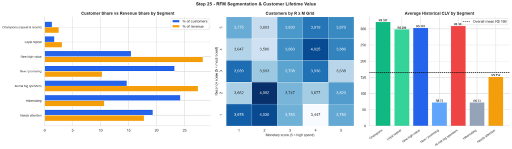

```python
rfm = q("""
    WITH snap AS (SELECT DATE(MAX(purchase_ts), '+1 day') AS d FROM vw_order_master),
    base AS (
        SELECT customer_unique_id,
               CAST(JULIANDAY((SELECT d FROM snap)) - JULIANDAY(MAX(purchase_date)) AS INTEGER) AS recency_days,
               COUNT(*)           AS frequency,
               SUM(payment_value) AS monetary
        FROM vw_order_master
        WHERE is_valid_order = 1 AND payment_value IS NOT NULL
        GROUP BY customer_unique_id
    )
    SELECT customer_unique_id, recency_days, frequency, monetary,
           NTILE(5) OVER (ORDER BY recency_days DESC) AS r_score,      -- 5 = most recent
           NTILE(5) OVER (ORDER BY monetary)          AS m_score       -- 5 = highest spend
    FROM base
""")

rules = [
    (rfm.frequency >= 2) & (rfm.r_score >= 4),
    (rfm.frequency >= 2),
    (rfm.r_score >= 4) & (rfm.m_score >= 4),
    (rfm.r_score >= 4),
    (rfm.r_score <= 2) & (rfm.m_score >= 4),
    (rfm.r_score <= 2),
]
SEG = ["Champions (repeat & recent)", "Loyal repeat", "New high-value", "New / promising", "At-risk big spenders", "Hibernating"]
rfm["segment"] = np.select(rules, SEG, default="Needs attention")
order_seg = SEG + ["Needs attention"]

seg_tbl = (rfm.groupby("segment").agg(customers=("customer_unique_id", "count"), avg_recency_days=("recency_days", "mean"),
                                       avg_frequency=("frequency", "mean"), clv_avg=("monetary", "mean"), revenue=("monetary", "sum"))
              .reindex([s for s in order_seg if s in rfm.segment.unique()]))
seg_tbl["customers_%"] = seg_tbl["customers"] / seg_tbl["customers"].sum() * 100
seg_tbl["revenue_%"]   = seg_tbl["revenue"]   / seg_tbl["revenue"].sum()   * 100
display(seg_tbl.round(1))
print(f"Customers with frequency = 1: {(rfm.frequency == 1).mean():.1%}  (why F cannot be quintile-scored)")
print(f"Historical CLV: mean R$ {rfm.monetary.mean():,.0f} | median R$ {rfm.monetary.median():,.0f} | repeat customers R$ {rfm[rfm.frequency > 1].monetary.mean():,.0f} vs one-time R$ {rfm[rfm.frequency == 1].monetary.mean():,.0f}")

seg_col = {"Champions (repeat & recent)": GREEN, "Loyal repeat": "#34D399", "New high-value": BLUE, "New / promising": "#60A5FA",
           "At-risk big spenders": RED, "Hibernating": GRAY, "Needs attention": ORANGE}
fig, axes = plt.subplots(1, 3, figsize=(22, 6.5), gridspec_kw={"width_ratios": [1.3, 1, 1.1]})
yy = np.arange(len(seg_tbl)); h = 0.38
axes[0].barh(yy - h / 2, seg_tbl["customers_%"], h, color=BLUE, label="% of customers"); axes[0].barh(yy + h / 2, seg_tbl["revenue_%"], h, color=ORANGE, label="% of revenue")
axes[0].set_yticks(yy); axes[0].set_yticklabels(seg_tbl.index, fontsize=9); axes[0].invert_yaxis(); axes[0].legend(); axes[0].set_title("Customer Share vs Revenue Share by Segment")

hm = pd.crosstab(rfm["r_score"], rfm["m_score"]).sort_index(ascending=False)
sns.heatmap(hm, annot=True, fmt=",d", cmap="Blues", cbar=False, linewidths=0.5, ax=axes[1])
axes[1].set_xlabel("Monetary score (5 = high spend)"); axes[1].set_ylabel("Recency score (5 = most recent)"); axes[1].set_title("Customers by R x M Grid")

axes[2].bar(range(len(seg_tbl)), seg_tbl["clv_avg"], color=[seg_col[s] for s in seg_tbl.index], edgecolor="white")
axes[2].set_xticks(range(len(seg_tbl))); axes[2].set_xticklabels([s.split(" (")[0] for s in seg_tbl.index], rotation=35, ha="right", fontsize=9)
for i, v in enumerate(seg_tbl["clv_avg"]): axes[2].text(i, v, f"R$ {v:,.0f}", ha="center", va="bottom", fontsize=8.5, fontweight="bold")
axes[2].axhline(rfm.monetary.mean(), color="black", ls="--", lw=1.2, label=f"Overall mean R$ {rfm.monetary.mean():,.0f}"); axes[2].legend()
axes[2].set_title("Average Historical CLV by Segment")
plt.suptitle("Step 25 - RFM Segmentation & Customer Lifetime Value", fontsize=14, fontweight="bold")
plt.tight_layout(); plt.show()
```

**📌 Observation:** **97.0 % of customers have Frequency = 1**, which is why F cannot be quintile-scored and the segments are rule-based. The notebook produces **7 segments**. The left chart shows revenue share diverging from customer share: **"New high-value" = 15.5 % of customers but 28.3 % of revenue**, and **"At-risk big spenders" = 14.7 % of customers, 27.4 % of revenue** (average recency 445 days, R$ 309 CLV) — together **~56 % of revenue from ~30 % of customers**. **"Hibernating" is the largest group (24.2 % of customers, 10.6 % of revenue, R$ 73 CLV) **and "New / promising" is 23.2 % of customers with only 10.3 % of revenue.** Champions (1.3 %) and Loyal repeat (1.7 %) are tiny**: 3.0 % of customers, 5.6 % of revenue, though their CLV (R$ 321 / R$ 298) is ~2× the overall mean of R$ 166 (median R$ 108). Note that "Loyal repeat" have an average recency of 371 days, so even the repeat group is mostly not recent. The R × M grid is nearly uniform (3,447-4,092 customers per cell), which is expected because both scores are quintiles of a ~95 k customer base.

**💡 Pipeline / Engineering decision:** RFM is produced fully in SQL (`NTILE(5)` for R and M, rule-based `CASE` for segments) and exported as `mart_customers` with `segment`, `recency_days`, `frequency` and `monetary` (built on `payment_value`, so it includes freight). **Activation plan per segment:** *At-risk big spenders* → win-back offer (highest revenue per contact); *New high-value* → second-purchase nudge inside the first 30 days; *Champions / Loyal* → loyalty perks; *Hibernating* → low-cost automated re-engagement only. The snapshot date is computed as **max purchase date + 1 day**, so the RFM job is reproducible on any refresh. Because recency spans 140-450 days for nearly all groups, the win-back window matters more than repeat frequency.

## Step 26 — Correlation Analysis (Order-Level Metrics)

**Why:** A correlation matrix shows which order metrics move together, which are redundant, and which relate to satisfaction. **Spearman** (rank) correlation is used because most variables are heavily skewed (Step 14) or ordinal (review score), where Pearson would be distorted by outliers.

**Business insight:** Redundant metrics inflate dashboards and destabilise linear models; strong relationships with `review_score` point to the levers worth pulling. Correlation is also where we must be careful about **confounders** — e.g. distance (state) drives both freight and delivery time.

```
Strongly related pairs (|rho| >= 0.5):
```

|  | feature_1 | feature_2 | spearman_rho |
| --- | --- | --- | --- |
| 0 | payment_value | items_value | 0.99 |
| 3 | delay_days | estimated_days | -0.57 |
| 1 | payment_value | freight_value | 0.57 |
| 2 | delivery_days | estimated_days | 0.52 |

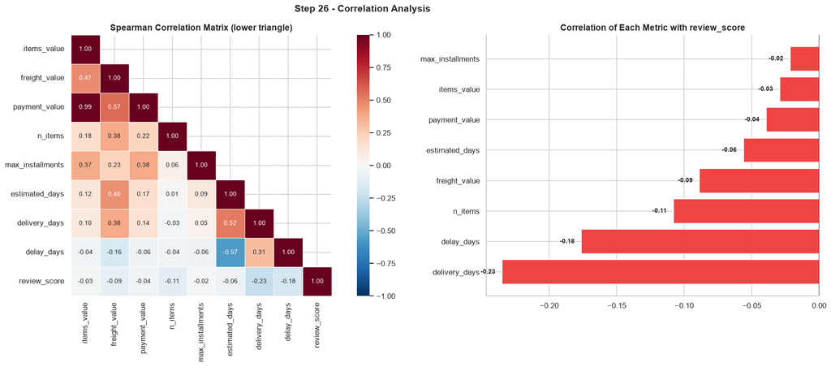

```python
num = q("""
    SELECT items_value, freight_value, payment_value, n_items, max_installments,
           estimated_days, delivery_days, delay_days, review_score
    FROM vw_order_master
    WHERE order_status = 'delivered' AND items_value IS NOT NULL AND payment_value IS NOT NULL
      AND review_score IS NOT NULL AND delivery_days IS NOT NULL
""")
corr = num.corr(method="spearman")

pairs = [(a, b, corr.loc[a, b]) for i, a in enumerate(corr.columns) for b in corr.columns[:i] if abs(corr.loc[a, b]) >= 0.5]
print("Strongly related pairs (|rho| >= 0.5):")
display(pd.DataFrame(pairs, columns=["feature_1", "feature_2", "spearman_rho"]).sort_values("spearman_rho", key=abs, ascending=False).round(3))

target_corr = corr["review_score"].drop("review_score").sort_values()
fig, axes = plt.subplots(1, 2, figsize=(19, 7.5), gridspec_kw={"width_ratios": [1.5, 1]})
mask = np.triu(np.ones_like(corr, dtype=bool), k=1)
sns.heatmap(corr, mask=mask, annot=True, fmt=".2f", cmap="RdBu_r", center=0, vmin=-1, vmax=1, linewidths=0.5, square=True, ax=axes[0], annot_kws={"size": 9})
axes[0].set_title("Spearman Correlation Matrix (lower triangle)")
axes[1].barh(target_corr.index, target_corr.values, color=[RED if v < 0 else GREEN for v in target_corr.values], edgecolor="white")
for y, v in enumerate(target_corr.values): axes[1].text(v + (0.005 if v >= 0 else -0.005), y, f"{v:.2f}", va="center", ha="left" if v >= 0 else "right", fontsize=9, fontweight="bold")
axes[1].axvline(0, color="black", lw=1); axes[1].set_title("Correlation of Each Metric with review_score")
plt.suptitle("Step 26 - Correlation Analysis", fontsize=14, fontweight="bold")
plt.tight_layout(); plt.show()
```

**📌 Observation:** Three groups stand out in the Spearman matrix. (1) **`items_value` and `payment_value` are almost identical (ρ = 0.99)** — payment is product value plus freight, so they carry the same information; `freight_value` is 0.47 with items_value and 0.57 with payment_value. (2) The **delivery block** is inter-related: `estimated_days` vs `delivery_days` 0.52, and `delay_days` vs `estimated_days` **−0.57** — mostly by construction, because delay = delivery − promise; freight also tracks distance (0.46 with `estimated_days`, 0.38 with `delivery_days`). (3) For satisfaction the right-hand chart ranks **`delivery_days` (ρ = −0.23) as the strongest correlate of `review_score`, then `delay_days` (−0.18), `n_items` (−0.11) and `freight_value` (−0.09)**; price-related fields are essentially zero (**`items_value` −0.03, `payment_value` −0.04, `max_installments` −0.02**). So price level and payment method do not make customers unhappy; slow and late delivery does, and multi-item orders are slightly worse. All correlations with review are modest because the effect is a threshold (Step 19), not linear.

**💡 Pipeline / Engineering decision:** For any linear or distance-based model **keep only one of `items_value` / `payment_value`** (ρ = 0.99), and keep both `delivery_days` and a late-flag feature, since `delivery_days` has the stronger rank correlation while `delay_days` encodes the promise. `n_items` is kept as a satisfaction feature (multi-item orders have more chances to arrive split or late). Spearman remains the default EDA correlation for skewed / ordinal fields, and a VIF check is queued for any regression. Because state (distance) confounds freight and delivery time, **no causal claims are made from correlation** — the Step 19 test and future A/B tests on delivery promises are the evidence base for action.

## Step 27 — SQL Window-Function Patterns (YoY, Top-N per Group, Running Totals)

**Why:** These are the exact query patterns that appear in every analytics / data-science SQL interview and in real BI work: **`ROW_NUMBER() OVER (PARTITION BY …)`** for Top-N per group, **self-join or `LAG`** for year-over-year growth, and **`SUM() OVER (PARTITION BY year ORDER BY month)`** for running totals. Showing them on real data proves the pipeline is production-grade SQL, not just pandas.

**Business insight:** Month-over-month growth mixes trend with seasonality; **year-over-year** removes the seasonal effect and is what boards actually ask for. Top-N per region tells local teams which categories to feature in their own market.

```
Top-3 categories in each of the 5 biggest states  (ROW_NUMBER OVER PARTITION BY):
```

|  | customer_state | rank | category | gmv | share_in_state_pct |
| --- | --- | --- | --- | --- | --- |
| 0 | MG | 1 | health_beauty | 157,433.00 | 10.00 |
| 1 | MG | 2 | bed_bath_table | 129,487.00 | 8.20 |
| 2 | MG | 3 | watches_gifts | 123,474.00 | 7.80 |
| 3 | PR | 1 | watches_gifts | 59,859.00 | 8.80 |
| 4 | PR | 2 | sports_leisure | 58,494.00 | 8.60 |
| 5 | PR | 3 | health_beauty | 54,949.00 | 8.10 |
| 6 | RJ | 1 | watches_gifts | 183,932.00 | 10.20 |
| 7 | RJ | 2 | bed_bath_table | 147,785.00 | 8.20 |
| 8 | RJ | 3 | health_beauty | 144,913.00 | 8.00 |
| 9 | RS | 1 | bed_bath_table | 60,271.00 | 8.10 |
| 10 | RS | 2 | furniture_decor | 54,814.00 | 7.40 |
| 11 | RS | 3 | sports_leisure | 53,596.00 | 7.20 |
| 12 | SP | 1 | bed_bath_table | 477,794.00 | 9.30 |
| 13 | SP | 2 | health_beauty | 460,474.00 | 8.90 |
| 14 | SP | 3 | watches_gifts | 431,119.00 | 8.30 |

```
Year-over-year growth, 2018 vs 2017  (self-join on shifted month key):
```

|  | purchase_month | gmv | gmv_prev_year | gmv_yoy_pct | orders_yoy_pct |
| --- | --- | --- | --- | --- | --- |
| 0 | 2018-01 | 945,456.00 | 120,098.00 | 687.20 | 813.20 |
| 1 | 2018-02 | 837,895.00 | 244,959.00 | 242.10 | 285.60 |
| 2 | 2018-03 | 981,051.00 | 368,341.00 | 166.30 | 173.90 |
| 3 | 2018-04 | 993,593.00 | 353,843.00 | 180.80 | 191.10 |
| 4 | 2018-05 | 992,872.00 | 503,159.00 | 97.30 | 87.70 |
| 5 | 2018-06 | 863,266.00 | 429,917.00 | 100.80 | 91.70 |
| 6 | 2018-07 | 878,044.00 | 492,287.00 | 78.40 | 58.00 |
| 7 | 2018-08 | 848,860.00 | 568,246.00 | 49.40 | 50.30 |

```
YTD GMV through 08:  2018 is 2.38x the same period of 2017
```

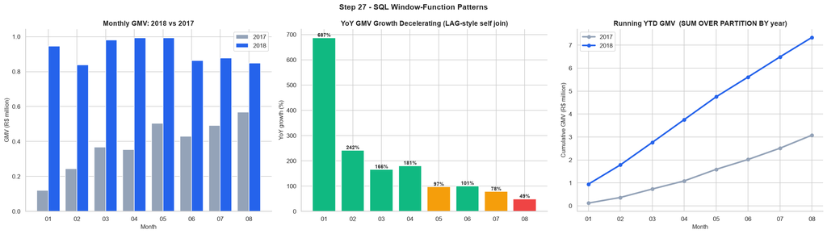

```python
top3 = q("""
    WITH s AS (
        SELECT customer_state, category, SUM(price) AS gmv
        FROM vw_item_master WHERE is_valid_order = 1 GROUP BY customer_state, category
    ),
    r AS (
        SELECT customer_state, category, gmv,
               ROW_NUMBER() OVER (PARTITION BY customer_state ORDER BY gmv DESC)              AS rn,
               ROUND(100.0 * gmv / SUM(gmv) OVER (PARTITION BY customer_state), 1)            AS share_in_state_pct
        FROM s
    )
    SELECT customer_state, rn AS rank, category, ROUND(gmv, 0) AS gmv, share_in_state_pct
    FROM r
    WHERE rn <= 3
      AND customer_state IN (SELECT customer_state FROM vw_order_master WHERE is_valid_order = 1
                             GROUP BY customer_state ORDER BY COUNT(*) DESC LIMIT 5)
    ORDER BY customer_state, rn
""")
print("Top-3 categories in each of the 5 biggest states  (ROW_NUMBER OVER PARTITION BY):")
display(top3)

yoy = q("""
    WITH m AS (
        SELECT purchase_month, SUM(items_value) AS gmv, COUNT(*) AS orders
        FROM vw_order_master WHERE is_valid_order = 1 GROUP BY purchase_month
    )
    SELECT a.purchase_month, ROUND(a.gmv, 0) AS gmv, ROUND(b.gmv, 0) AS gmv_prev_year,
           ROUND(100.0 * (a.gmv - b.gmv) / b.gmv, 1)       AS gmv_yoy_pct,
           ROUND(100.0 * (a.orders - b.orders) / b.orders, 1) AS orders_yoy_pct
    FROM m a JOIN m b ON b.purchase_month = STRFTIME('%Y-%m', DATE(a.purchase_month || '-01', '-1 year'))
    WHERE a.purchase_month BETWEEN '2018-01' AND :e
    ORDER BY a.purchase_month
""", {"e": WINDOW_END})
print("\nYear-over-year growth, 2018 vs 2017  (self-join on shifted month key):")
display(yoy)

ytd = q("""
    WITH m AS (
        SELECT purchase_month, SUBSTR(purchase_month, 1, 4) AS yr, SUBSTR(purchase_month, 6, 2) AS mm, SUM(items_value) AS gmv
        FROM vw_order_master WHERE is_valid_order = 1 AND purchase_month BETWEEN '2017-01' AND :e GROUP BY purchase_month
    )
    SELECT yr, mm, gmv, SUM(gmv) OVER (PARTITION BY yr ORDER BY mm) AS ytd_gmv
    FROM m WHERE mm <= SUBSTR(:e, 6, 2)
    ORDER BY yr, mm
""", {"e": WINDOW_END})
ytd_piv = ytd.pivot(index="mm", columns="yr", values="ytd_gmv")
ytd_ratio = ytd_piv["2018"].iloc[-1] / ytd_piv["2017"].iloc[-1]
print(f"\nYTD GMV through {WINDOW_END[5:]}:  2018 is {ytd_ratio:.2f}x the same period of 2017")

fig, axes = plt.subplots(1, 3, figsize=(21, 6))
xx = np.arange(len(yoy)); w = 0.4
axes[0].bar(xx - w / 2, yoy["gmv_prev_year"] / 1e6, w, color=GRAY, label="2017", edgecolor="white"); axes[0].bar(xx + w / 2, yoy["gmv"] / 1e6, w, color=BLUE, label="2018", edgecolor="white")
axes[0].set_xticks(xx); axes[0].set_xticklabels([m[5:] for m in yoy["purchase_month"]]); axes[0].set_xlabel("Month"); axes[0].set_ylabel("GMV (R$ million)"); axes[0].legend(); axes[0].set_title("Monthly GMV: 2018 vs 2017")

axes[1].bar(xx, yoy["gmv_yoy_pct"], color=[GREEN if v > 100 else ORANGE if v > 50 else RED for v in yoy["gmv_yoy_pct"]], edgecolor="white")
for i, v in enumerate(yoy["gmv_yoy_pct"]): axes[1].text(i, v, f"{v:,.0f}%", ha="center", va="bottom", fontsize=9, fontweight="bold")
axes[1].set_xticks(xx); axes[1].set_xticklabels([m[5:] for m in yoy["purchase_month"]]); axes[1].set_ylabel("YoY growth (%)"); axes[1].set_title("YoY GMV Growth Decelerating (LAG-style self join)")

for yr, c in [("2017", GRAY), ("2018", BLUE)]:
    axes[2].plot(ytd_piv.index, ytd_piv[yr] / 1e6, color=c, lw=2.8, marker="o", label=yr)
axes[2].set_xlabel("Month"); axes[2].set_ylabel("Cumulative GMV (R$ million)"); axes[2].legend(); axes[2].set_title("Running YTD GMV  (SUM OVER PARTITION BY year)")
plt.suptitle("Step 27 - SQL Window-Function Patterns", fontsize=14, fontweight="bold")
plt.tight_layout(); plt.show()
```

**📌 Observation:** The **Top-3-per-state** query shows the *same head categories* in every big state: `health_beauty`, `bed_bath_table` and `watches_gifts` appear in the top 3 of SP, RJ and MG, with `sports_leisure` (PR, RS) and `furniture_decor` (RS) entering only the southern states. Each category holds a narrow **7-10 % of state GMV** (SP: bed_bath_table 9.3 %, health_beauty 8.9 %, watches_gifts 8.3 %), so demand is broad and **assortment is nationally uniform** rather than state-specific. The **YoY chart tells the growth story more honestly than MoM**: 2018 vs 2017 GMV growth is **+687 % in Jan** (off a R$ 0.12 M base), +242 % in Feb, +166 % / +181 % in Mar / Apr, **+97 % / +101 % in May / Jun, +78 % in Jul and +49 % in Aug** — a steady deceleration. The monthly-GMV bars show why: 2017 keeps climbing while 2018 is flat near R$ 0.85-0.99 M. Running YTD GMV ends **August-2018 at ≈ R$ 7.3 M vs ≈ R$ 3.1 M for 2017 (2.38×)**, and the gap between the two lines is widening more slowly each month.

**💡 Pipeline / Engineering decision:** Window functions (`ROW_NUMBER`, self-joined LAG-style keys, `SUM() OVER (PARTITION BY …)`, `NTILE`) replace multi-step pandas loops, so **the logic stays in SQL and is portable to BigQuery / Redshift / Snowflake**. Board-level growth is reported as **YoY plus 3-month average (seasonality-neutral)**, with MoM kept for operational monitoring only; YoY is quoted with the base-effect caveat, since 687 % in Jan-2018 says more about a tiny Jan-2017 base than about performance. Because state-level assortments are almost identical, **one national assortment and forecast** is used, with state-level effort going into logistics (Step 16) rather than category mix. The month-shifted key (`DATE(month || '-01', '-1 year')`) is used instead of `LAG(..., 12)` because it stays correct even if a month is missing.

## Step 28 — Export Analytics Marts

**Why:** EDA is only valuable if its results are reusable. This step materialises the certified layers into **analytics marts** (order, customer, seller, category, monthly KPI) — flat tables that a BI tool (Power BI / Tableau / Looker) or an ML pipeline can read directly, both as CSV and as tables inside the SQLite warehouse.

**Business insight:** Separating *raw → certified views → marts* is the same layering used in dbt-based warehouses (staging → intermediate → marts). It keeps dashboards fast, definitions consistent and lets data scientists start modelling from clean, feature-rich tables.

|  | mart | rows | columns | csv_kb |
| --- | --- | --- | --- | --- |
| 0 | mart_orders | 99441 | 39 | 36,881.40 |
| 1 | mart_customers | 94989 | 7 | 6,136.23 |
| 2 | mart_sellers | 3053 | 13 | 433.11 |
| 3 | mart_category | 74 | 11 | 6.31 |
| 4 | mart_monthly_kpi | 20 | 12 | 2.45 |
| 5 | kpi_scoreboard | 8 | 3 | 0.39 |

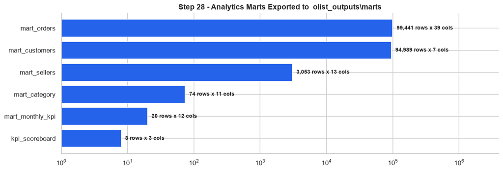

```python
MART_DIR = OUTPUT_DIR / "marts"; MART_DIR.mkdir(exist_ok=True)

mart_orders = q("""
    SELECT m.*,
           CAST(STRFTIME('%w', purchase_ts) AS INTEGER)                          AS dow,
           CAST(STRFTIME('%H', purchase_ts) AS INTEGER)                          AS hour,
           CASE WHEN STRFTIME('%w', purchase_ts) IN ('0','6') THEN 1 ELSE 0 END  AS is_weekend,
           CASE WHEN CAST(STRFTIME('%H', purchase_ts) AS INTEGER) < 6  THEN 'night'
                WHEN CAST(STRFTIME('%H', purchase_ts) AS INTEGER) < 12 THEN 'morning'
                WHEN CAST(STRFTIME('%H', purchase_ts) AS INTEGER) < 18 THEN 'afternoon' ELSE 'evening' END AS day_part,
           CASE WHEN purchase_month = '2017-11' THEN 1 ELSE 0 END                AS is_event_month,
           freight_value * 1.0 / NULLIF(items_value, 0)                          AS freight_ratio,
           CASE WHEN freight_value * 1.0 / NULLIF(items_value, 0) > 0.5 THEN 1 ELSE 0 END AS freight_heavy,
           ROUND(JULIANDAY(order_delivered_carrier_date)  - JULIANDAY(order_approved_at), 2)            AS seller_handling_days,
           ROUND(JULIANDAY(order_delivered_customer_date) - JULIANDAY(order_delivered_carrier_date), 2) AS transit_days
    FROM vw_order_master m
""")
mart_orders["region"] = mart_orders["customer_state"].map(REGION)

mart_customers = rfm.copy()
mart_sellers   = s.merge(sq[["seller_id", "status"]], on="seller_id", how="left").fillna({"status": f"Not scored (<{MIN_ORDERS} orders)"})
mart_category  = cat.merge(cq[["category", "avg_review", "late_pct", "risk_flag"]], on="category", how="left")
mart_monthly   = monthly.merge(csat[["purchase_month", "avg_review", "neg_pct", "late_pct"]], on="purchase_month", how="left")
kpi_df = pd.DataFrame([(t, v, sub) for t, v, sub, _ in cards], columns=["kpi", "value", "note"])

marts = {"mart_orders": mart_orders, "mart_customers": mart_customers, "mart_sellers": mart_sellers,
         "mart_category": mart_category, "mart_monthly_kpi": mart_monthly, "kpi_scoreboard": kpi_df}
summary_rows = []
for name, d in marts.items():
    d.to_csv(MART_DIR / f"{name}.csv", index=False)
    d.to_sql(name, conn, index=False, if_exists="replace")
    summary_rows.append({"mart": name, "rows": len(d), "columns": d.shape[1], "csv_kb": (MART_DIR / f"{name}.csv").stat().st_size / 1024})
conn.commit()
export_df = pd.DataFrame(summary_rows)
display(export_df)

fig, ax = plt.subplots(figsize=(12, 4.2))
e = export_df.iloc[::-1]
ax.barh(e["mart"], e["rows"], color=BLUE, edgecolor="white"); ax.set_xscale("log")
for y, (r, c) in enumerate(zip(e["rows"], e["columns"])): ax.text(r * 1.15, y, f"{r:,} rows x {c} cols", va="center", fontsize=9, fontweight="bold")
ax.set_xlim(1, e["rows"].max() * 40); ax.set_title(f"Step 28 - Analytics Marts Exported to  {MART_DIR}")
plt.tight_layout(); plt.show()
```

**📌 Observation:** Six deliverables are produced and shown in the log-scale bar chart: **`mart_orders` (99,441 rows × 39 columns, ~36.9 MB CSV)**, **`mart_customers` (94,989 × 7)**, **`mart_sellers` (3,053 × 13)**, **`mart_category` (74 × 11)**, **`mart_monthly_kpi` (20 × 12)** and **`kpi_scoreboard` (8 × 3)**. Only `mart_orders` is large; the others are small, ready-to-plot summaries (from 0.4 KB to ~6 MB). Each mart is saved both as a CSV (for BI tools) and as a table inside `olist_analytics.db` (for further SQL). `mart_orders` has the same 99,441 rows as `orders`, confirming grain was preserved end to end, and `mart_customers` has 94,989 customers with a valid, paid order (vs 96,096 unique persons overall, because cancelled / unpaid buyers are excluded).

**💡 Pipeline / Engineering decision:** The project follows a **three-layer architecture — raw tables → certified views (`vw_order_master`, `vw_item_master`) → marts** — mirroring a dbt staging / marts layout. Every mart carries the definitions fixed in this notebook (`is_valid_order`, `is_late`, `customer_unique_id`, `tier`, `status`, `segment`, `risk_flag`, `is_event_month`), so a dashboard built on them reconciles to the KPI scoreboard in Step 9. In production, the view and mart queries would be scheduled (Airflow / dbt) with the **Step 6 data-quality checks running first as a gate**, and the mart grain (rows = orders, sellers, categories, months) checked after each run.

## Step 29 — Key Insights and Decision Map

**Why:** An EDA is only useful if its findings are converted into decisions. This closing step collects the headline numbers in one box and links each finding to the specific pipeline, engineering or business decision it triggered, so nothing learned in Steps 1-28 stays as a chart that nobody acts on.

**Business insight:** The picture in one paragraph — a **R$ 13.5 M GMV marketplace that grew ~8× during 2017 and has plateaued since Jan-2018 at ~6.7 k orders a month**. Revenue is concentrated (18 of 74 categories = 80 % of GMV, seller Gini 0.79, top-3 states = 67 % of orders), delivery is the only lever that visibly moves satisfaction (late orders 2.27★ vs 4.29★), and **97 % of customers never return**. Growth from here depends on delivery reliability and on converting first-time buyers into second-time buyers, not on adding more traffic alone.

```python
top3_states = geo.orders_share.head(3).sum()
box = f"""
╔═══════════════════════════════════════════════════════════════════════════════════════════════════════════════════════╗
║        E-COMMERCE BI & SQL ANALYTICS  -  KEY INSIGHTS FROM EDA                                                        ║
╠═══════════════════════════════════════════════════════════════════════════════════════════════════════════════════════╣
║  1. SCALE          R$ {kpi.gmv/1e6:5.1f}M GMV · {int(kpi.valid_orders):,} valid orders · AOV R$ {kpi.aov_items:,.0f}                                                   ║
║  2. GROWTH         2017 = ramp-up, Black Friday spike; 2018 = plateau (~{h1.orders.mean():,.0f} orders/month)                           ║
║  3. CONCENTRATION  {n80} of {n_cat} categories = 80% GMV · top-3 states = {top3_states:.0f}% of orders                                       ║
║                    Seller Gini {gini:.2f} · top 20% of sellers = {top_share[20]:.0f}% of GMV                                                 ║
║  4. DELIVERY       {kpi.late_pct:.1f}% late (vs a padded promise) · transit = biggest stage of lead time                             ║
║  5. CSAT DRIVER    late orders avg {late.mean():.2f}★ vs on-time {ontime.mean():.2f}★  (Cohen's d = {cohen_d:.2f})                                       ║
║                    monthly late% vs review  r = {r_month:.2f}                                                                 ║
║  6. RETENTION      only {repeat:.1f}% repeat customers · monthly cohort retention < 1%                                         ║
║  7. GEOGRAPHY      ~{geo.seller_share.max():.0f}% of sellers in one state -> freight/latency penalty for N/NE regions                           ║
╚═══════════════════════════════════════════════════════════════════════════════════════════════════════════════════════╝
"""
print(box)
```

```
╔═══════════════════════════════════════════════════════════════════════════════════════════════════════════════════════╗
║        E-COMMERCE BI & SQL ANALYTICS  -  KEY INSIGHTS FROM EDA                                                        ║
╠═══════════════════════════════════════════════════════════════════════════════════════════════════════════════════════╣
║  1. SCALE          R$  13.5M GMV · 98,207 valid orders · AOV R$ 137                                                   ║
║  2. GROWTH         2017 = ramp-up, Black Friday spike; 2018 = plateau (~6,691 orders/month)                           ║
║  3. CONCENTRATION  18 of 74 categories = 80% GMV · top-3 states = 67% of orders                                       ║
║                    Seller Gini 0.79 · top 20% of sellers = 83% of GMV                                                 ║
║  4. DELIVERY       6.8% late (vs a padded promise) · transit = biggest stage of lead time                             ║
║  5. CSAT DRIVER    late orders avg 2.27★ vs on-time 4.29★  (Cohen's d = -1.47)                                       ║
║                    monthly late% vs review  r = -0.92                                                                 ║
║  6. RETENTION      only 3.0% repeat customers · monthly cohort retention < 1%                                         ║
║  7. GEOGRAPHY      ~60% of sellers in one state -> freight/latency penalty for N/NE regions                           ║
╚═══════════════════════════════════════════════════════════════════════════════════════════════════════════════════════╝
```

**📌 Observation:** The summary box above reproduces the seven headline findings from the executed notebook: scale (R$ 13.5 M GMV, 98,207 valid orders, AOV R$ 137), the 2018 plateau (~ 6,691 orders / month), concentration (18 of 74 categories, seller Gini 0.79, top-3 states 67 %), delivery (6.8 % late, transit the largest stage), the CSAT driver (2.27★ vs 4.29★, Cohen's d −1.47, monthly r = −0.92), retention (3.0 % repeat) and geography (~ 60 % of sellers in one state). Three of these — the plateau, the late-delivery effect and the retention gap — are the ones that change what the business should do next.

**💡 Pipeline / Engineering decision:** Every finding is mapped below to a concrete decision (view, mart column, rule, model target or business action), and the three priorities — **fix late delivery, reduce the second-purchase gap, and manage seller and category concentration** — define the next phase.

### 📋 EDA-to-Decision Map

| # | EDA Finding (with evidence) | Pipeline / Engineering / Business Decision |
| --- | --- | --- |
| 1 | **Naive 3-way join inflates revenue: +4.5 % on product value, +26.9 % on payments** (Step 8) | Pre-aggregate child tables to order grain; certified `vw_order_master` + `vw_item_master`; `assert` grain and reconciliation tests |
| 2 | **Delivery-date nulls are structural** (100 % null for shipped / unavailable / invoiced; 2,965 rows) (Step 5) | No imputation; delivery KPIs on `delivered` only; `COALESCE(category, 'unknown')` for the 610 uncategorised products |
| 3 | **Duplicates: 26.2 % of geolocation rows, 547 orders with > 1 review** (Step 6) | Collapse reviews to 1 row per order; de-duplicate geolocation to a zip centroid; keep `DQ_CHECKS` as a data-contract gate |
| 4 | **Only 2017-01 → 2018-08 is a complete window; `shipping_limit_date` reaches 2020** (Step 4) | Parameterised `WINDOW_START/END`; partial months excluded from trend / cohort work; `shipping_limit_date` not used |
| 5 | **Black Friday (Nov-2017) peaked at R 1.00 M but Apr-May 2018 are within ~1 %; 2018 plateaus (CV 6 %) and slips ~13 % after May** (Steps 10, 27) | `is_event_month` flag; forecast from the 2018 level; report YoY + 3-month average, not MoM, at board level |
| 6 | **Demand: Mon 15.9 k vs Sat 10.7 k orders; plateau 10:00-22:00, peak 16:00, trough 03:00-05:00** (Step 11) | Campaigns and staffing on weekday daytime (+ Sunday evening); `dow`, `hour`, `is_weekend`, `day_part` in mart; batch jobs at 03:00-05:00 |
| 7 | **18 of 74 categories (24 %) = 80 % of GMV; 8 big categories (37.8 % of GMV) rate below 4.04, with normal late rates** (Steps 12-13) | Focus forecasting on the 18 head categories; `risk_flag` watch-list routed to product-quality review, not logistics; `office_furniture` (3.49★) first |
| 8 | **Price skew 7.95 (→ 0.24 after log10); 3.7 % of items have freight > price** (Step 14) | Median / P90 reporting; log10 for modelling; keep outliers; `freight_ratio` + `freight_heavy` features |
| 9 | **Credit card = 75.5 % of orders; ticket rises from ~R$ 95 (1×) to ~R$ 210 (6×)** (Step 15) | `main_payment_type` + `max_installments` in master view; bucket instalments (1×, 2-5×, 6×+); GMV from `items_value`, cash from `payment_value` |
| 10 | **SP = 41.9 % of orders / 59.7 % of sellers; RJ has 12.9 % of demand, 5.6 % of sellers, 12.1 % late; Northeast freight R$ 35.9 vs Southeast R$ 19.9** (Step 16) | State / region grain; RJ hub or seller-recruitment first; freight-subsidy test for N / NE |
| 11 | **Promise padded (median 23 vs 10 days) yet 6.8 % late; spikes 12 % (Nov-17), 14 % (Feb-18), 19 % (Mar-18); transit = 74 % of lead time** (Steps 17-18) | SLA = on-time % + P90 days; separate seller-dispatch and carrier SLAs; alert at ≥ 1.5× overall rate; `is_late` = target for late-delivery model |
| 12 | **Late orders 2.27★ vs on-time 4.29★ (Cohen's d −1.47); 54 % of late orders give 1★; monthly r = −0.92** (Steps 19-20) | Proactive delay comms; voucher for delays > 3 days; report 1★-rate on late orders; monthly late % as leading CSAT indicator; late-bucket feature |
| 13 | **Handling > 8 days → 24.8 % late vs 3.9 % for ≤ 1 day** (Step 18) | Seller dispatch SLA ≤ 2 days; `seller_handling_days` in mart and in the seller score |
| 14 | **Seller Gini 0.79; top 1 % = 26.2 % of GMV; quality flat across tiers (4.06 / 4.07 / 4.00)** (Step 21) | A/B/C tiering: key-account mgmt for A, automation for B, self-serve gates for C; monitor top-1 % GMV share |
| 15 | **23 At-risk + 102 Watch sellers (14.5 % of scored GMV); one top-10 seller is Watch** (Step 22) | Seller scorecard with 30-order filter; intervene on At-risk ∩ Tier A/B first; empirical-Bayes next |
| 16 | **`customer_id` is per order (99,441 vs 96,096 people); 3.04 % repeat, 29.8 % of repeats within 1 day; retention ≈ 0.2-0.5 %/month** (Steps 23-24) | Use `customer_unique_id` everywhere; merge split baskets; replace churn model with **second-purchase propensity**; LTV ≈ first-order margin |
| 17 | **F is degenerate (97 % = 1); At-risk big spenders + New high-value = ~56 % of revenue** (Step 25) | Rule-based F + `NTILE` R/M; per-segment plan (win-back, 30-day nudge, loyalty, low-cost re-engagement) |
| 18 | **`items_value` ≈ `payment_value` (ρ = 0.99); review correlates most with `delivery_days` (−0.23) and not with price** (Step 26) | Drop one redundant value feature; keep `delivery_days` + late flag; Spearman for skewed fields; no causal claims from correlation |
| 19 | **YoY growth decays from +687 % (Jan) to +49 % (Aug 2018); assortment near-uniform across states** (Step 27) | Window-function SQL (BigQuery / Redshift / Snowflake-ready); YoY with base-effect caveat; one national assortment |
| 20 | **Logic must be portable and reusable** (Step 28) | raw → views → marts layering; export CSV + SQL tables; DQ checks as a gate |

### 🚀 Recommended Next Phase

1. **Dashboards** — build the KPI scoreboard, delivery-SLA and seller-scorecard pages in Power BI / Tableau directly on the marts.
2. **Late-delivery prediction model** — target `is_late`; features: state, seller handling history, category / size, freight ratio, month, event flag (Nov-2017, Feb-Mar 2018 peaks).
3. **Second-purchase propensity model** — target: repeat within 90 days (excluding same-day split baskets); features from the first order (delay, review, category, payment).
4. **Seller risk scoring** — empirical-Bayes shrinkage on review / late-rate + handling-time SLA.
5. **NLP on 1-2★ Portuguese comments** — 77 % of 1★ reviews carry text; explain the low-rated big categories (`office_furniture`, `bed_bath_table`, `furniture_decor`).

*This EDA notebook defines every metric, filter and layer used downstream: each insight above maps to a specific view, mart column or business rule, so dashboards and models built on the exported marts stay reconcilable to the numbers shown here.*